# REFMAP Listening test 1 Part A analysis: Random forest variable importance identification (median responses)

This notebook analyses the Part A data in terms of variable importance using a random forest model based on conditional inference trees and a conditional permutation variable importance algorithm.

# Setup

## Load packages

```r
# load packages
library(tidyr)
library(ggplot2)
library(party)
library(conflicted)
library(tidyverse)
library(openxlsx)
library(caret)
library(viridis)
library(cowplot)
# set package parameters
theme_set(theme_bw())
```

```r
# plot colour scheme

mycolourlist = list(c(0, 102, 255), c(0, 204, 153), c(255, 0, 102), c(74, 111, 152), c(251, 164, 49), c(204, 153, 255), c(90, 192, 255), c(80, 245, 233), c(255, 90, 192), c(164, 201, 242), c(255, 254, 139), c(255, 243, 255))
mycolours = matrix()

for (ii in 1:length(mycolourlist)){
  mycolours[ii] = rgb(mycolourlist[[ii]][1]/255,
                      mycolourlist[[ii]][2]/255,
                      mycolourlist[[ii]][3]/255)
}

# toggle to save plots
saveplots = TRUE

if (saveplots){
  # set output plot directory
  choose.files(caption="Just cancel this", filters=matrix(data=c(" ", " "), ncol=2))  # workaround for bug in RTerm choose.dir
  outFigPath <- utils::choose.dir(caption="Select output folder to save plots '03 Experiment\\Experiment 1\\Analysis\\Plots'")

  if (!dir.exists(file.path(outFigPath, "svg"))){dir.create(file.path(outFigPath, "svg"))}
  if (!dir.exists(file.path(outFigPath, "pdf"))){dir.create(file.path(outFigPath, "pdf"))}

}

# toggle to save data
savedata = TRUE

if (savedata){
  # set output plot directory
  if (saveplots==FALSE){
    choose.files(caption="Just cancel this", filters=matrix(data=c(" ", " "), ncol=2))  # workaround for bug in RTerm choose.dir
  }
  outDataPath <- utils::choose.dir(caption="Select output folder to save data '03 Experiment\\Experiment 1\\Analysis\\R'")
}
```

# Import data and wrangle

## Part A

```r
stimDataApath <- utils::choose.files(caption=r"(Select refmap_listest1_testdataA_ByStim.csv from 03 Experiment\Experiment 1\Analysis\PostProcess)",
                                     filters=matrix(data=c("refmap_listest1_testdataA_ByStim.csv", "refmap_listest1_testdataA_ByStim.csv"), ncol=2))

stimNoticeDataApath <- utils::choose.files(caption=r"(Select refmap_listest1_testdataANoticeFilt_ByStim.csv from 03 Experiment\Experiment 1\Analysis\PostProcess)", filters=matrix(data=c("refmap_listest1_testdataANoticeFilt_ByStim.csv", "refmap_listest1_testdataANoticeFilt_ByStim.csv"), ncol=2))

stimDataA <- utils::read.csv(stimDataApath, header=TRUE)
stimNoticeDataA <- utils::read.csv(stimNoticeDataApath, header=TRUE)

colnames(stimDataA)[1] <- "Stimulus"
colnames(stimNoticeDataA)[1] <- "Stimulus"

# make response proportions into percentages
stimDataA[['HighAnnoyPc']] <- stimDataA[['HighAnnoyProp']]*100
stimDataA[['dHighAnnoyPc']] <- stimDataA[['dHighAnnoyProp']]*100

# make response proportions into percentages
stimNoticeDataA[['HighAnnoyPcFilt']] <- stimNoticeDataA[['HighAnnoyPropFilt']]*100
stimNoticeDataA[['dHighAnnoyPcFilt']] <- stimNoticeDataA[['dHighAnnoyPropFilt']]*100
stimNoticeDataA[['NoticedPcFilt']] <- stimNoticeDataA[['NoticedPropFilt']]*100
```

```r
# function to encode categorical to ordinal numeric variables
encode_ordinal <- function(x, order=unique(x)) {
  x <- as.numeric(factor(x, levels=order, exclude=NULL, order=TRUE))
  x
}

# definition of ordinal variable levels
SNRCatsA <- c("No UAS", "-16", "-10", "-4", "2", "8")
UASLAeqCatsA <- c("No UAS", "42", "48", "54", "60")
```

The aggregated data by stimulus are assigned to a dataframe, relevant categorical variables are converted to ordinal, and then the variable subset of interest is selected, NA rows dropped (ie, the ‘no UAS’ stimuli, as the conditional variable importance algorithm cannot currently handle NA values, which are present in all the UAS dB metrics), and a formula assigned.

```r
stimDataANum <- data.frame()

stimDataANum <- cbind(stimDataA[, 'Stimulus'],
                      stimDataA[, which(colnames(stimDataA)=="UASLAeq"):
                                  which(colnames(stimDataA)=="SNRlevel")],
                      stimDataA[, "IntermitRatioMaxLR", drop=F],
                      stimDataA[, which(colnames(stimDataA)=="UASLAeqMaxLR"):
                                  which(colnames(stimDataA)=="UASImpulsSHM05ExMaxLR")],
                      stimDataA[, which(colnames(stimDataA)=="LAeqLAF90diff"):
                                  which(colnames(stimDataA)=="dImpulsSHM05ExMaxLR")],
                      stimDataA[, which(colnames(stimDataA)=="ValenceMedian"):
                                  which(colnames(stimDataA)=="dHighAnnoyProp")],
                      stimDataA[, which(colnames(stimDataA)=="HighAnnoyPc"):
                                  which(colnames(stimDataA)=="dHighAnnoyPc")])

# remove duplicated variables
stimDataANum <- subset(stimDataANum, select = -c(UASLAeq))

colnames(stimDataANum)[1] <- "Stimulus"

# make the categorical outcome variables numerical dummy factors
# stimDataANum[['SNRlevel']] <- encode_ordinal(stimDataA[['SNRlevel']], order=SNRCatsA)
# stimDataANum[['UASLAeq']] <- encode_ordinal(stimDataA[['UASLAeq']], order=UASLAeqCatsA)

# make the discrete ordinal outcome variables factors
stimDataANum[['ValenceMedian']] <- factor(stimDataANum[['ValenceMedian']], levels=c(1, 2, 3, 4, 5), order=TRUE)
stimDataANum[['ArousalMedian']] <- factor(stimDataANum[['ArousalMedian']], levels=c(1, 2, 3, 4, 5), order=TRUE)
stimDataANum[['AnnoyMedian']] <- factor(stimDataANum[['AnnoyMedian']], levels=c(0, 1, 2, 3, 4, 5, 6, 7, 8, 9, 10), order=TRUE)
stimDataANum[['dValenceMedian']] <- factor(stimDataANum[['dValenceMedian']], levels=c(-4, -3, -2, -1, 0, 1, 2, 3, 4), order=TRUE)
stimDataANum[['dArousalMedian']] <- factor(stimDataANum[['dArousalMedian']], levels=c(-4, -3, -2, -1, 0, 1, 2, 3, 4), order=TRUE)
stimDataANum[['dAnnoyMedian']] <- factor(stimDataANum[['dAnnoyMedian']], levels=c(-10, -9, -8, -7, -6, -5, -4, -3, -2, -1,
                                                                                 0, 1, 2, 3, 4, 5, 6, 7, 8, 9, 10), order=TRUE)

# omit ambient-only stimuli
stimDataANum <- stimDataANum |> dplyr::filter(SNRlevel != "No UAS")

stimDataANum$SNRlevel <- as.numeric(stimDataANum$SNRlevel)
```

```r
stimNoticeDataANum <- data.frame()

stimNoticeDataANum <- cbind(stimNoticeDataA[, 'Stimulus'],
                            stimNoticeDataA[, which(colnames(stimNoticeDataA)=="UASLAeq"):
                                              which(colnames(stimNoticeDataA)=="SNRlevel")],
                            stimNoticeDataA[, "IntermitRatioMaxLR", drop=F],
                            stimNoticeDataA[, which(colnames(stimNoticeDataA)=="UASLAeqMaxLR"):
                                              which(colnames(stimNoticeDataA)=="UASImpulsSHM05ExMaxLR")],
                            stimNoticeDataA[, which(colnames(stimNoticeDataA)=="LAeqLAF90diff"):
                                              which(colnames(stimNoticeDataA)=="dImpulsSHM05ExMaxLR")],
                            stimNoticeDataA[, which(colnames(stimNoticeDataA)=="NoticedTotalFilt"):
                                              which(colnames(stimNoticeDataA)=="NoticedPcFilt")])

stimNoticeDataANum <- subset(stimNoticeDataANum, select = -c(UASLAeq))

colnames(stimNoticeDataANum)[1] <- "Stimulus"

# omit ambient-only stimuli
stimNoticeDataANum <- stimNoticeDataANum |> dplyr::filter(SNRlevel != "No UAS")

stimNoticeDataANum$SNRlevel <- as.numeric(stimNoticeDataANum$SNRlevel)
```

# Random forest functions

## Averaging over multiple random seeds

```r
multi_crfReg <- function(dataIn, iVars, dVar, seeds, ntree, mtry, permImpCondThres=0.95, minsplit=20, minbucket=7, nperm=1){
  # initialise variables
  crfOOBErrAll <- 0
  crfOOBRMSE <- 0
  crfOOBMAE <- 0
  crfOOBErrR2 <- 0
  crfMarPermImpVals <- 0
  crfConPermImpVals <- 0
  crfMarPermImpValsPerTree <- data.frame()
  crfConPermImpValsPerTree <- data.frame()

  for (iters in 1:length(seeds)){

    # formula for regression
    formVars <- reformulate(iVars, dVar)

    # set random seed
    set.seed(seeds[iters])
    # train crf model
    crfModel <- party::cforest(formVars, data=dataIn,
                               controls=party::cforest_unbiased(ntree=ntree,
                                                                mtry=mtry,
                                                                minsplit=minsplit,
                                                                minbucket=minbucket))

    # get OOB predictions
    crfModelOOB <- predict(crfModel, OOB=TRUE, type='response')

    # get OOB error
    crfModelOOBErr <- as.numeric(as.matrix(as.numeric(as.matrix(crfModelOOB))
                                            - as.numeric(as.matrix(crfModel@data@env$response[[names(crfModel@data@env$response)]]))))

    # OOB RMSE, error quartiles and Rsquared
    crfOOBRMSE <- crfOOBRMSE + sqrt(mean(crfModelOOBErr^2))
    crfOOBMAE <- crfOOBMAE + mean(abs(crfModelOOBErr))
    crfOOBErrR2 <- crfOOBErrR2 + cor(as.numeric(as.matrix(crfModelOOB)),
                                     as.numeric(as.matrix(crfModel@data@env$response[[names(crfModel@data@env$response)]])))^2

    # set random seed
    set.seed(seeds[iters])

    # set random seed
    set.seed(seeds[iters])
    # conditional variable permutation importance
    crfConPermImp <- permimp::permimp(crfModel, nperm=nperm, conditional=TRUE, threshold=permImpCondThres, progressBar=FALSE)

    crfConPermImpVals <- crfConPermImpVals + crfConPermImp$values
    crfConPermImpValsPerTree <- rbind(crfConPermImpValsPerTree, crfConPermImp$perTree)
  }

  # average metrics
  crfOOBErrAll <- crfOOBErrAll/length(seeds)
  crfOOBRMSE <- crfOOBRMSE/length(seeds)
  crfOOBMAE <- crfOOBMAE/length(seeds)
  crfOOBErrR2 <- crfOOBErrR2/length(seeds)
  crfConPermImpVals <- data.frame(CondPermImp=sort(crfConPermImpVals/length(seeds), decreasing=TRUE))
  #crfConPermImpValsMn <- sort(colMeans(crfConPermImpValsPerTree), decreasing=TRUE)  # mean of conditional variable importance values per tree (same as crfConPermImpVals)
  crfConPermImpValsQtl <- data.frame(apply(crfConPermImpValsPerTree, 2, quantile, probs=c(0.25, 0.50, 0.75)))

  resultsOut <- list('OOB_RMSE'=crfOOBRMSE, 'OOB_MAE'=crfOOBMAE, 'Rsquared'=crfOOBErrR2, 'conditional_permimp'=crfConPermImpVals,                      'conditional_permimp_perTree'=crfConPermImpValsPerTree, 'conditional_permimp_qtl'=crfConPermImpValsQtl)
  return(resultsOut)
}
```

## Comparing rankings from two seeds

```r
crfReg <- function(dataIn, iVars, dVar, seeds, ntree, mtry, permImpCondThres=0.95, minsplit=20, minbucket=7, nperm=1){
  # initialise variables
  crfOOBErrAll <- 0
  crfOOBRMSE <- 0
  crfOOBMAE <- 0
  crfOOBErrR2 <- 0
  crfMarPermImpVals <- 0
  crfConPermImpVals <- 0
  crfMarPermImpValsPerTree <- data.frame()
  crfConPermImpValsPerTree <- data.frame()

  # formula for regression
  formVars <- reformulate(iVars, dVar)

  for (iters in 1:length(seeds)){

    # set random seed
    set.seed(seeds[iters])
    # train crf model
    crfModel <- party::cforest(formVars, data=dataIn,
                               controls=party::cforest_unbiased(ntree=ntree,
                                                                mtry=mtry,
                                                                minsplit=minsplit,
                                                                minbucket=minbucket))

    # conditional variable permutation importance
    crfConPermImp <- permimp::permimp(crfModel, nperm=nperm, conditional=TRUE, threshold=permImpCondThres, progressBar=FALSE)

    crfConPermImpVals <- crfConPermImp$values

    if (iters == 1){
      crfConPermImpVals1 <- data.frame(CondPermImp=sort(crfConPermImpVals, decreasing=TRUE))
      crfConPermImpValsPerTree1 <- crfConPermImp$perTree
      crfConPermImpValsQtl1 <- data.frame(apply(crfConPermImpValsPerTree1, 2, quantile, probs=c(0.25, 0.50, 0.75)))

      # get OOB predictions
      crfModelOOB <- predict(crfModel, OOB=TRUE, type='response')

      # get OOB error
      crfModelOOBErr <- as.numeric(as.matrix(as.numeric(as.matrix(crfModelOOB))
                                              - as.numeric(as.matrix(crfModel@data@env$response[[names(crfModel@data@env$response)]]))))

      # OOB RMSE, error quartiles and Rsquared
      crfOOBRMSE <- sqrt(mean(crfModelOOBErr^2))
      crfOOBMAE <- crfOOBMAE + mean(abs(crfModelOOBErr))
      crfOOBErrR2 <- cor(as.numeric(as.matrix(crfModelOOB)),
                                    as.numeric(as.matrix(crfModel@data@env$response[[names(crfModel@data@env$response)]])))^2

      }

    else{
      crfConPermImpValsN <- data.frame(CondPermImp=sort(crfConPermImpVals, decreasing=TRUE))

      nVarImpChecks <- min(max(sum(crfConPermImpVals1 >= crfConPermImpVals1$CondPermImp[1]*0.1),
                               sum(crfConPermImpValsN >= crfConPermImpValsN$CondPermImp[1]*0.1)), 4)  # number of variable importance values with a value at least 10% of the highest importance
      if (sum(rownames(crfConPermImpVals1)[1:nVarImpChecks] != rownames(crfConPermImpValsN)[1:nVarImpChecks]) > 0){
        warning("Permutation importance rank order within 10% of max differs between seeds: increase number of trees ('ntree') or number of permutations ('nperm'), or subsample of features ('mtry')")
      }
      else{
        resultsOut <- list('OOB_errors'=crfModelOOBErr, 'OOB_RMSE'=crfOOBRMSE, 'OOB_MAE'=crfOOBMAE, 'Rsquared'=crfOOBErrR2, 'conditional_permimp'=crfConPermImpVals1, 'conditional_permimp_perTree'=crfConPermImpValsPerTree1, 'conditional_permpimp_qtl'=crfConPermImpValsQtl1)
        return(resultsOut)
      }

    }

  }

}
```

## Hyperparameter tuning

```r
mtryTune <- function(dataIn, iVars, dVar, seeds, ntrees, minsplit=20, minbucket=7){

  formVars <- reformulate(iVars, dVar)

  # set mtry values and corresponding iVars/mtry ratios
  iVars_mtrys <- c(10.5, 5.25, 3.5, 2.75, 2.25, 1.75, 1.5, 1.25)
  mtrys <- as.integer(length(iVars)/iVars_mtrys)
  iVars_mtrys <- iVars_mtrys[mtrys >= 2]  # remove 0 or 1 values
  mtrys <- mtrys[mtrys >= 2]  # remove 0 or 1 values

  # remove any duplicated values
  iVars_mtrys <- iVars_mtrys[!(duplicated(mtrys) | duplicated(mtrys, fromLast = TRUE))]
  mtrys <- mtrys[!(duplicated(mtrys) | duplicated(mtrys, fromLast = TRUE))]

  # ensure mtrys is less than length(iVars)
  iVars_mtrys <- iVars_mtrys[mtrys < length(iVars)]
  mtrys <- mtrys[mtrys < length(iVars)]

  resRMSEMap = matrix(data=0, nrow=length(mtrys), ncol=length(ntrees))
  resRsquaredMap = matrix(data=0, nrow=length(mtrys), ncol=length(ntrees))
  resMAEMap = matrix(data=0, nrow=length(mtrys), ncol=length(ntrees))


  for (ii in seq(1, length(ntrees))){

    tuneMod.results <- data.frame(RMSE=numeric(length(mtrys)),
                                Rsquared=numeric(length(mtrys)),
                                MAE=numeric(length(mtrys)))

    for (seed in seeds){
      set.seed(seed)
      ntree = ntrees[ii]
      tuneMod <- caret::train(formVars,
                              data=dataIn,
                              method='cforest',
                              controls=party::cforest_unbiased(ntree=ntree,
                                                               minsplit=minsplit,
                                                               minbucket=minbucket),
                              tuneGrid=data.frame(.mtry=mtrys),
                              trControl = trainControl(method = "oob"))



      # accumulate results
      resRMSEMap[, ii] <- resRMSEMap[, ii] + tuneMod$results$RMSE
      resRsquaredMap[, ii] <- resRsquaredMap[, ii] + tuneMod$results$Rsquared
      resMAEMap[, ii] <- resMAEMap[, ii] + tuneMod$results$MAE

      tuneMod.results <- tuneMod.results + tuneMod$results[, which(names(tuneMod$results) != 'mtry')]
    }

    # average results
    tuneMod.results <- tuneMod.results/length(seeds)
    tuneMod.results <- cbind(tuneMod.results, data.frame(mtry=mtrys), data.frame(iVars_mtry=iVars_mtrys))

    print(tuneMod.results)

  }

  # average results
  resRMSEMap <- resRMSEMap/length(seeds)
  resRsquaredMap <- resRsquaredMap/length(seeds)
  resMAEMap <- resMAEMap/length(seeds)


  # convert to data frames with mtry as row names and ntree as column names, and convert to long format using tidyverse
  resdfRMSEMap <- as.data.frame(resRMSEMap)
  rownames(resdfRMSEMap) <- mtrys
  colnames(resdfRMSEMap) <- ntrees
  resdfRsquaredMap <- as.data.frame(resRsquaredMap)
  rownames(resdfRsquaredMap) <- mtrys
  colnames(resdfRsquaredMap) <- ntrees
  resdfMAEMap <- as.data.frame(resMAEMap)
  rownames(resdfMAEMap) <- mtrys
  colnames(resdfMAEMap) <- ntrees


  # convert dataframes to long format using tidyverse
  resdfRMSEMap <- resdfRMSEMap |>
                      rownames_to_column('mtry') |>
                          gather(key='ntree', value='RMSE', -mtry)

  resdfRsquaredMap <- resdfRsquaredMap |>
                          rownames_to_column('mtry') |>
                              gather(key='ntree', value='Rsquared', -mtry)

  resdfMAEMap <- resdfMAEMap |>
                    rownames_to_column('mtry') |>
                        gather(key='ntree', value='MAE', -mtry)

  # ensure ntree and mtry columns are ordered factors
  resdfRMSEMap$ntree <- factor(resdfRMSEMap$ntree, levels=as.character(ntrees))
  resdfRMSEMap$mtry <- factor(resdfRMSEMap$mtry, levels=as.character(mtrys))

  resdfRsquaredMap$ntree <- factor(resdfRsquaredMap$ntree, levels=as.character(ntrees))
  resdfRsquaredMap$mtry <- factor(resdfRsquaredMap$mtry, levels=as.character(mtrys))

  resdfMAEMap$ntree <- factor(resdfMAEMap$ntree, levels=as.character(ntrees))
  resdfMAEMap$mtry <- factor(resdfMAEMap$mtry, levels=as.character(mtrys))

  # plot heatmaps using ggplot, with extreme (min or max) value plotted as overlaid point using annotate and colourbar scale reversed
  pHeatmapRMSE <- ggplot(resdfRMSEMap) +
                    geom_tile(aes(x=ntree, y=mtry, fill=RMSE)) +
                        scale_fill_viridis(option="viridis", direction=-1) +
                          geom_point(data=resdfRMSEMap[which(resdfRMSEMap$RMSE
                                                             == min(resdfRMSEMap$RMSE),
                                                             arr.ind = TRUE),],
                                     aes(x=ntree, y=mtry), colour="red", size=2) +
                            guides(colour = guide_colourbar(reverse=TRUE)) +
                              labs(x="ntree", y="mtry", fill="RMSE") +
                                theme(text = element_text(family = "serif"))

  pHeatmapRsquared <- ggplot(resdfRsquaredMap) +
                        geom_tile(aes(x=ntree, y=mtry, fill=Rsquared)) +
                            scale_fill_viridis(option="viridis", direction=1) +
                              geom_point(data=resdfRsquaredMap[which(resdfRsquaredMap$Rsquared
                                                                     == max(resdfRsquaredMap$Rsquared),
                                                                     arr.ind = TRUE),],
                                         aes(x=ntree, y=mtry), colour="red", size=2) +
                                guides(colour = guide_colourbar(reverse=TRUE)) +
                                  labs(x="ntree", y="mtry", fill="Rsquared") +
                                    theme(text = element_text(family = "serif"))

  pHeatmapMAE <- ggplot(resdfMAEMap) +
                    geom_tile(aes(x=ntree, y=mtry, fill=MAE)) +
                        scale_fill_viridis(option="viridis", direction=-1) +
                          geom_point(data=resdfMAEMap[which(resdfMAEMap$MAE
                                                            == min(resdfMAEMap$MAE),
                                                            arr.ind = TRUE),],
                                     aes(x=ntree, y=mtry), colour="red", size=2) +
                            guides(colour = guide_colourbar(reverse=TRUE)) +
                              labs(x="ntree", y="mtry", fill="MAE") +
                                theme(text = element_text(family = "serif"))

  p <-  cowplot::plot_grid(pHeatmapRMSE,
                           pHeatmapRsquared,
                           pHeatmapMAE,
                           ncol=3, nrow=1)

  return(p)

}  # end of function
```

# Part A analysis

## Set global parameters

```r
permImpCondThres <- 0.95
minsplit <- 20
minbucket <- 7
ntrees <- c(251, 501, 1001, 1501, 2501, 4001, 5501)

ambVar <- "AmbientLAeq"
```

## Mean change in annoyance

Initialise results output variables

```r
resdAnnoyMnFit <- data.frame(RMSE = numeric(),
                             MAE = numeric(),
                             Rsquared = numeric())
resdAnnoyMnPermImp <- list()
```

### All variables (absolute and difference)

#### Set variables

```r
iVars <- names(stimDataANum)[which(names(stimDataANum) == 'AmbientLAeq'):which(names(stimDataANum) == 'UASImpulsSHM05ExMaxLR')]
iVars <- iVars[! iVars %in% 'SNRlevel']
iVars <- c(iVars,
           names(stimDataANum)[which(colnames(stimDataANum)=="LAeqLAF90diff"):
                               which(colnames(stimDataANum)=="dImpulsSHM05ExMaxLR")], "SNRlevel")
dVar <- "dAnnoyMean"

seeds <- c(14569, 98651, 54654498, 454948, 41321)
```

#### Hyperparameter tuning

```r
p <- mtryTune(dataIn=stimDataANum, iVars=iVars, dVar=dVar, seed=seeds[1:2],
              ntrees=ntrees, minsplit=minsplit, minbucket=minbucket)
p
if (saveplots){
  ggsave(filename="PtAdAnnoyMnAllVarsHyperTune.svg", width=12, height=4, path=file.path(outFigPath, "svg"))
  unlink("PtAdAnnoyMnAllVarsHyperTune.svg")

  ggsave(filename="PtAdAnnoyMnAllVarsHyperTune.pdf", width=12, height=4, path=file.path(outFigPath, "pdf"))
  unlink("PtAdAnnoyMnAllVarsHyperTune.pdf")
}
```

Selected hyperparameters

```r
ntree <- 251
mtry <- as.integer(length(iVars)/1.5)
```

#### Run model

Train preliminary model

```r
nperm <- 10

resultsOutAbsDiffs <- crfReg(dataIn=stimDataANum, iVars=iVars, dVar=dVar, seeds=seeds[1:2], ntree=ntree, mtry=mtry, permImpCondThres=permImpCondThres, nperm=nperm, minsplit=minsplit, minbucket=minbucket)

# print model prediction results
resultsOutAbsDiffs$OOB_RMSE
resultsOutAbsDiffs$OOB_MAE
resultsOutAbsDiffs$Rsquared
```

Train multiple seeds model

```r
resultsOutAbsDiffs <- multi_crfReg(dataIn=stimDataANum, iVars=iVars, dVar=dVar, seeds=seeds, ntree=ntree, mtry=mtry, permImpCondThres=permImpCondThres, nperm=nperm, minsplit=minsplit, minbucket=minbucket)

# print model prediction results
resultsOutAbsDiffs$OOB_RMSE
resultsOutAbsDiffs$OOB_MAE
resultsOutAbsDiffs$Rsquared
```

```r
# store results
resdAnnoyMnFit['All vars', 'RMSE'] <- resultsOutAbsDiffs$OOB_RMSE
resdAnnoyMnFit['All vars', 'MAE'] <- resultsOutAbsDiffs$OOB_MAE
resdAnnoyMnFit['All vars', 'Rsquared'] <- resultsOutAbsDiffs$Rsquared
resdAnnoyMnPermImp$AllVars <- resultsOutAbsDiffs$conditional_permimp
```

#### Plot results

```r
par(mai=c(0,3,0,0))

# plot conditional importance
resultsOutAbsDiffs.conimp <- arrange(resultsOutAbsDiffs$conditional_permimp, desc(row_number()))

pBar <- ggplot(resultsOutAbsDiffs.conimp) + geom_col(aes(x=factor(rownames(resultsOutAbsDiffs.conimp), levels=rownames(resultsOutAbsDiffs.conimp)), y=CondPermImp), fill=mycolours[9], width=0.5) + labs(x="Variable", y="Conditional variable permutation importance (mean change in annoyance)") + theme(text = element_text(family = "serif"), panel.grid=element_line(color = rgb(235, 235, 235, 100, maxColorValue = 255), linewidth = 0.25, linetype = 2)) + coord_flip()
pBar

if (saveplots){
  ggsave(filename="PtAdAnnoyMnAllVarsConPermimp.svg", width=8, height=20, path=file.path(outFigPath, "svg"))
  unlink("PtAdAnnoyMnAllVarsConPermimp.svg")

  ggsave(filename="PtAdAnnoyMnAllVarsConPermimp.pdf", width=8, height=20, path=file.path(outFigPath, "pdf"))
  unlink("PtAdAnnoyMnAllVarsConPermimp.pdf")
}
```

```r
# Plot only positive values

resultsOutAbsDiffs.conimpPtv <- resultsOutAbsDiffs.conimp |>
                                          rownames_to_column('Metric') |>
                                                filter_if(is.numeric, all_vars(. > 0)) |>
                                                      column_to_rownames('Metric')

pBar <- ggplot(resultsOutAbsDiffs.conimpPtv) + geom_col(aes(x=factor(rownames(resultsOutAbsDiffs.conimpPtv), levels=rownames(resultsOutAbsDiffs.conimpPtv)), y=CondPermImp), fill=mycolours[9], width=0.5) + labs(x="Variable", y="Conditional variable permutation importance (mean change in annoyance)") + theme(text = element_text(family = "serif"), panel.grid=element_line(color = rgb(235, 235, 235, 100, maxColorValue = 255), linewidth = 0.25, linetype = 2)) + coord_flip()
pBar

if (saveplots){
  ggsave(filename="PtAdAnnoyMnAllVarsConPermimpPtv.svg", width=8, height=8, path=file.path(outFigPath, "svg"))
  unlink("PtAdAnnoyMnAllVarsConPermimp.svg")

  ggsave(filename="PtAdAnnoyMnAllVarsConPermimpPtv.pdf", width=8, height=8, path=file.path(outFigPath, "pdf"))
  unlink("PtAdAnnoyMnAllVarsConPermimp.pdf")
}
```

```r
# Plot only values within 1% of the maximum

resultsOutAbsDiffs.conimp1pc <- resultsOutAbsDiffs.conimp |>
                                          rownames_to_column('Metric') |>
                                                filter_if(is.numeric, all_vars(. > max(resultsOutAbsDiffs.conimp)/100)) |>
                                                      column_to_rownames('Metric')

pBar <- ggplot(resultsOutAbsDiffs.conimp1pc) + geom_col(aes(x=factor(rownames(resultsOutAbsDiffs.conimp1pc), levels=rownames(resultsOutAbsDiffs.conimp1pc)), y=CondPermImp), fill=mycolours[9], width=0.5) + labs(x="Variable", y="Conditional variable permutation importance (mean change in annoyance)") + theme(text = element_text(family = "serif"), panel.grid=element_line(color = rgb(235, 235, 235, 100, maxColorValue = 255), linewidth = 0.25, linetype = 2)) + coord_flip()
pBar

if (saveplots){
  ggsave(filename="PtAdAnnoyMnAllVarsConPermimp1pc.svg", width=8, height=4, path=file.path(outFigPath, "svg"))
  unlink("PtAdAnnoyMnAllVarsConPermimp1pc.svg")

  ggsave(filename="PtAdAnnoyMnAllVarsConPermimp1pc.pdf", width=8, height=4, path=file.path(outFigPath, "pdf"))
  unlink("PtAdAnnoyMnAllVarsConPermimp1pc.pdf")
}
```

### Absolute variables

#### Set variables

```r
iVars <- names(stimDataANum)[which(names(stimDataANum) == 'AmbientLAeq'):which(names(stimDataANum) == 'UASImpulsSHM05ExMaxLR')]
iVars <- iVars[! iVars %in% c('SNRlevel')]
dVar <- "dAnnoyMean"

seeds <- c(578312, 544, 84894, 54654, 153157)
```

#### Hyperparameter tuning

```r
p <- mtryTune(dataIn=stimDataANum, iVars=iVars, dVar=dVar, seed=seeds[1:2],
              ntrees=ntrees, minsplit=minsplit, minbucket=minbucket)
p

if (saveplots){
  ggsave(filename="PtAdAnnoyMnAbsVarsHyperTune.svg", width=12, height=4, path=file.path(outFigPath, "svg"))
  unlink("PtAdAnnoyMnAbsVarsHyperTune.svg")

  ggsave(filename="PtAdAnnoyMnAbsVarsHyperTune.pdf", width=12, height=4, path=file.path(outFigPath, "pdf"))
  unlink("PtAdAnnoyMnAbsVarsHyperTune.pdf")
}
```

Selected hyperparameters

```r
ntree <- 1501
mtry <- as.integer(length(iVars)/1.25)
```

#### Run model

Train preliminary model

```r
nperm <- 5

resultsOutAbs <- crfReg(dataIn=stimDataANum, iVars=iVars, dVar=dVar, seeds=seeds[1:2], ntree=ntree, mtry=mtry, permImpCondThres=permImpCondThres, nperm=nperm, minsplit=minsplit, minbucket=minbucket)

# print model prediction results
resultsOutAbs$OOB_RMSE
resultsOutAbs$OOB_MAE
resultsOutAbs$Rsquared
```

Train multiple seeds model

```r
resultsOutAbs <- multi_crfReg(dataIn=stimDataANum, iVars=iVars, dVar=dVar, seeds=seeds, ntree=ntree, mtry=mtry, permImpCondThres=permImpCondThres, nperm=nperm, minsplit=minsplit, minbucket=minbucket)

# print model prediction results
resultsOutAbs$OOB_RMSE
resultsOutAbs$OOB_MAE
resultsOutAbs$Rsquared
```

```r
# store results
resdAnnoyMnFit['Abs vars', 'RMSE'] <- resultsOutAbs$OOB_RMSE
resdAnnoyMnFit['Abs vars', 'MAE'] <- resultsOutAbs$OOB_MAE
resdAnnoyMnFit['Abs vars', 'Rsquared'] <- resultsOutAbs$Rsquared
resdAnnoyMnPermImp$AbsVars <- resultsOutAbs$conditional_permimp
```

#### Plot results

```r
par(mai=c(0,3,0,0))

# plot conditional importance
resultsOutAbs.conimp <- arrange(resultsOutAbs$conditional_permimp, desc(row_number()))

pBar <- ggplot(resultsOutAbs.conimp) + geom_col(aes(x=factor(rownames(resultsOutAbs.conimp), levels=rownames(resultsOutAbs.conimp)), y=CondPermImp), fill=mycolours[1], width=0.5) + labs(x="Variable", y="Conditional variable permutation importance (mean change in annoyance)") + theme(text = element_text(family = "serif"), panel.grid=element_line(color = rgb(235, 235, 235, 100, maxColorValue = 255), linewidth = 0.25, linetype = 2)) +
  coord_flip()
pBar

if (saveplots){
  ggsave(filename="PtAdAnnoyMnAbsVarsConPermimp.svg", width=8, height=11.5, path=file.path(outFigPath, "svg"))
  unlink("PtAdAnnoyMnAbsVarsConPermimp.svg")

  ggsave(filename="PtAdAnnoyMnAbsVarsConPermimp.pdf", width=8, height=11.5, path=file.path(outFigPath, "pdf"))
  unlink("PtAdAnnoyMnAbsVarsConPermimp.pdf")
}
```

```r
# Plot values disregarding ambient LAeq

pBar <- ggplot(slice(resultsOutAbs.conimp, 1:n()-1)) + geom_col(aes(x=factor(rownames(slice(resultsOutAbs.conimp, 1:n()-1)), levels=rownames(slice(resultsOutAbs.conimp, 1:n()-1))), y=CondPermImp), fill=mycolours[1], width=0.5) + labs(x="Variable", y="Conditional variable permutation importance (mean change in annoyance)") + theme(text = element_text(family = "serif"), panel.grid=element_line(color = rgb(235, 235, 235, 100, maxColorValue = 255), linewidth = 0.25, linetype = 2)) + coord_flip()
pBar

if (saveplots){
  ggsave(filename="PtAdAnnoyMnAbsVarsSkipAmbConPermimp.svg", width=8, height=11.5, path=file.path(outFigPath, "svg"))
  unlink("PtAdAnnoyMnAbsVarsSkipAmbConPermimp.svg")

  ggsave(filename="PtAdAnnoyMnAbsVarsSkipAmbConPermimp.pdf", width=8, height=11.5, path=file.path(outFigPath, "pdf"))
  unlink("PtAdAnnoyMnAbsVarsSkipAmbConPermimp.pdf")
}
```

```r
# Plot only positive values disregarding ambient LAeq

resultsOutAbs.conimpPtv <- resultsOutAbs.conimp |>
                                          rownames_to_column('Metric') |>
                                                filter_if(is.numeric, all_vars(. > 0)) |>
                                                      column_to_rownames('Metric')

pBar <- ggplot(slice(resultsOutAbs.conimpPtv, 1:n()-1)) + geom_col(aes(x=factor(rownames(slice(resultsOutAbs.conimpPtv, 1:n()-1)), levels=rownames(slice(resultsOutAbs.conimpPtv, 1:n()-1))), y=CondPermImp), fill=mycolours[1], width=0.5) + labs(x="Variable", y="Conditional variable permutation importance (mean change in annoyance)") + theme(text = element_text(family = "serif"), panel.grid=element_line(color = rgb(235, 235, 235, 100, maxColorValue = 255), linewidth = 0.25, linetype = 2)) + coord_flip()
pBar

if (saveplots){
  ggsave(filename="PtAdAnnoyMnAbsVarsSkipAmbConPermimpPtv.svg", width=8, height=7, path=file.path(outFigPath, "svg"))
  unlink("PtAdAnnoyMnAbsVarsSkipAmbConPermimpPtv.svg")

  ggsave(filename="PtAdAnnoyMnAbsVarsSkipAmbConPermimpPtv.pdf", width=8, height=7, path=file.path(outFigPath, "pdf"))
  unlink("PtAdAnnoyMnAbsVarsSkipAmbConPermimpPtv.pdf")
}
```

```r
# Plot only values within 1% of the maximum, disregarding ambient LAeq

resultsOutAbs.conimp1pc <- resultsOutAbs.conimp |>
                                          rownames_to_column('Metric') |>
                                                filter_if(is.numeric, all_vars(. > max(resultsOutAbs.conimp)/100)) |>
                                                      column_to_rownames('Metric')

pBar <- ggplot(slice(resultsOutAbs.conimp1pc, 1:n()-1)) + geom_col(aes(x=factor(rownames(slice(resultsOutAbs.conimp1pc, 1:n()-1)), levels=rownames(slice(resultsOutAbs.conimp1pc, 1:n()-1))), y=CondPermImp), fill=mycolours[1], width=0.5) + labs(x="Variable", y="Conditional variable permutation importance (mean change in annoyance)") + theme(text = element_text(family = "serif"), panel.grid=element_line(color = rgb(235, 235, 235, 100, maxColorValue = 255), linewidth = 0.25, linetype = 2)) + coord_flip()
pBar

if (saveplots){
  ggsave(filename="PtAdAnnoyMnAbsVarsSkipAmbConPermimp1pc.svg", width=8, height=4, path=file.path(outFigPath, "svg"))
  unlink("PtAdAnnoyMnAbsVarsSkipAmbConPermimp1pc.svg")

  ggsave(filename="PtAdAnnoyMnAbsVarsSkipAmbConPermimp1pc.pdf", width=8, height=4, path=file.path(outFigPath, "pdf"))
  unlink("PtAdAnnoyMnAbsVarsSkipAmbConPermimp1pc.pdf")
}
```

Selected metric

```r
absVar <- "UASLoudECMAPowAvgBin"
```

### SQM analysis

#### Individual SQMs

##### Sharpness

###### Set variables

```r
iVars <- c(absVar, ambVar, "UASSharpAurISO3PowAvgMaxLR", "UASSharpAurISO305ExMaxLR", "UASSharpAurSHMPowAvgMaxLR", "UASSharpAurSHM05ExMaxLR", "UASSharpAurISO1PowAvgMaxLR", "UASSharpAurISO105ExMaxLR", "UASSharpvBISO1PowAvgMaxLR", "UASSharpvBISO105ExMaxLR", "UASSharpDINPowAvgMaxLR", "UASSharpDIN05ExMaxLR")
dVar <- "dAnnoyMean"

seeds <- c(7041, 905, 4984651, 6513213, 120651)
```

###### Hyperparameter tuning

```r
p <- mtryTune(dataIn=stimDataANum, iVars=iVars, dVar=dVar, seed=seeds[1:2],
             ntrees=ntrees, minsplit=minsplit, minbucket=minbucket)
p
```

Selected hyperparameters

```r
ntree <- 251
mtry <- as.integer(length(iVars)/1.25)
```

###### Run model

Train preliminary model

```r
nperm <- 5

resultsOutSharp <- crfReg(dataIn=stimDataANum, iVars=iVars, dVar=dVar, seeds=seeds[1:2], ntree=ntree, mtry=mtry, permImpCondThres=permImpCondThres, nperm=nperm, minsplit=minsplit, minbucket=minbucket)

# print model prediction results
resultsOutSharp$OOB_RMSE
resultsOutSharp$OOB_MAE
resultsOutSharp$Rsquared
```

Train multiple seeds model

```r
resultsOutSharp <- multi_crfReg(dataIn=stimDataANum, iVars=iVars, dVar=dVar, seeds=seeds, ntree=ntree, mtry=mtry, permImpCondThres=permImpCondThres, nperm=nperm, minsplit=minsplit, minbucket=minbucket)

# print model prediction results
resultsOutSharp$OOB_RMSE
resultsOutSharp$OOB_MAE
resultsOutSharp$Rsquared
```

```r
# store results
resdAnnoyMnFit['Abs sharp', 'RMSE'] <- resultsOutSharp$OOB_RMSE
resdAnnoyMnFit['Abs sharp', 'MAE'] <- resultsOutSharp$OOB_MAE
resdAnnoyMnFit['Abs sharp', 'Rsquared'] <- resultsOutSharp$Rsquared
resdAnnoyMnPermImp$AbsSharp <- resultsOutSharp$conditional_permimp
```

###### Plot results

```r
par(mai=c(0,3,0,0))

# plot conditional importance
resultsOutSharp.conimp <- arrange(resultsOutSharp$conditional_permimp, desc(row_number()))

pBar <- ggplot(resultsOutSharp.conimp) + geom_col(aes(x=factor(rownames(resultsOutSharp.conimp), levels=rownames(resultsOutSharp.conimp)), y=CondPermImp), fill=mycolours[2], width=0.5) + labs(x="Variable", y="Conditional variable permutation importance (mean change in annoyance)") + ggtitle("Sharpness") + theme(text = element_text(family = "serif"), panel.grid=element_line(color = rgb(235, 235, 235, 100, maxColorValue = 255), linewidth = 0.25, linetype = 2)) + coord_flip()
pBar

if (saveplots){
  ggsave(filename="PtAdAnnoyMnSharpConPermimp.svg", width=8, height=4.9, path=file.path(outFigPath, "svg"))
  unlink("PtAdAnnoyMnSharpConPermimp.svg")

  ggsave(filename="PtAdAnnoyMnSharpConPermimp.pdf", width=8, height=4.9, path=file.path(outFigPath, "pdf"))
  unlink("PtAdAnnoyMnSharpConPermimp.pdf")
}
```

Selected metric

```r
sharpVar <- "UASSharpAurISO305ExMaxLR"
```

##### Tonal loudness and tonality

###### Set variables

```r
iVars <- c(absVar, ambVar, "UASTonalECMAAvgMaxLR", "UASTonalSHMInt05ExMaxLR", "UASTonalSHMIntAvgMaxLR", "UASTonalECMA05ExMaxLR", "UASTonLdECMAPowAvgBin", "UASTonLdECMA05ExBin", "UASTonalAurAvgMaxLR", "UASTonalAur05ExMaxLR", "UASTonalAur10ExMaxLR")
dVar <- "dAnnoyMean"

seeds <- c(540, 104798, 456464, 87331, 94564)
```

###### Hyperparameter tuning

```r
p <- mtryTune(dataIn=stimDataANum, iVars=iVars, dVar=dVar, seed=seeds[1:2],
             ntrees=ntrees, minsplit=minsplit, minbucket=minbucket)
p
```

Selected hyperparameters

```r
ntree <- 1001
mtry <- as.integer(length(iVars)/1.25)
```

###### Run model

Train preliminary model

```r
# Tonality with tonal loudness

nperm <- 5

resultsOutTonal1 <- crfReg(dataIn=stimDataANum, iVars=iVars, dVar=dVar, seeds=seeds[1:2], ntree=ntree, mtry=mtry, permImpCondThres=permImpCondThres, nperm=nperm, minsplit=minsplit, minbucket=minbucket)

# print model prediction results
resultsOutTonal1$OOB_RMSE
resultsOutTonal1$OOB_MAE
resultsOutTonal1$Rsquared
```

Train multiple seeds model

```r
# Tonality with tonal loudness

resultsOutTonal1 <- multi_crfReg(dataIn=stimDataANum, iVars=iVars, dVar=dVar, seeds=seeds, ntree=ntree, mtry=mtry, permImpCondThres=permImpCondThres, nperm=nperm, minsplit=minsplit, minbucket=minbucket)

# print model prediction results
resultsOutTonal1$OOB_RMSE
resultsOutTonal1$OOB_MAE
resultsOutTonal1$Rsquared
```

```r
# store results
resdAnnoyMnFit['Abs tonal inc loud', 'RMSE'] <- resultsOutTonal1$OOB_RMSE
resdAnnoyMnFit['Abs tonal inc loud', 'MAE'] <- resultsOutTonal1$OOB_MAE
resdAnnoyMnFit['Abs tonal inc loud', 'Rsquared'] <- resultsOutTonal1$Rsquared
resdAnnoyMnPermImp$AbsTonal1 <- resultsOutTonal1$conditional_permimp
```

###### Plot results

```r
par(mai=c(0,3,0,0))

# plot conditional importance
resultsOutTonal1.conimp <- arrange(resultsOutTonal1$conditional_permimp, desc(row_number()))

pBar <- ggplot(resultsOutTonal1.conimp) + geom_col(aes(x=factor(rownames(resultsOutTonal1.conimp), levels=rownames(resultsOutTonal1.conimp)), y=CondPermImp), fill=mycolours[3], width=0.5) + labs(x="Variable", y="Conditional variable permutation importance (mean change in annoyance)") + ggtitle("Tonality inc. tonal loudness") + theme(text = element_text(family = "serif"), panel.grid=element_line(color = rgb(235, 235, 235, 100, maxColorValue = 255), linewidth = 0.25, linetype = 2)) + coord_flip(ylim=c(0, 1.2))
pBar

if (saveplots){
  ggsave(filename="PtAdAnnoyMnTonalLdConPermimp.svg", width=8, height=3.8, path=file.path(outFigPath, "svg"))
  unlink("PtAdAnnoyMnTonalLdConPermimp.svg")

  ggsave(filename="PtAdAnnoyMnTonalLdConPermimp.pdf", width=8, height=3.8, path=file.path(outFigPath, "pdf"))
  unlink("PtAdAnnoyMnTonalLdConPermimp.pdf")
}
```

Selected metric

```r
tonLdVar <- "UASTonLdECMAPowAvgBin"
```

##### Tonality without tonal loudness

###### Set variables

```r
iVars <- c(absVar, ambVar, "UASTonalECMAAvgMaxLR", "UASTonalSHMInt05ExMaxLR", "UASTonalSHMIntAvgMaxLR", "UASTonalECMA05ExMaxLR", "UASTonalAurAvgMaxLR", "UASTonalAur05ExMaxLR", "UASTonalAur10ExMaxLR")
dVar <- "dAnnoyMean"

seeds <- c(156089, 5860, 10528, 89541, 4685146)
```

###### Hyperparameter tuning

```r
p <- mtryTune(dataIn=stimDataANum, iVars=iVars, dVar=dVar, seed=seeds[1:2],
             ntrees=ntrees, minsplit=minsplit, minbucket=minbucket)
p
```

Selected hyperparameters

```r
ntree <- 5501
mtry <- as.integer(length(iVars)/1.25)
```

###### Run model

Train preliminary model

```r
# Tonality

nperm <- 5

resultsOutTonal2 <- crfReg(dataIn=stimDataANum, iVars=iVars, dVar=dVar, seeds=seeds[1:2], ntree=ntree, mtry=mtry, permImpCondThres=permImpCondThres, nperm=nperm, minsplit=minsplit, minbucket=minbucket)

# print model prediction results
resultsOutTonal2$OOB_RMSE
resultsOutTonal2$OOB_MAE
resultsOutTonal2$Rsquared
```

Train multiple seeds model

```r
# Tonality

resultsOutTonal2 <- multi_crfReg(dataIn=stimDataANum, iVars=iVars, dVar=dVar, seeds=seeds, ntree=ntree, mtry=mtry, permImpCondThres=permImpCondThres, nperm=nperm, minsplit=minsplit, minbucket=minbucket)

# print model prediction results
resultsOutTonal2$OOB_RMSE
resultsOutTonal2$OOB_MAE
resultsOutTonal2$Rsquared
```

```r
# store results
resdAnnoyMnFit['Abs tonal no loud', 'RMSE'] <- resultsOutTonal2$OOB_RMSE
resdAnnoyMnFit['Abs tonal no loud', 'MAE'] <- resultsOutTonal2$OOB_MAE
resdAnnoyMnFit['Abs tonal no loud', 'Rsquared'] <- resultsOutTonal2$Rsquared
resdAnnoyMnPermImp$AbsTonal2 <- resultsOutTonal2$conditional_permimp
```

###### Plot results

```r
par(mai=c(0,3,0,0))

# plot conditional importance
resultsOutTonal2.conimp <- arrange(resultsOutTonal2$conditional_permimp, desc(row_number()))

pBar <- ggplot(resultsOutTonal2.conimp) + geom_col(aes(x=factor(rownames(resultsOutTonal2.conimp), levels=rownames(resultsOutTonal2.conimp)), y=CondPermImp), fill=mycolours[3], width=0.5) + labs(x="Variable", y="Conditional variable permutation importance (mean change in annoyance)") + ggtitle("Tonality w/o tonal loudness") + theme(text = element_text(family = "serif"), panel.grid=element_line(color = rgb(235, 235, 235, 100, maxColorValue = 255), linewidth = 0.25, linetype = 2)) + coord_flip(ylim=c(0, 1.2))
pBar

if (saveplots){
  ggsave(filename="PtAdAnnoyMnTonalConPermimp.svg", width=8, height=3.2, path=file.path(outFigPath, "svg"))
  unlink("PtAdAnnoyMnTonalConPermimp.svg")

  ggsave(filename="PtAdAnnoyMnTonalConPermimp.pdf", width=8, height=3.2, path=file.path(outFigPath, "pdf"))
  unlink("PtAdAnnoyMnTonalConPermimp.pdf")
}
```

Selected metric

```r
tonalVar <- "UASTonalSHMInt05ExMaxLR"
```

##### Fluctuation strength

###### Set variables

```r
# Fluctuation strength
iVars <- c(absVar, ambVar, "UASFluctSHM10ExBin", "UASFluctSHM05ExBin", "UASFluctFZ10ExMaxLR", "UASFluctFZ05ExMaxLR", "UASFluctOV10ExMaxLR", "UASFluctOV05ExMaxLR")
dVar <- "dAnnoyMean"

seeds <- c(25107, 546098, 195, 5937, 102658)
```

###### Hyperparameter tuning

```r
p <- mtryTune(dataIn=stimDataANum, iVars=iVars, dVar=dVar, seed=seeds[1:2],
             ntrees=ntrees, minsplit=minsplit, minbucket=minbucket)
p
```

Selected hyperparameters

```r
ntree <- 5501
mtry <- as.integer(length(iVars)/1.25)
```

###### Run model

Train preliminary model

```r
nperm <- 5

resultsOutFluct <- crfReg(dataIn=stimDataANum, iVars=iVars, dVar=dVar, seeds=seeds[1:2], ntree=ntree, mtry=mtry, permImpCondThres=permImpCondThres, nperm=nperm, minsplit=minsplit, minbucket=minbucket)

# print model prediction results
resultsOutFluct$OOB_RMSE
resultsOutFluct$OOB_MAE
resultsOutFluct$Rsquared
```

Train multiple seeds model

```r
resultsOutFluct <- multi_crfReg(dataIn=stimDataANum, iVars=iVars, dVar=dVar, seeds=seeds, ntree=ntree, mtry=mtry, permImpCondThres=permImpCondThres, nperm=nperm, minsplit=minsplit, minbucket=minbucket)

# print model prediction results
resultsOutFluct$OOB_RMSE
resultsOutFluct$OOB_MAE
resultsOutFluct$Rsquared
```

```r
# store results
resdAnnoyMnFit['Abs fluct', 'RMSE'] <- resultsOutFluct$OOB_RMSE
resdAnnoyMnFit['Abs fluct', 'MAE'] <- resultsOutFluct$OOB_MAE
resdAnnoyMnFit['Abs fluct', 'Rsquared'] <- resultsOutFluct$Rsquared
resdAnnoyMnPermImp$AbsFluct <- resultsOutFluct$conditional_permimp
```

###### Plot results

```r
par(mai=c(0,3,0,0))

# plot conditional importance
resultsOutFluct.conimp <- arrange(resultsOutFluct$conditional_permimp, desc(row_number()))

pBar <- ggplot(resultsOutFluct.conimp) + geom_col(aes(x=factor(rownames(resultsOutFluct.conimp), levels=rownames(resultsOutFluct.conimp)), y=CondPermImp), fill=mycolours[4], width=0.5) + labs(x="Variable", y="Conditional variable permutation importance (mean change in annoyance)") + ggtitle("Fluctuation strength") + theme(text = element_text(family = "serif"), panel.grid=element_line(color = rgb(235, 235, 235, 100, maxColorValue = 255), linewidth = 0.25, linetype = 2)) + coord_flip()
pBar

if (saveplots){
  ggsave(filename="PtAdAnnoyMnFluctConPermimp.svg", width=8, height=2.9, path=file.path(outFigPath, "svg"))
  unlink("PtAdAnnoyMnFluctConPermimp.svg")

  ggsave(filename="PtAdAnnoyMnFluctConPermimp.pdf", width=8, height=2.9, path=file.path(outFigPath, "pdf"))
  unlink("PtAdAnnoyMnFluctConPermimp.pdf")
}
```

Selected metric

```r
fluctVar <- "UASFluctOV10ExMaxLR"
```

##### Roughness

###### Set variables

```r
# Roughness
iVars <- c(absVar, ambVar, "UASRoughECMA10ExBin", "UASRoughECMA05ExBin", "UASRoughFZ10ExMaxLR", "UASRoughFZ05ExMaxLR", "UASRoughDW10ExMaxLR", "UASRoughDW05ExMaxLR")
dVar <- "dAnnoyMean"

seeds <- c(4701, 52187, 16589, 65217, 16893)
```

###### Hyperparameter tuning

```r
p <- mtryTune(dataIn=stimDataANum, iVars=iVars, dVar=dVar, seed=seeds[1:2],
             ntrees=ntrees, minsplit=minsplit, minbucket=minbucket)
p
```

Selected hyperparameters

```r
ntree <- 501
mtry <- as.integer(length(iVars)/1.25)
```

###### Run model

Train preliminary model

```r
nperm <- 5

resultsOutRough <- crfReg(dataIn=stimDataANum, iVars=iVars, dVar=dVar, seeds=seeds[1:2], ntree=ntree, mtry=mtry, permImpCondThres=permImpCondThres, nperm=nperm, minsplit=minsplit, minbucket=minbucket)

# print model prediction results
resultsOutRough$OOB_RMSE
resultsOutRough$OOB_MAE
resultsOutRough$Rsquared
```

Train multiple seeds model

```r
resultsOutRough <- multi_crfReg(dataIn=stimDataANum, iVars=iVars, dVar=dVar, seeds=seeds, ntree=ntree, mtry=mtry, permImpCondThres=permImpCondThres, nperm=nperm, minsplit=minsplit, minbucket=minbucket)

# print model prediction results
resultsOutRough$OOB_RMSE
resultsOutRough$OOB_MAE
resultsOutRough$Rsquared
```

```r
# store results
resdAnnoyMnFit['Abs rough', 'RMSE'] <- resultsOutRough$OOB_RMSE
resdAnnoyMnFit['Abs rough', 'MAE'] <- resultsOutRough$OOB_MAE
resdAnnoyMnFit['Abs rough', 'Rsquared'] <- resultsOutRough$Rsquared
resdAnnoyMnPermImp$AbsRough <- resultsOutRough$conditional_permimp
```

###### Plot results

```r
par(mai=c(0,3,0,0))

# plot conditional importance
resultsOutRough.conimp <- arrange(resultsOutRough$conditional_permimp, desc(row_number()))

pBar <- ggplot(resultsOutRough.conimp) + geom_col(aes(x=factor(rownames(resultsOutRough.conimp), levels=rownames(resultsOutRough.conimp)), y=CondPermImp), fill=mycolours[5], width=0.5) + labs(x="Variable", y="Conditional variable permutation importance (mean change in annoyance)") + ggtitle("Roughness") + theme(text = element_text(family = "serif"), panel.grid=element_line(color = rgb(235, 235, 235, 100, maxColorValue = 255), linewidth = 0.25, linetype = 2)) + coord_flip()
pBar

if (saveplots){
  ggsave(filename="PtAdAnnoyMnRoughConPermimp.svg", width=8, height=2.9, path=file.path(outFigPath, "svg"))
  unlink("PtAdAnnoyMnRoughConPermimp.svg")

  ggsave(filename="PtAdAnnoyMnRoughConPermimp.pdf", width=8, height=2.9, path=file.path(outFigPath, "pdf"))
  unlink("PtAdAnnoyMnRoughConPermimp.pdf")
}
```

Selected metric

```r
roughVar <- "UASRoughFZ05ExMaxLR"
```

##### Impulsiveness

###### Set variables

```r
# Impulsiveness
iVars <- c(absVar, ambVar, "UASImpulsSHMAvgMaxLR", "UASImpulsSHM05ExMaxLR", "UASImpulsSHMPowAvgMaxLR")
dVar <- "dAnnoyMean"

seeds <- c(8495, 59867, 5416, 9843, 86)
```

###### Hyperparameter tuning

```r
p <- mtryTune(dataIn=stimDataANum, iVars=iVars, dVar=dVar, seed=seeds[1:2],
             ntrees=ntrees, minsplit=minsplit, minbucket=minbucket)
p
```

Selected hyperparameters

```r
ntree <- 2501
mtry <- as.integer(length(iVars)/1.25)
```

###### Run model

Train preliminary model

```r
nperm <- 5

resultsOutImpuls <- crfReg(dataIn=stimDataANum, iVars=iVars, dVar=dVar, seeds=seeds[1:2], ntree=ntree, mtry=mtry, permImpCondThres=permImpCondThres, nperm=nperm, minsplit=minsplit, minbucket=minbucket)

# print model prediction results
resultsOutImpuls$OOB_RMSE
resultsOutImpuls$OOB_MAE
resultsOutImpuls$Rsquared
```

Train multiple seeds model

```r
resultsOutImpuls <- multi_crfReg(dataIn=stimDataANum, iVars=iVars, dVar=dVar, seeds=seeds, ntree=ntree, mtry=mtry, permImpCondThres=permImpCondThres, nperm=nperm, minsplit=minsplit, minbucket=minbucket)

# print model prediction results
resultsOutImpuls$OOB_RMSE
resultsOutImpuls$OOB_MAE
resultsOutImpuls$Rsquared
```

```r
# store results
resdAnnoyMnFit['Abs impuls', 'RMSE'] <- resultsOutImpuls$OOB_RMSE
resdAnnoyMnFit['Abs impuls', 'MAE'] <- resultsOutImpuls$OOB_MAE
resdAnnoyMnFit['Abs impuls', 'Rsquared'] <- resultsOutImpuls$Rsquared
resdAnnoyMnPermImp$AbsImpuls <- resultsOutImpuls$conditional_permimp
```

###### Plot results

```r
par(mai=c(0,3,0,0))

# plot conditional importance
resultsOutImpuls.conimp <- arrange(resultsOutImpuls$conditional_permimp, desc(row_number()))

pBar <- ggplot(resultsOutImpuls.conimp) + geom_col(aes(x=factor(rownames(resultsOutImpuls.conimp), levels=rownames(resultsOutImpuls.conimp)), y=CondPermImp), fill=mycolours[6], width=0.5) + labs(x="Variable", y="Conditional variable permutation importance (mean change in annoyance)") + ggtitle("Impulsiveness") + theme(text = element_text(family = "serif"), panel.grid=element_line(color = rgb(235, 235, 235, 100, maxColorValue = 255), linewidth = 0.25, linetype = 2)) + coord_flip()
pBar

if (saveplots){
  ggsave(filename="PtAdAnnoyMnImpulsConPermimp.svg", width=8, height=2, path=file.path(outFigPath, "svg"))
  unlink("PtAdAnnoyMnImpulsConPermimp.svg")

  ggsave(filename="PtAdAnnoyMnImpulsConPermimp.pdf", width=8, height=2, path=file.path(outFigPath, "pdf"))
  unlink("PtAdAnnoyMnImpulsConPermimp.pdf")
}
```

Selected metric

```r
impulsVar <- "UASImpulsSHMAvgMaxLR"
```

#### SQM and loudness comparison

Now the highest importance SQMs are ranked against each other, controlling for UAS loudness and ambient LAeq.

##### Include tonal loudness

###### Set variables

```r
iVars <- c(absVar, ambVar, sharpVar, tonLdVar, fluctVar, roughVar, impulsVar)
dVar <- "dAnnoyMean"

seeds <- c(70498, 4, 14986, 453, 864)
```

###### Hyperparameter tuning

```r
p <- mtryTune(dataIn=stimDataANum, iVars=iVars, dVar=dVar, seed=seeds[1:2],
             ntrees=ntrees, minsplit=minsplit, minbucket=minbucket)
p
```

Selected hyperparameters

```r
ntree <- 1501
mtry <- as.integer(length(iVars)/1.25)
```

###### Run model

Train preliminary model

```r
nperm <- 5

resultsOutSQMs1 <- crfReg(dataIn=stimDataANum, iVars=iVars, dVar=dVar, seeds=seeds[1:2], ntree=ntree, mtry=mtry, permImpCondThres=permImpCondThres, nperm=nperm, minsplit=minsplit, minbucket=minbucket)

# print model prediction results
resultsOutSQMs1$OOB_RMSE
resultsOutSQMs1$OOB_MAE
resultsOutSQMs1$Rsquared
```

Train multiple seeds model

```r
resultsOutSQMs1 <- multi_crfReg(dataIn=stimDataANum, iVars=iVars, dVar=dVar, seeds=seeds, ntree=ntree, mtry=mtry, permImpCondThres=permImpCondThres, nperm=nperm, minsplit=minsplit, minbucket=minbucket)

# print model prediction results
resultsOutSQMs1$OOB_RMSE
resultsOutSQMs1$OOB_MAE
resultsOutSQMs1$Rsquared
```

```r
# store results
resdAnnoyMnFit['Abs SQMs inc tonal loud', 'RMSE'] <- resultsOutSQMs1$OOB_RMSE
resdAnnoyMnFit['Abs SQMs inc tonal loud', 'MAE'] <- resultsOutSQMs1$OOB_MAE
resdAnnoyMnFit['Abs SQMs inc tonal loud', 'Rsquared'] <- resultsOutSQMs1$Rsquared
resdAnnoyMnPermImp$AbsSQMs1 <- resultsOutSQMs1$conditional_permimp
```

###### Plot results

```r
par(mai=c(0,3,0,0))

# plot conditional importance
resultsOutSQMs1.conimp <- arrange(resultsOutSQMs1$conditional_permimp, desc(row_number()))

pBar <- ggplot(resultsOutSQMs1.conimp) + geom_col(aes(x=factor(rownames(resultsOutSQMs1.conimp), levels=rownames(resultsOutSQMs1.conimp)), y=CondPermImp), fill=mycolours[7], width=0.5) + labs(x="Variable", y="Conditional variable permutation importance (mean change in annoyance)") + theme(text = element_text(family = "serif"), panel.grid=element_line(color = rgb(235, 235, 235, 100, maxColorValue = 255), linewidth = 0.25, linetype = 2)) + coord_flip(ylim=c(0, 1))
pBar

if (saveplots){
  ggsave(filename="PtAdAnnoyMnAbsSQMsTonLdConPermimp.svg", width=8, height=2.4, path=file.path(outFigPath, "svg"))
  unlink("PtAdAnnoyMnAbsSQMsTonLdConPermimp.svg")

  ggsave(filename="PtAdAnnoyMnAbsSQMsTonLdConPermimp.pdf", width=8, height=2.4, path=file.path(outFigPath, "pdf"))
  unlink("PtAdAnnoyMnAbsSQMsTonLdConPermimp.pdf")
}
```

##### Exclude tonal loudness

###### Set variables

```r
iVars <- c(absVar, ambVar, sharpVar, tonalVar, fluctVar, roughVar, impulsVar)
dVar <- "dAnnoyMean"

seeds <- c(546, 57203, 270835, 60592, 8094)
```

###### Hyperparameter tuning

```r
p <- mtryTune(dataIn=stimDataANum, iVars=iVars, dVar=dVar, seed=seeds[1:2],
             ntrees=ntrees, minsplit=minsplit, minbucket=minbucket)
p
```

Selected hyperparameters

```r
ntree <- 251
mtry <- as.integer(length(iVars)/1.25)
```

###### Run model

Train preliminary model

```r
nperm <- 5

resultsOutSQMs2 <- crfReg(dataIn=stimDataANum, iVars=iVars, dVar=dVar, seeds=seeds[1:2], ntree=ntree, mtry=mtry, permImpCondThres=permImpCondThres, nperm=nperm, minsplit=minsplit, minbucket=minbucket)

# print model prediction results
resultsOutSQMs2$OOB_RMSE
resultsOutSQMs2$OOB_MAE
resultsOutSQMs2$Rsquared
```

Train multiple seeds model

```r
resultsOutSQMs2 <- multi_crfReg(dataIn=stimDataANum, iVars=iVars, dVar=dVar, seeds=seeds, ntree=ntree, mtry=mtry, permImpCondThres=permImpCondThres, nperm=nperm, minsplit=minsplit, minbucket=minbucket)

# print model prediction results
resultsOutSQMs2$OOB_RMSE
resultsOutSQMs2$OOB_MAE
resultsOutSQMs2$Rsquared
```

```r
# store results
resdAnnoyMnFit['Abs SQMs no tonal loud', 'RMSE'] <- resultsOutSQMs2$OOB_RMSE
resdAnnoyMnFit['Abs SQMs no tonal loud', 'RMSE'] <- resultsOutSQMs2$OOB_MAE
resdAnnoyMnFit['Abs SQMs no tonal loud', 'Rsquared'] <- resultsOutSQMs2$Rsquared
resdAnnoyMnPermImp$AbsSQMs2 <- resultsOutSQMs2$conditional_permimp
```

###### Plot results

```r
par(mai=c(0,3,0,0))

# plot conditional importance
resultsOutSQMs2.conimp <- arrange(resultsOutSQMs2$conditional_permimp, desc(row_number()))

pBar <- ggplot(resultsOutSQMs2.conimp) + geom_col(aes(x=factor(rownames(resultsOutSQMs2.conimp), levels=rownames(resultsOutSQMs2.conimp)), y=CondPermImp), fill=mycolours[7], width=0.5) + labs(x="Variable", y="Conditional variable permutation importance (mean change in annoyance)") + theme(text = element_text(family = "serif"), panel.grid=element_line(color = rgb(235, 235, 235, 100, maxColorValue = 255), linewidth = 0.25, linetype = 2)) + coord_flip(ylim=c(0, 1))
pBar

if (saveplots){
  ggsave(filename="PtAdAnnoyMnAbsSQMsNoTonLdConPermimp.svg", width=8, height=2.4, path=file.path(outFigPath, "svg"))
  unlink("PtAdAnnoyMnAbsSQMsNoTonLdConPermimp.svg")

  ggsave(filename="PtAdAnnoyMnAbsSQMsNoTonLdConPermimp.pdf", width=8, height=2.4, path=file.path(outFigPath, "pdf"))
  unlink("PtAdAnnoyMnAbsSQMsNoTonLdConPermimp.pdf")
}
```

### Difference variables

Next, the difference metrics are analysed

#### Set variables

```r
iVars <- c(names(stimDataANum)[which(colnames(stimDataANum)=="LAeqLAF90diff"):
                               which(colnames(stimDataANum)=="dImpulsSHM05ExMaxLR")], "SNRlevel")
dVar <- "dAnnoyMean"

seeds <- c(568392, 498, 4089, 78132, 741809)
```

#### Hyperparameter tuning

```r
p <- mtryTune(dataIn=stimDataANum, iVars=iVars, dVar=dVar, seed=seeds[1:2],
             ntrees=ntrees, minsplit=minsplit, minbucket=minbucket)
p
```

Selected hyperparameters

```r
ntree <- 251
mtry <- as.integer(length(iVars)/1.25)
```

#### Run model

Train preliminary model

```r
nperm <- 5

resultsOutDiffs <- crfReg(dataIn=stimDataANum, iVars=iVars, dVar=dVar, seeds=seeds[1:2], ntree=ntree, mtry=mtry, permImpCondThres=permImpCondThres, nperm=nperm, minsplit=minsplit, minbucket=minbucket)

# print model prediction results
resultsOutDiffs$OOB_RMSE
resultsOutDiffs$OOB_MAE
resultsOutDiffs$Rsquared
```

Train multiple seeds model

```r
resultsOutDiffs <- multi_crfReg(dataIn=stimDataANum, iVars=iVars, dVar=dVar, seeds=seeds, ntree=ntree, mtry=mtry, permImpCondThres=permImpCondThres, nperm=nperm, minsplit=minsplit, minbucket=minbucket)

# print model prediction results
resultsOutDiffs$OOB_RMSE
resultsOutDiffs$OOB_MAE
resultsOutDiffs$Rsquared
```

```r
# store results
resdAnnoyMnFit['Diff vars', 'RMSE'] <- resultsOutDiffs$OOB_RMSE
resdAnnoyMnFit['Diff vars', 'MAE'] <- resultsOutDiffs$OOB_MAE
resdAnnoyMnFit['Diff vars', 'Rsquared'] <- resultsOutDiffs$Rsquared
resdAnnoyMnPermImp$DiffVars <- resultsOutDiffs$conditional_permimp
```

#### Plot results

```r
par(mai=c(0,3,0,0))

# plot conditional importance
resultsOutDiffs.conimp <- arrange(resultsOutDiffs$conditional_permimp, desc(row_number()))

pBar <- ggplot(resultsOutDiffs.conimp) + geom_col(aes(x=factor(rownames(resultsOutDiffs.conimp), levels=rownames(resultsOutDiffs.conimp)), y=CondPermImp), fill=mycolours[8], width=0.5) + labs(x="Variable", y="Conditional variable permutation importance (mean change in annoyance)") + theme(text = element_text(family = "serif"), panel.grid=element_line(color = rgb(235, 235, 235, 100, maxColorValue = 255), linewidth = 0.25, linetype = 2)) + coord_flip()
pBar

if (saveplots){
  ggsave(filename="PtAdAnnoyMnDiffVarsConPermimp.svg", width=8, height=10, path=file.path(outFigPath, "svg"))
  unlink("PtAdAnnoyMnDiffVarsConPermimp.svg")

  ggsave(filename="PtAdAnnoyMnDiffVarsConPermimp.pdf", width=8, height=10, path=file.path(outFigPath, "pdf"))
  unlink("PtAdAnnoyMnDiffVarsConPermimp.pdf")
}
```

```r
# Plot only positive values
resultsOutDiffs.conimpPtv <- resultsOutDiffs.conimp |>
                                        rownames_to_column('Metric') |>
                                            filter_if(is.numeric, all_vars(. > 0)) |>
                                                  column_to_rownames('Metric')

pBar <- ggplot(resultsOutDiffs.conimpPtv) + geom_col(aes(x=factor(rownames(resultsOutDiffs.conimpPtv), levels=rownames(resultsOutDiffs.conimpPtv)), y=CondPermImp), fill=mycolours[8], width=0.5) + labs(x="Variable", y="Conditional variable permutation importance (mean change in annoyance)") + theme(text = element_text(family = "serif"), panel.grid=element_line(color = rgb(235, 235, 235, 100, maxColorValue = 255), linewidth = 0.25, linetype = 2)) + coord_flip()
pBar

if (saveplots){
  ggsave(filename="PtAdAnnoyMnDiffVarsConPermimpPtv.svg", width=8, height=8, path=file.path(outFigPath, "svg"))
  unlink("PtAdAnnoyMnDiffVarsConPermimpPtv.svg")

  ggsave(filename="PtAdAnnoyMnDiffVarsConPermimpPtv.pdf", width=8, height=8, path=file.path(outFigPath, "pdf"))
  unlink("PtAdAnnoyMnDiffVarsConPermimpPtv.pdf")
}
```

```r
# Plot only values within 1% of the maximum
resultsOutDiffs.conimp1pc <- resultsOutDiffs.conimp |>
                                        rownames_to_column('Metric') |>
                                            filter_if(is.numeric, all_vars(. > max(resultsOutDiffs.conimp)/100)) |>
                                                  column_to_rownames('Metric')

pBar <- ggplot(resultsOutDiffs.conimp1pc) + geom_col(aes(x=factor(rownames(resultsOutDiffs.conimp1pc), levels=rownames(resultsOutDiffs.conimp1pc)), y=CondPermImp), fill=mycolours[8], width=0.5) + labs(x="Variable", y="Conditional variable permutation importance (mean change in annoyance)") + theme(text = element_text(family = "serif"), panel.grid=element_line(color = rgb(235, 235, 235, 100, maxColorValue = 255), linewidth = 0.25, linetype = 2)) + coord_flip()
pBar

if (saveplots){
  ggsave(filename="PtAdAnnoyMnDiffVarsConPermimp1pc.svg", width=8, height=4, path=file.path(outFigPath, "svg"))
  unlink("PtAdAnnoyMnDiffVarsConPermimp1pc.svg")

  ggsave(filename="PtAdAnnoyMnDiffVarsConPermimp1pc.pdf", width=8, height=4, path=file.path(outFigPath, "pdf"))
  unlink("PtAdAnnoyMnDiffVarsConPermimp1pc.pdf")
}
```

Selected metric

```r
diffVar <- "EPNLLAF50diff"
```

### dSQM analysis

The ambient-only stimuli are NOT replaced here, as the difference analysis includes dB metrics.

#### Individual SQMs

##### dSharpness

###### Set variables

```r
iVars <- c(diffVar, "dSharpAurISO3PowAvgMaxLR", "dSharpAurISO305ExMaxLR", "dSharpAurSHMPowAvgMaxLR", "dSharpAurSHM05ExMaxLR")
dVar <- "dAnnoyMean"

seeds <- c(84194, 905, 64815, 928054, 625091)
```

###### Hyperparameter tuning

```r
p <- mtryTune(dataIn=stimDataANum, iVars=iVars, dVar=dVar, seed=seeds[1:2],
             ntrees=ntrees, minsplit=minsplit, minbucket=minbucket)
p
```

Selected hyperparameters

```r
ntree <- 2501
mtry <- as.integer(length(iVars)/1.25)
```

###### Run model

Train preliminary model

```r
nperm <- 5

resultsOutSharp <- crfReg(dataIn=stimDataANum, iVars=iVars, dVar=dVar, seeds=seeds[1:2], ntree=ntree, mtry=mtry, permImpCondThres=permImpCondThres, nperm=nperm, minsplit=minsplit, minbucket=minbucket)

# print model prediction results
resultsOutSharp$OOB_RMSE
resultsOutSharp$OOB_MAE
resultsOutSharp$Rsquared
```

Train multiple seeds model

```r
resultsOutSharp <- multi_crfReg(dataIn=stimDataANum, iVars=iVars, dVar=dVar, seeds=seeds, ntree=ntree, mtry=mtry, permImpCondThres=permImpCondThres, nperm=nperm, minsplit=minsplit, minbucket=minbucket)

# print model prediction results
resultsOutSharp$OOB_RMSE
resultsOutSharp$OOB_MAE
resultsOutSharp$Rsquared
```

```r
# store results
resdAnnoyMnFit['Diff sharp', 'RMSE'] <- resultsOutSharp$OOB_RMSE
resdAnnoyMnFit['Diff sharp', 'MAE'] <- resultsOutSharp$OOB_MAE
resdAnnoyMnFit['Diff sharp', 'Rsquared'] <- resultsOutSharp$Rsquared
resdAnnoyMnPermImp$DiffSharp <- resultsOutSharp$conditional_permimp
```

###### Plot results

```r
par(mai=c(0,3,0,0))

# plot conditional importance
resultsOutSharp.conimp <- arrange(resultsOutSharp$conditional_permimp, desc(row_number()))

pBar <- ggplot(resultsOutSharp.conimp) + geom_col(aes(x=factor(rownames(resultsOutSharp.conimp), levels=rownames(resultsOutSharp.conimp)), y=CondPermImp), fill=mycolours[2], width=0.5) + labs(x="Variable", y="Conditional variable permutation importance (mean change in annoyance)") + ggtitle("dSharpness") + theme(text = element_text(family = "serif"), panel.grid=element_line(color = rgb(235, 235, 235, 100, maxColorValue = 255), linewidth = 0.25, linetype = 2)) + coord_flip()
pBar

if (saveplots){
  ggsave(filename="PtAdAnnoyMndSharpConPermimp.svg", width=8, height=2.6, path=file.path(outFigPath, "svg"))
  unlink("PtAdAnnoyMndSharpConPermimp.svg")

  ggsave(filename="PtAdAnnoyMndSharpConPermimp.pdf", width=8, height=2.6, path=file.path(outFigPath, "pdf"))
  unlink("PtAdAnnoyMndSharpConPermimp.pdf")
}
```

Selected metric

```r
dSharpVar <- "dSharpAurISO3PowAvgMaxLR"
```

##### dTonal loudness and dtonality

###### Set variables

```r
iVars <- c(diffVar, "dTonalECMAAvgMaxLR", "dTonalSHMInt05ExMaxLR", "dTonalSHMIntAvgMaxLR", "dTonalECMA05ExMaxLR", "dTonLdECMAPowAvgBin", "dTonLdECMA05ExBin")
dVar <- "dAnnoyMean"

seeds <- c(561684, 104798, 1536, 48, 48561)
```

###### Hyperparameter tuning

```r
p <- mtryTune(dataIn=stimDataANum, iVars=iVars, dVar=dVar, seed=seeds[1:2],
             ntrees=ntrees, minsplit=minsplit, minbucket=minbucket)
p
```

Selected hyperparameters

```r
ntree <- 1501
mtry <- as.integer(length(iVars)/1.25)
```

###### Run model

Train preliminary model

```r
# Tonality with tonal loudness

nperm <- 5

resultsOutTonal1 <- crfReg(dataIn=stimDataANum, iVars=iVars, dVar=dVar, seeds=seeds[1:2], ntree=ntree, mtry=mtry, permImpCondThres=permImpCondThres, nperm=nperm, minsplit=minsplit, minbucket=minbucket)

# print model prediction results
resultsOutTonal1$OOB_RMSE
resultsOutTonal1$OOB_MAE
resultsOutTonal1$Rsquared
```

Train multiple seeds model

```r
# Tonality with tonal loudness

resultsOutTonal1 <- multi_crfReg(dataIn=stimDataANum, iVars=iVars, dVar=dVar, seeds=seeds, ntree=ntree, mtry=mtry, permImpCondThres=permImpCondThres, nperm=nperm, minsplit=minsplit, minbucket=minbucket)

# print model prediction results
resultsOutTonal1$OOB_RMSE
resultsOutTonal1$OOB_MAE
resultsOutTonal1$Rsquared
```

```r
# store results
resdAnnoyMnFit['Diff tonal inc loud', 'RMSE'] <- resultsOutTonal1$OOB_RMSE
resdAnnoyMnFit['Diff tonal inc loud', 'MAE'] <- resultsOutTonal1$OOB_MAE
resdAnnoyMnFit['Diff tonal inc loud', 'Rsquared'] <- resultsOutTonal1$Rsquared
resdAnnoyMnPermImp$DiffTonal1 <- resultsOutTonal1$conditional_permimp
```

###### Plot results

```r
par(mai=c(0,3,0,0))

# plot conditional importance
resultsOutTonal1.conimp <- arrange(resultsOutTonal1$conditional_permimp, desc(row_number()))

pBar <- ggplot(resultsOutTonal1.conimp) + geom_col(aes(x=factor(rownames(resultsOutTonal1.conimp), levels=rownames(resultsOutTonal1.conimp)), y=CondPermImp), fill=mycolours[3], width=0.5) + labs(x="Variable", y="Conditional variable permutation importance (mean change in annoyance)") + ggtitle("dTonality inc. dtonal loudness") + theme(text = element_text(family = "serif"), panel.grid=element_line(color = rgb(235, 235, 235, 100, maxColorValue = 255), linewidth = 0.25, linetype = 2)) + coord_flip(ylim=c(0, 1.6))
pBar

if (saveplots){
  ggsave(filename="PtAdAnnoyMndTonalLdConPermimp.svg", width=8, height=2.6, path=file.path(outFigPath, "svg"))
  unlink("PtAdAnnoyMndTonalLdConPermimp.svg")

  ggsave(filename="PtAdAnnoyMndTonalLdConPermimp.pdf", width=8, height=2.6, path=file.path(outFigPath, "pdf"))
  unlink("PtAdAnnoyMndTonalLdConPermimp.pdf")
}
```

Selected metric

```r
dTonLdVar <- "dTonLdECMAPowAvgBin"
```

##### dTonality without dtonal loudness

###### Set variables

```r
iVars <- c(diffVar, "dTonalECMAAvgMaxLR", "dTonalSHMInt05ExMaxLR", "dTonalSHMIntAvgMaxLR", "dTonalECMA05ExMaxLR")
dVar <- "dAnnoyMean"

seeds <- c(410865, 2954, 70812, 203, 7984)
```

###### Hyperparameter tuning

```r
p <- mtryTune(dataIn=stimDataANum, iVars=iVars, dVar=dVar, seed=seeds[1:2],
             ntrees=ntrees, minsplit=minsplit, minbucket=minbucket)
p
```

Selected hyperparameters

```r
ntree <- 4001
mtry <- as.integer(length(iVars)/1.25)
```

###### Run model

Train preliminary model

```r
# Tonality

nperm <- 5

resultsOutTonal2 <- crfReg(dataIn=stimDataANum, iVars=iVars, dVar=dVar, seeds=seeds[1:2], ntree=ntree, mtry=mtry, permImpCondThres=permImpCondThres, nperm=nperm, minsplit=minsplit, minbucket=minbucket)

# print model prediction results
resultsOutTonal2$OOB_RMSE
resultsOutTonal2$OOB_MAE
resultsOutTonal2$Rsquared
```

Train multiple seeds model

```r
# Tonality

resultsOutTonal2 <- multi_crfReg(dataIn=stimDataANum, iVars=iVars, dVar=dVar, seeds=seeds, ntree=ntree, mtry=mtry, permImpCondThres=permImpCondThres, nperm=nperm, minsplit=minsplit, minbucket=minbucket)

# print model prediction results
resultsOutTonal2$OOB_RMSE
resultsOutTonal2$OOB_MAE
resultsOutTonal2$Rsquared
```

```r
# store results
resdAnnoyMnFit['Diff tonal no loud', 'RMSE'] <- resultsOutTonal2$OOB_RMSE
resdAnnoyMnFit['Diff tonal no loud', 'MAE'] <- resultsOutTonal2$OOB_MAE
resdAnnoyMnFit['Diff tonal no loud', 'Rsquared'] <- resultsOutTonal2$Rsquared
resdAnnoyMnPermImp$DiffTonal2 <- resultsOutTonal2$conditional_permimp
```

###### Plot results

```r
par(mai=c(0,3,0,0))

# plot conditional importance
resultsOutTonal2.conimp <- arrange(resultsOutTonal2$conditional_permimp, desc(row_number()))

pBar <- ggplot(resultsOutTonal2.conimp) + geom_col(aes(x=factor(rownames(resultsOutTonal2.conimp), levels=rownames(resultsOutTonal2.conimp)), y=CondPermImp), fill=mycolours[3], width=0.5) + labs(x="Variable", y="Conditional variable permutation importance (mean change in annoyance)") + ggtitle("dTonality w/o tonal loudness") + theme(text = element_text(family = "serif"), panel.grid=element_line(color = rgb(235, 235, 235, 100, maxColorValue = 255), linewidth = 0.25, linetype = 2)) + coord_flip(ylim=c(0, 1.6))
pBar

if (saveplots){
  ggsave(filename="PtAdAnnoyMndTonalConPermimp.svg", width=8, height=2, path=file.path(outFigPath, "svg"))
  unlink("PtAdAnnoyMndTonalConPermimp.svg")

  ggsave(filename="PtAdAnnoyMndTonalConPermimp.pdf", width=8, height=2, path=file.path(outFigPath, "pdf"))
  unlink("PtAdAnnoyMndTonalConPermimp.pdf")
}
```

Selectec metric

```r
dTonalVar <- "dTonalSHMIntAvgMaxLR"
```

##### dFluctuation strength

###### Set variables

```r
# Fluctuation strength
iVars <- c(diffVar, "dFluctSHM10ExBin", "dFluctSHM05ExBin", "dFluctOV10ExMaxLR", "dFluctOV05ExMaxLR")
dVar <- "dAnnoyMean"

seeds <- c(418657, 84, 1630, 18659, 3687)
```

###### Hyperparameter tuning

```r
p <- mtryTune(dataIn=stimDataANum, iVars=iVars, dVar=dVar, seed=seeds[1:2],
             ntrees=ntrees, minsplit=minsplit, minbucket=minbucket)
p
```

Selected hyperparameters

```r
ntree <- 1001
mtry <- as.integer(length(iVars)/1.25)
```

###### Run model

Train preliminary model

```r
nperm <- 5

resultsOutFluct <- crfReg(dataIn=stimDataANum, iVars=iVars, dVar=dVar, seeds=seeds[1:2], ntree=ntree, mtry=mtry, permImpCondThres=permImpCondThres, nperm=nperm, minsplit=minsplit, minbucket=minbucket)

# print model prediction results
resultsOutFluct$OOB_RMSE
resultsOutFluct$OOB_MAE
resultsOutFluct$Rsquared
```

Train multiple seeds model

```r
resultsOutFluct <- multi_crfReg(dataIn=stimDataANum, iVars=iVars, dVar=dVar, seeds=seeds, ntree=ntree, mtry=mtry, permImpCondThres=permImpCondThres, nperm=nperm, minsplit=minsplit, minbucket=minbucket)

# print model prediction results
resultsOutFluct$OOB_RMSE
resultsOutFluct$OOB_MAE
resultsOutFluct$Rsquared
```

```r
# store results
resdAnnoyMnFit['Diff fluct', 'RMSE'] <- resultsOutFluct$OOB_RMSE
resdAnnoyMnFit['Diff fluct', 'MAE'] <- resultsOutFluct$OOB_MAE
resdAnnoyMnFit['Diff fluct', 'Rsquared'] <- resultsOutFluct$Rsquared
resdAnnoyMnPermImp$DiffFluct <- resultsOutFluct$conditional_permimp
```

###### Plot results

```r
par(mai=c(0,3,0,0))

# plot conditional importance
resultsOutFluct.conimp <- arrange(resultsOutFluct$conditional_permimp, desc(row_number()))

pBar <- ggplot(resultsOutFluct.conimp) + geom_col(aes(x=factor(rownames(resultsOutFluct.conimp), levels=rownames(resultsOutFluct.conimp)), y=CondPermImp), fill=mycolours[4], width=0.5) + labs(x="Variable", y="Conditional variable permutation importance (mean change in annoyance)") + ggtitle("dFluctuation strength") + theme(text = element_text(family = "serif"), panel.grid=element_line(color = rgb(235, 235, 235, 100, maxColorValue = 255), linewidth = 0.25, linetype = 2)) + coord_flip()
pBar

if (saveplots){
  ggsave(filename="PtAdAnnoyMndFluctConPermimp.svg", width=8, height=2, path=file.path(outFigPath, "svg"))
  unlink("PtAdAnnoyMnFluctConPermimp.svg")

  ggsave(filename="PtAdAnnoyMndFluctConPermimp.pdf", width=8, height=2, path=file.path(outFigPath, "pdf"))
  unlink("PtAdAnnoyMnFluctConPermimp.pdf")
}
```

Selected metric

```r
dFluctVar <- "dFluctOV10ExMaxLR"
```

##### dRoughness

###### Set variables

```r
# Roughness
iVars <- c(diffVar, "dRoughECMA10ExBin", "dRoughECMA05ExBin", "dRoughFZ10ExMaxLR", "dRoughFZ05ExMaxLR")
dVar <- "dAnnoyMean"

seeds <- c(69851, 85109, 410986, 1563, 896)
```

###### Hyperparameter tuning

```r
p <- mtryTune(dataIn=stimDataANum, iVars=iVars, dVar=dVar, seed=seeds[1:2],
             ntrees=ntrees, minsplit=minsplit, minbucket=minbucket)
p
```

Selected hyperparameters

```r
ntree <- 1501
mtry <- as.integer(length(iVars)/1.25)
```

###### Run model

Train preliminary model

```r
nperm <- 5

resultsOutRough <- crfReg(dataIn=stimDataANum, iVars=iVars, dVar=dVar, seeds=seeds[1:2], ntree=ntree, mtry=mtry, permImpCondThres=permImpCondThres, nperm=nperm, minsplit=minsplit, minbucket=minbucket)

# print model prediction results
resultsOutRough$OOB_RMSE
resultsOutRough$OOB_MAE
resultsOutRough$Rsquared
```

Train multiple seeds model

```r
resultsOutRough <- multi_crfReg(dataIn=stimDataANum, iVars=iVars, dVar=dVar, seeds=seeds, ntree=ntree, mtry=mtry, permImpCondThres=permImpCondThres, nperm=nperm, minsplit=minsplit, minbucket=minbucket)

# print model prediction results
resultsOutRough$OOB_RMSE
resultsOutRough$OOB_MAE
resultsOutRough$Rsquared
```

```r
# store results
resdAnnoyMnFit['Diff rough', 'RMSE'] <- resultsOutRough$OOB_RMSE
resdAnnoyMnFit['Diff rough', 'MAE'] <- resultsOutRough$OOB_MAE
resdAnnoyMnFit['Diff rough', 'Rsquared'] <- resultsOutRough$Rsquared
resdAnnoyMnPermImp$DiffRough <- resultsOutRough$conditional_permimp
```

###### Plot results

```r
par(mai=c(0,3,0,0))

# plot conditional importance
resultsOutRough.conimp <- arrange(resultsOutRough$conditional_permimp, desc(row_number()))

pBar <- ggplot(resultsOutRough.conimp) + geom_col(aes(x=factor(rownames(resultsOutRough.conimp), levels=rownames(resultsOutRough.conimp)), y=CondPermImp), fill=mycolours[5], width=0.5) + labs(x="Variable", y="Conditional variable permutation importance (mean change in annoyance)") + ggtitle("dRoughness") + theme(text = element_text(family = "serif"), panel.grid=element_line(color = rgb(235, 235, 235, 100, maxColorValue = 255), linewidth = 0.25, linetype = 2)) + coord_flip()
pBar

if (saveplots){
  ggsave(filename="PtAdAnnoyMndRoughConPermimp.svg", width=8, height=2, path=file.path(outFigPath, "svg"))
  unlink("PtAdAnnoyMndRoughConPermimp.svg")

  ggsave(filename="PtAdAnnoyMndRoughConPermimp.pdf", width=8, height=2, path=file.path(outFigPath, "pdf"))
  unlink("PtAdAnnoyMndRoughConPermimp.pdf")
}
```

Selected metric

```r
dRoughVar <- "dRoughECMA05ExBin"
```

##### dImpulsiveness

###### Set variables

```r
# Impulsiveness
iVars <- c(diffVar, "dImpulsSHMAvgMaxLR", "dImpulsSHM05ExMaxLR", "dImpulsSHMPowAvgMaxLR")
dVar <- "dAnnoyMean"

seeds <- c(418659, 7805, 38475, 65834, 1653)
```

###### Hyperparameter tuning

```r
p <- mtryTune(dataIn=stimDataANum, iVars=iVars, dVar=dVar, seed=seeds[1:2],
             ntrees=ntrees, minsplit=minsplit, minbucket=minbucket)
p
```

Selected hyperparameters

```r
ntree <- 501
mtry <- as.integer(length(iVars)/1.25)
```

###### Run model

Train preliminary model

```r
nperm <- 5

resultsOutImpuls <- crfReg(dataIn=stimDataANum, iVars=iVars, dVar=dVar, seeds=seeds[1:2], ntree=ntree, mtry=mtry, permImpCondThres=permImpCondThres, nperm=nperm, minsplit=minsplit, minbucket=minbucket)

# print model prediction results
resultsOutImpuls$OOB_RMSE
resultsOutImpuls$OOB_MAE
resultsOutImpuls$Rsquared
```

Train multiple seeds model

```r
resultsOutImpuls <- multi_crfReg(dataIn=stimDataANum, iVars=iVars, dVar=dVar, seeds=seeds, ntree=ntree, mtry=mtry, permImpCondThres=permImpCondThres, nperm=nperm, minsplit=minsplit, minbucket=minbucket)

# print model prediction results
resultsOutImpuls$OOB_RMSE
resultsOutImpuls$OOB_MAE
resultsOutImpuls$Rsquared
```

```r
# store results
resdAnnoyMnFit['Diff impuls', 'RMSE'] <- resultsOutImpuls$OOB_RMSE
resdAnnoyMnFit['Diff impuls', 'MAE'] <- resultsOutImpuls$OOB_MAE
resdAnnoyMnFit['Diff impuls', 'Rsquared'] <- resultsOutImpuls$Rsquared
resdAnnoyMnPermImp$DiffImpuls <- resultsOutImpuls$conditional_permimp
```

###### Plot results

```r
par(mai=c(0,3,0,0))

# plot conditional importance
resultsOutImpuls.conimp <- arrange(resultsOutImpuls$conditional_permimp, desc(row_number()))

pBar <- ggplot(resultsOutImpuls.conimp) + geom_col(aes(x=factor(rownames(resultsOutImpuls.conimp), levels=rownames(resultsOutImpuls.conimp)), y=CondPermImp), fill=mycolours[6], width=0.5) + labs(x="Variable", y="Conditional variable permutation importance (mean change in annoyance)") + ggtitle("dImpulsiveness") + theme(text = element_text(family = "serif"), panel.grid=element_line(color = rgb(235, 235, 235, 100, maxColorValue = 255), linewidth = 0.25, linetype = 2)) + coord_flip()
pBar

if (saveplots){
  ggsave(filename="PtAdAnnoyMndImpulsConPermimp.svg", width=8, height=2, path=file.path(outFigPath, "svg"))
  unlink("PtAdAnnoyMndImpulsConPermimp.svg")

  ggsave(filename="PtAdAnnoyMndImpulsConPermimp.pdf", width=8, height=2, path=file.path(outFigPath, "pdf"))
  unlink("PtAdAnnoyMndImpulsConPermimp.pdf")
}
```

Selected metric

```r
dImpulsVar <- "dImpulsSHM05ExMaxLR"
```

#### dSQM and loudness comparison

Now the highest importance dSQMs are ranked against each other, controlling for loudness difference.

##### Include dtonal loudness

###### Set variables

```r
iVars <- c(diffVar, dSharpVar, dTonLdVar, dFluctVar, dRoughVar, dImpulsVar)
dVar <- "dAnnoyMean"

seeds <- c(98465, 54163, 6541, 36485, 849675)
```

###### Hyperparameter tuning

```r
p <- mtryTune(dataIn=stimDataANum, iVars=iVars, dVar=dVar, seed=seeds[1:2],
             ntrees=ntrees, minsplit=minsplit, minbucket=minbucket)
p
```

Selected hyperparameters

```r
ntree <- 251
mtry <- as.integer(length(iVars)/1.75)
```

###### Run model

Train preliminary model

```r
nperm <- 5

resultsOutSQMs1 <- crfReg(dataIn=stimDataANum, iVars=iVars, dVar=dVar, seeds=seeds[1:2], ntree=ntree, mtry=mtry, permImpCondThres=permImpCondThres, nperm=nperm, minsplit=minsplit, minbucket=minbucket)

# print model prediction results
resultsOutSQMs1$OOB_RMSE
resultsOutSQMs1$OOB_MAE
resultsOutSQMs1$Rsquared
```

Train multiple seeds model

```r
resultsOutSQMs1 <- multi_crfReg(dataIn=stimDataANum, iVars=iVars, dVar=dVar, seeds=seeds, ntree=ntree, mtry=mtry, permImpCondThres=permImpCondThres, nperm=nperm, minsplit=minsplit, minbucket=minbucket)

# print model prediction results
resultsOutSQMs1$OOB_RMSE
resultsOutSQMs1$OOB_MAE
resultsOutSQMs1$Rsquared
```

```r
# store results
resdAnnoyMnFit['Diff SQMs inc tonal loud', 'RMSE'] <- resultsOutSQMs1$OOB_RMSE
resdAnnoyMnFit['Diff SQMs inc tonal loud', 'MAE'] <- resultsOutSQMs1$OOB_MAE
resdAnnoyMnFit['Diff SQMs inc tonal loud', 'Rsquared'] <- resultsOutSQMs1$Rsquared
resdAnnoyMnPermImp$DiffSQMs1 <- resultsOutSQMs1$conditional_permimp
```

###### Plot results

```r
par(mai=c(0,3,0,0))

# plot conditional importance
resultsOutSQMs1.conimp <- arrange(resultsOutSQMs1$conditional_permimp, desc(row_number()))

pBar <- ggplot(resultsOutSQMs1.conimp) + geom_col(aes(x=factor(rownames(resultsOutSQMs1.conimp), levels=rownames(resultsOutSQMs1.conimp)), y=CondPermImp), fill=mycolours[7], width=0.5) + labs(x="Variable", y="Conditional variable permutation importance (mean change in annoyance)") + theme(text = element_text(family = "serif"), panel.grid=element_line(color = rgb(235, 235, 235, 100, maxColorValue = 255), linewidth = 0.25, linetype = 2)) + coord_flip(ylim=c(0, 1.2))
pBar

if (saveplots){
  ggsave(filename="PtAdAnnoyMnDiffSQMsTonLdConPermimp.svg", width=8, height=2.4, path=file.path(outFigPath, "svg"))
  unlink("PtAdAnnoyMnDiffSQMsTonLdConPermimp.svg")

  ggsave(filename="PtAdAnnoyMnDiffSQMsTonLdConPermimp.pdf", width=8, height=2.4, path=file.path(outFigPath, "pdf"))
  unlink("PtAdAnnoyMnDiffSQMsTonLdConPermimp.pdf")
}
```

##### Exclude tonal loudness

###### Set variables

```r
iVars <- c(diffVar, dSharpVar, dTonalVar, dFluctVar, dRoughVar, dImpulsVar)
dVar <- "dAnnoyMean"

seeds <- c(49865, 7852, 845961, 410583, 36748)
```

###### Hyperparameter tuning

```r
p <- mtryTune(dataIn=stimDataANum, iVars=iVars, dVar=dVar, seed=seeds[1:2],
             ntrees=ntrees, minsplit=minsplit, minbucket=minbucket)
p
```

Selected hyperparameters

```r
ntree <- 4001
mtry <- as.integer(length(iVars)/1.75)
```

###### Run model

Train preliminary model

```r
nperm <- 5

resultsOutSQMs2 <- crfReg(dataIn=stimDataANum, iVars=iVars, dVar=dVar, seeds=seeds[1:2], ntree=ntree, mtry=mtry, permImpCondThres=permImpCondThres, nperm=nperm, minsplit=minsplit, minbucket=minbucket)

# print model prediction results
resultsOutSQMs2$OOB_RMSE
resultsOutSQMs2$OOB_MAE
resultsOutSQMs2$Rsquared
```

Train multiple seeds model

```r
resultsOutSQMs2 <- multi_crfReg(dataIn=stimDataANum, iVars=iVars, dVar=dVar, seeds=seeds, ntree=ntree, mtry=mtry, permImpCondThres=permImpCondThres, nperm=nperm, minsplit=minsplit, minbucket=minbucket)

# print model prediction results
resultsOutSQMs2$OOB_RMSE
resultsOutSQMs2$OOB_MAE
resultsOutSQMs2$Rsquared
```

```r
# store results
resdAnnoyMnFit['Diff SQMs no tonal loud', 'RMSE'] <- resultsOutSQMs2$OOB_RMSE
resdAnnoyMnFit['Diff SQMs no tonal loud', 'RMSE'] <- resultsOutSQMs2$OOB_MAE
resdAnnoyMnFit['Diff SQMs no tonal loud', 'Rsquared'] <- resultsOutSQMs2$Rsquared
resdAnnoyMnPermImp$DiffSQMs2 <- resultsOutSQMs2$conditional_permimp
```

###### Plot results

```r
par(mai=c(0,3,0,0))

# plot conditional importance
resultsOutSQMs2.conimp <- arrange(resultsOutSQMs2$conditional_permimp, desc(row_number()))

pBar <- ggplot(resultsOutSQMs2.conimp) + geom_col(aes(x=factor(rownames(resultsOutSQMs2.conimp), levels=rownames(resultsOutSQMs2.conimp)), y=CondPermImp), fill=mycolours[7], width=0.5) + labs(x="Variable", y="Conditional variable permutation importance (mean change in annoyance)") + theme(text = element_text(family = "serif"), panel.grid=element_line(color = rgb(235, 235, 235, 100, maxColorValue = 255), linewidth = 0.25, linetype = 2)) + coord_flip(ylim=c(0, 1.2))
pBar

if (saveplots){
  ggsave(filename="PtAdAnnoyMnDiffSQMsNoTonLdConPermimp.svg", width=8, height=2.4, path=file.path(outFigPath, "svg"))
  unlink("PtAdAnnoyMnDiffSQMsNoTonLdConPermimp.svg")

  ggsave(filename="PtAdAnnoyMnDiffSQMsNoTonLdConPermimp.pdf", width=8, height=2.4, path=file.path(outFigPath, "pdf"))
  unlink("PtAdAnnoyMnDiffSQMsNoTonLdConPermimp.pdf")
}
```

### Save the results outputs to file

```r
if (savedata){
  utils::write.csv(resdAnnoyMnFit, paste(outDataPath, "\\ptACRFdAnnoyMnOOBFit.csv", sep=""))
  ii <- 0
  temp = list()
  for (res in resdAnnoyMnPermImp){
    ii <- ii + 1
    temp[[ii]] <- as.data.frame(resdAnnoyMnPermImp[ii])
    names(temp[[ii]]) <- names(resdAnnoyMnPermImp[ii])
  }
  openxlsx::write.xlsx(temp, paste(outDataPath, "\\ptACRFdAnnoyMnConPermimp.xlsx",
                                   sep=""),
                       rowNames=TRUE)
}
```

## (Change to) High annoyance

Initialise results output variables

```r
resdHiAnnoyFit <- data.frame(RMSE = numeric(),
                             MAE = numeric(),
                             Rsquared = numeric())
resdHiAnnoyPermImp <- list()
```

### All variables (absolute and difference)

#### Set variables

```r
iVars <- names(stimDataANum)[which(names(stimDataANum) == 'AmbientLAeq'):which(names(stimDataANum) == 'UASImpulsSHM05ExMaxLR')]
iVars <- iVars[! iVars %in% 'SNRlevel']
iVars <- c(iVars,
           names(stimDataANum)[which(colnames(stimDataANum)=="LAeqLAF90diff"):
                               which(colnames(stimDataANum)=="dImpulsSHM05ExMaxLR")], "SNRlevel")
dVar <- "dHighAnnoyPc"

seeds <- c(2, 312, 1897, 465978, 821659)
```

#### Hyperparameter tuning

```r
p <- mtryTune(dataIn=stimDataANum, iVars=iVars, dVar=dVar, seed=seeds[1:2],
              ntrees=ntrees, minsplit=minsplit, minbucket=minbucket)
p
```

Selected hyperparameters

```r
ntree <- 501
mtry <- as.integer(length(iVars)/1.75)
```

#### Run model

Train preliminary model

```r
nperm <- 5

resultsOutAbsDiffs <- crfReg(dataIn=stimDataANum, iVars=iVars, dVar=dVar, seeds=seeds[1:2], ntree=ntree, mtry=mtry, permImpCondThres=permImpCondThres, nperm=nperm, minsplit=minsplit, minbucket=minbucket)

# print model prediction results
resultsOutAbsDiffs$OOB_RMSE
resultsOutAbsDiffs$OOB_MAE
resultsOutAbsDiffs$Rsquared
```

Train multiple seeds model

```r
resultsOutAbsDiffs <- multi_crfReg(dataIn=stimDataANum, iVars=iVars, dVar=dVar, seeds=seeds, ntree=ntree, mtry=mtry, permImpCondThres=permImpCondThres, nperm=nperm, minsplit=minsplit, minbucket=minbucket)

# print model prediction results
resultsOutAbsDiffs$OOB_RMSE
resultsOutAbsDiffs$OOB_MAE
resultsOutAbsDiffs$Rsquared
```

```r
# store results
resdHiAnnoyFit['All vars', 'RMSE'] <- resultsOutAbsDiffs$OOB_RMSE
resdHiAnnoyFit['All vars', 'MAE'] <- resultsOutAbsDiffs$OOB_MAE
resdHiAnnoyFit['All vars', 'Rsquared'] <- resultsOutAbsDiffs$Rsquared
resdHiAnnoyPermImp$AllVars <- resultsOutAbsDiffs$conditional_permimp
```

#### Plot results

```r
par(mai=c(0,3,0,0))

# plot conditional importance
resultsOutAbsDiffs.conimp <- arrange(resultsOutAbsDiffs$conditional_permimp, desc(row_number()))

pBar <- ggplot(resultsOutAbsDiffs.conimp) + geom_col(aes(x=factor(rownames(resultsOutAbsDiffs.conimp), levels=rownames(resultsOutAbsDiffs.conimp)), y=CondPermImp), fill=mycolours[9], width=0.5) + labs(x="Variable", y="Conditional variable permutation importance (% highly annoyed)") + theme(text = element_text(family = "serif"), panel.grid=element_line(color = rgb(235, 235, 235, 100, maxColorValue = 255), linewidth = 0.25, linetype = 2)) + coord_flip()
pBar

if (saveplots){
  ggsave(filename="PtAdHiAnnoyAllVarsConPermimp.svg", width=8, height=20, path=file.path(outFigPath, "svg"))
  unlink("PtAdHiAnnoyAllVarsConPermimp.svg")

  ggsave(filename="PtAdHiAnnoyAllVarsConPermimp.pdf", width=8, height=20, path=file.path(outFigPath, "pdf"))
  unlink("PtAdHiAnnoyAllVarsConPermimp.pdf")
}
```

```r
# Plot only positive values

resultsOutAbsDiffs.conimpPtv <- resultsOutAbsDiffs.conimp |>
                                          rownames_to_column('Metric') |>
                                                filter_if(is.numeric, all_vars(. > 0)) |>
                                                      column_to_rownames('Metric')

pBar <- ggplot(resultsOutAbsDiffs.conimpPtv) + geom_col(aes(x=factor(rownames(resultsOutAbsDiffs.conimpPtv), levels=rownames(resultsOutAbsDiffs.conimpPtv)), y=CondPermImp), fill=mycolours[9], width=0.5) + labs(x="Variable", y="Conditional variable permutation importance (% highly annoyed)") + theme(text = element_text(family = "serif"), panel.grid=element_line(color = rgb(235, 235, 235, 100, maxColorValue = 255), linewidth = 0.25, linetype = 2)) + coord_flip()
pBar

if (saveplots){
  ggsave(filename="PtAdHiAnnoyAllVarsConPermimpPtv.svg", width=8, height=12, path=file.path(outFigPath, "svg"))
  unlink("PtAdHiAnnoyAllVarsConPermimpPtv.svg")

  ggsave(filename="PtAdHiAnnoyAllVarsConPermimpPtv.pdf", width=8, height=12, path=file.path(outFigPath, "pdf"))
  unlink("PtAdHiAnnoyAllVarsConPermimpPtv.pdf")
}
```

```r
# Plot only values within 1% of maximum

resultsOutAbsDiffs.conimp1pc <- resultsOutAbsDiffs.conimp |>
                                          rownames_to_column('Metric') |>
                                                filter_if(is.numeric, all_vars(. > max(resultsOutAbsDiffs.conimp)/100)) |>
                                                      column_to_rownames('Metric')

pBar <- ggplot(resultsOutAbsDiffs.conimp1pc) + geom_col(aes(x=factor(rownames(resultsOutAbsDiffs.conimp1pc), levels=rownames(resultsOutAbsDiffs.conimp1pc)), y=CondPermImp), fill=mycolours[9], width=0.5) + labs(x="Variable", y="Conditional variable permutation importance (% highly annoyed)") + theme(text = element_text(family = "serif"), panel.grid=element_line(color = rgb(235, 235, 235, 100, maxColorValue = 255), linewidth = 0.25, linetype = 2)) + coord_flip()
pBar

if (saveplots){
  ggsave(filename="PtAdHiAnnoyAllVarsConPermimp1pc.svg", width=8, height=5, path=file.path(outFigPath, "svg"))
  unlink("PtAdHiAnnoyAllVarsConPermimp1pc.svg")

  ggsave(filename="PtAdHiAnnoyAllVarsConPermimp1pc.pdf", width=8, height=5, path=file.path(outFigPath, "pdf"))
  unlink("PtAdHiAnnoyAllVarsConPermimp1pc.pdf")
}
```

### Absolute variables

#### Set variables

```r
iVars <- names(stimDataANum)[which(names(stimDataANum) == 'AmbientLAeq'):which(names(stimDataANum) == 'UASImpulsSHM05ExMaxLR')]
iVars <- iVars[! iVars %in% c('SNRlevel')]
dVar <- "dHighAnnoyPc"

seeds <- c(578312, 544, 84894, 54654, 153157)
```

#### Hyperparameter tuning

```r
p <- mtryTune(dataIn=stimDataANum, iVars=iVars, dVar=dVar, seed=seeds[1:2],
             ntrees=ntrees, minsplit=minsplit, minbucket=minbucket)
p

if (saveplots){
  ggsave(filename="PtAdHiAnnoyAbsVarsHyperTune.svg", width=12, height=4, path=file.path(outFigPath, "svg"))
  unlink("PtAdHiAnnoyAbsVarsHyperTune.svg")

  ggsave(filename="PtAdHiAnnoyAbsVarsHyperTune.pdf", width=12, height=4, path=file.path(outFigPath, "pdf"))
  unlink("PtAdHiAnnoyAbsVarsHyperTune.pdf")
}
```

Selected hyperparameters

```r
ntree <- 1501
mtry <- as.integer(length(iVars)/1.25)
```

#### Run model

Train preliminary model

```r
nperm <- 5

resultsOutAbs <- crfReg(dataIn=stimDataANum, iVars=iVars, dVar=dVar, seeds=seeds[1:2], ntree=ntree, mtry=mtry, permImpCondThres=permImpCondThres, nperm=nperm, minsplit=minsplit, minbucket=minbucket)

# print model prediction results
resultsOutAbs$OOB_RMSE
resultsOutAbs$OOB_MAE
resultsOutAbs$Rsquared
```

Train multiple seeds model

```r
resultsOutAbs <- multi_crfReg(dataIn=stimDataANum, iVars=iVars, dVar=dVar, seeds=seeds, ntree=ntree, mtry=mtry, permImpCondThres=permImpCondThres, nperm=nperm, minsplit=minsplit, minbucket=minbucket)

# print model prediction results
resultsOutAbs$OOB_RMSE
resultsOutAbs$OOB_MAE
resultsOutAbs$Rsquared
```

```r
# store results
resdHiAnnoyFit['Abs vars', 'RMSE'] <- resultsOutAbs$OOB_RMSE
resdHiAnnoyFit['Abs vars', 'MAE'] <- resultsOutAbs$OOB_MAE
resdHiAnnoyFit['Abs vars', 'Rsquared'] <- resultsOutAbs$Rsquared
resdHiAnnoyPermImp$AbsVars <- resultsOutAbs$conditional_permimp
```

#### Plot results

```r
par(mai=c(0,3,0,0))

# plot conditional importance
resultsOutAbs.conimp <- arrange(resultsOutAbs$conditional_permimp, desc(row_number()))

pBar <- ggplot(resultsOutAbs.conimp) + geom_col(aes(x=factor(rownames(resultsOutAbs.conimp), levels=rownames(resultsOutAbs.conimp)), y=CondPermImp), fill=mycolours[1], width=0.5) + labs(x="Variable", y="Conditional variable permutation importance (% highly annoyed)") + theme(text = element_text(family = "serif"), panel.grid=element_line(color = rgb(235, 235, 235, 100, maxColorValue = 255), linewidth = 0.25, linetype = 2)) +
  coord_flip()
pBar

if (saveplots){
  ggsave(filename="PtAdHiAnnoyAbsVarsConPermimp.svg", width=8, height=11.5, path=file.path(outFigPath, "svg"))
  unlink("PtAdHiAnnoyAbsVarsConPermimp.svg")

  ggsave(filename="PtAdHiAnnoyAbsVarsConPermimp.pdf", width=8, height=11.5, path=file.path(outFigPath, "pdf"))
  unlink("PtAdHiAnnoyAbsVarsConPermimp.pdf")
}
```

```r
# Plot only positive values
resultsOutAbs.conimpPtv <- resultsOutAbs.conimp |>
                                          rownames_to_column('Metric') |>
                                                filter_if(is.numeric, all_vars(. > 0)) |>
                                                      column_to_rownames('Metric')

pBar <- ggplot(resultsOutAbs.conimpPtv,) + geom_col(aes(x=factor(rownames(resultsOutAbs.conimpPtv), levels=rownames(resultsOutAbs.conimpPtv)), y=CondPermImp), fill=mycolours[1], width=0.5) + labs(x="Variable", y="Conditional variable permutation importance (% highly annoyed)") + theme(text = element_text(family = "serif"), panel.grid=element_line(color = rgb(235, 235, 235, 100, maxColorValue = 255), linewidth = 0.25, linetype = 2)) + coord_flip()
pBar

if (saveplots){
  ggsave(filename="PtAdHiAnnoyAbsVarsConPermimpPtv.svg", width=8, height=8, path=file.path(outFigPath, "svg"))
  unlink("PtAdHiAnnoyAbsVarsConPermimpPtv.svg")

  ggsave(filename="PtAdHiAnnoyAbsVarsConPermimpPtv.pdf", width=8, height=8, path=file.path(outFigPath, "pdf"))
  unlink("PtAdHiAnnoyAbsVarsConPermimpPtv.pdf")
}
```

```r
# Plot only values within 1% of maximum
resultsOutAbs.conimp1pc <- resultsOutAbs.conimp |>
                                          rownames_to_column('Metric') |>
                                                filter_if(is.numeric, all_vars(. > max(resultsOutAbs.conimp)/100)) |>
                                                      column_to_rownames('Metric')

pBar <- ggplot(resultsOutAbs.conimp1pc,) + geom_col(aes(x=factor(rownames(resultsOutAbs.conimp1pc), levels=rownames(resultsOutAbs.conimp1pc)), y=CondPermImp), fill=mycolours[1], width=0.5) + labs(x="Variable", y="Conditional variable permutation importance (% highly annoyed)") + theme(text = element_text(family = "serif"), panel.grid=element_line(color = rgb(235, 235, 235, 100, maxColorValue = 255), linewidth = 0.25, linetype = 2)) + coord_flip()
pBar

if (saveplots){
  ggsave(filename="PtAdHiAnnoyAbsVarsConPermimp1pc.svg", width=8, height=4, path=file.path(outFigPath, "svg"))
  unlink("PtAdHiAnnoyAbsVarsConPermimp1pc.svg")

  ggsave(filename="PtAdHiAnnoyAbsVarsConPermimp1pc.pdf", width=8, height=4, path=file.path(outFigPath, "pdf"))
  unlink("PtAdHiAnnoyAbsVarsConPermimp1pc.pdf")
}
```

Selected metric

```r
absVar <- "UASLoudISO3PowAvgBin"
```

### SQM analysis

#### Individual SQMs

##### Sharpness

###### Set variables

```r
iVars <- c(absVar, ambVar, "UASSharpAurISO3PowAvgMaxLR", "UASSharpAurISO305ExMaxLR", "UASSharpAurSHMPowAvgMaxLR", "UASSharpAurSHM05ExMaxLR", "UASSharpAurISO1PowAvgMaxLR", "UASSharpAurISO105ExMaxLR", "UASSharpvBISO1PowAvgMaxLR", "UASSharpvBISO105ExMaxLR", "UASSharpDINPowAvgMaxLR", "UASSharpDIN05ExMaxLR")
dVar <- "dHighAnnoyPc"

seeds <- c(7041, 905, 4984651, 6513213, 120651)
```

###### Hyperparameter tuning

```r
p <- mtryTune(dataIn=stimDataANum, iVars=iVars, dVar=dVar, seed=seeds[1:2],
             ntrees=ntrees, minsplit=minsplit, minbucket=minbucket)
p
```

Selected hyperparameters

```r
ntree <- 2501
mtry <- as.integer(length(iVars)/1.5)
```

###### Run model

Train preliminary model

```r
nperm <- 5

resultsOutSharp <- crfReg(dataIn=stimDataANum, iVars=iVars, dVar=dVar, seeds=seeds[1:2], ntree=ntree, mtry=mtry, permImpCondThres=permImpCondThres, nperm=nperm, minsplit=minsplit, minbucket=minbucket)

# print model prediction results
resultsOutSharp$OOB_RMSE
resultsOutSharp$OOB_MAE
resultsOutSharp$Rsquared
```

Train multiple seeds model

```r
resultsOutSharp <- multi_crfReg(dataIn=stimDataANum, iVars=iVars, dVar=dVar, seeds=seeds, ntree=ntree, mtry=mtry, permImpCondThres=permImpCondThres, nperm=nperm, minsplit=minsplit, minbucket=minbucket)

# print model prediction results
resultsOutSharp$OOB_RMSE
resultsOutSharp$OOB_MAE
resultsOutSharp$Rsquared
```

```r
# store results
resdHiAnnoyFit['Abs sharp', 'RMSE'] <- resultsOutSharp$OOB_RMSE
resdHiAnnoyFit['Abs sharp', 'MAE'] <- resultsOutSharp$OOB_MAE
resdHiAnnoyFit['Abs sharp', 'Rsquared'] <- resultsOutSharp$Rsquared
resdHiAnnoyPermImp$AbsSharp <- resultsOutSharp$conditional_permimp
```

###### Plot results

```r
par(mai=c(0,3,0,0))

# plot conditional importance
resultsOutSharp.conimp <- arrange(resultsOutSharp$conditional_permimp, desc(row_number()))

pBar <- ggplot(resultsOutSharp.conimp) + geom_col(aes(x=factor(rownames(resultsOutSharp.conimp), levels=rownames(resultsOutSharp.conimp)), y=CondPermImp), fill=mycolours[2], width=0.5) + labs(x="Variable", y="Conditional variable permutation importance (% highly annoyed)") + ggtitle("Sharpness") + theme(text = element_text(family = "serif"), panel.grid=element_line(color = rgb(235, 235, 235, 100, maxColorValue = 255), linewidth = 0.25, linetype = 2)) + coord_flip()
pBar

if (saveplots){
  ggsave(filename="PtAdHiAnnoySharpConPermimp.svg", width=8, height=4.9, path=file.path(outFigPath, "svg"))
  unlink("PtAdHiAnnoySharpConPermimp.svg")

  ggsave(filename="PtAdHiAnnoySharpConPermimp.pdf", width=8, height=4.9, path=file.path(outFigPath, "pdf"))
  unlink("PtAdHiAnnoySharpConPermimp.pdf")
}
```

Selected metric

```r
sharpVar <- "UASSharpAurSHM05ExMaxLR"
```

##### Tonal loudness and tonality

###### Set variables

```r
iVars <- c(absVar, ambVar, "UASTonalECMAAvgMaxLR", "UASTonalSHMInt05ExMaxLR", "UASTonalSHMIntAvgMaxLR", "UASTonalECMA05ExMaxLR", "UASTonLdECMAPowAvgBin", "UASTonLdECMA05ExBin", "UASTonalAurAvgMaxLR", "UASTonalAur05ExMaxLR", "UASTonalAur10ExMaxLR")
dVar <- "dHighAnnoyPc"

seeds <- c(540, 104798, 456464, 87331, 94564)
```

###### Hyperparameter tuning

```r
p <- mtryTune(dataIn=stimDataANum, iVars=iVars, dVar=dVar, seed=seeds[1:2],
             ntrees=ntrees, minsplit=minsplit, minbucket=minbucket)
p
```

Selected hyperparameters

```r
ntree <- 251
mtry <- as.integer(length(iVars)/1.75)
```

###### Run model

Train preliminary model

```r
# Tonality with tonal loudness

nperm <- 5

resultsOutTonal1 <- crfReg(dataIn=stimDataANum, iVars=iVars, dVar=dVar, seeds=seeds[1:2], ntree=ntree, mtry=mtry, permImpCondThres=permImpCondThres, nperm=nperm, minsplit=minsplit, minbucket=minbucket)

# print model prediction results
resultsOutTonal1$OOB_RMSE
resultsOutTonal1$OOB_MAE
resultsOutTonal1$Rsquared
```

Train multiple seeds model

```r
# Tonality with tonal loudness

resultsOutTonal1 <- multi_crfReg(dataIn=stimDataANum, iVars=iVars, dVar=dVar, seeds=seeds, ntree=ntree, mtry=mtry, permImpCondThres=permImpCondThres, nperm=nperm, minsplit=minsplit, minbucket=minbucket)

# print model prediction results
resultsOutTonal1$OOB_RMSE
resultsOutTonal1$OOB_MAE
resultsOutTonal1$Rsquared
```

```r
# store results
resdHiAnnoyFit['Abs tonal inc loud', 'RMSE'] <- resultsOutTonal1$OOB_RMSE
resdHiAnnoyFit['Abs tonal inc loud', 'MAE'] <- resultsOutTonal1$OOB_MAE
resdHiAnnoyFit['Abs tonal inc loud', 'Rsquared'] <- resultsOutTonal1$Rsquared
resdHiAnnoyPermImp$AbsTonal1 <- resultsOutTonal1$conditional_permimp
```

###### Plot results

```r
par(mai=c(0,3,0,0))

# plot conditional importance
resultsOutTonal1.conimp <- arrange(resultsOutTonal1$conditional_permimp, desc(row_number()))

pBar <- ggplot(resultsOutTonal1.conimp) + geom_col(aes(x=factor(rownames(resultsOutTonal1.conimp), levels=rownames(resultsOutTonal1.conimp)), y=CondPermImp), fill=mycolours[3], width=0.5) + labs(x="Variable", y="Conditional variable permutation importance (% highly annoyed)") + ggtitle("Tonality inc. tonal loudness") + theme(text = element_text(family = "serif"), panel.grid=element_line(color = rgb(235, 235, 235, 100, maxColorValue = 255), linewidth = 0.25, linetype = 2)) + coord_flip(ylim=c(-1, 70))
pBar

if (saveplots){
  ggsave(filename="PtAdHiAnnoyTonalLdConPermimp.svg", width=8, height=3.8, path=file.path(outFigPath, "svg"))
  unlink("PtAdHiAnnoyTonalLdConPermimp.svg")

  ggsave(filename="PtAdHiAnnoyTonalLdConPermimp.pdf", width=8, height=3.8, path=file.path(outFigPath, "pdf"))
  unlink("PtAdHiAnnoyTonalLdConPermimp.pdf")
}
```

Selected metric

```r
tonLdVar <- "UASTonLdECMAPowAvgBin"
```

##### Tonality without tonal loudness

###### Set variables

```r
iVars <- c(absVar, ambVar, "UASTonalECMAAvgMaxLR", "UASTonalSHMInt05ExMaxLR", "UASTonalSHMIntAvgMaxLR", "UASTonalECMA05ExMaxLR", "UASTonalAurAvgMaxLR", "UASTonalAur05ExMaxLR", "UASTonalAur10ExMaxLR")
dVar <- "dHighAnnoyPc"

seeds <- c(156089, 5860, 10528, 89541, 4685146)
```

###### Hyperparameter tuning

```r
p <- mtryTune(dataIn=stimDataANum, iVars=iVars, dVar=dVar, seed=seeds[1:2],
             ntrees=ntrees, minsplit=minsplit, minbucket=minbucket)
p
```

Selected hyperparameters

```r
ntree <- 4001
mtry <- as.integer(length(iVars)/1.25)
```

###### Run model

Train preliminary model

```r
# Tonality

nperm <- 5

resultsOutTonal2 <- crfReg(dataIn=stimDataANum, iVars=iVars, dVar=dVar, seeds=seeds[1:2],
                           ntree=ntree, mtry=mtry, permImpCondThres=permImpCondThres, nperm=nperm,
                           minsplit=minsplit, minbucket=minbucket)

# print model prediction results
resultsOutTonal2$OOB_RMSE
resultsOutTonal2$OOB_MAE
resultsOutTonal2$Rsquared
```

Train multiple seeds model

```r
# Tonality

resultsOutTonal2 <- multi_crfReg(dataIn=stimDataANum, iVars=iVars, dVar=dVar, seeds=seeds, ntree=ntree, mtry=mtry, permImpCondThres=permImpCondThres, nperm=nperm, minsplit=minsplit, minbucket=minbucket)

# print model prediction results
resultsOutTonal2$OOB_RMSE
resultsOutTonal2$OOB_MAE
resultsOutTonal2$Rsquared
```

```r
# store results
resdHiAnnoyFit['Abs tonal no loud', 'RMSE'] <- resultsOutTonal2$OOB_RMSE
resdHiAnnoyFit['Abs tonal no loud', 'MAE'] <- resultsOutTonal2$OOB_MAE
resdHiAnnoyFit['Abs tonal no loud', 'Rsquared'] <- resultsOutTonal2$Rsquared
resdHiAnnoyPermImp$AbsTonal2 <- resultsOutTonal2$conditional_permimp
```

###### Plot results

```r
par(mai=c(0,3,0,0))

# plot conditional importance
resultsOutTonal2.conimp <- arrange(resultsOutTonal2$conditional_permimp, desc(row_number()))

pBar <- ggplot(resultsOutTonal2.conimp) + geom_col(aes(x=factor(rownames(resultsOutTonal2.conimp), levels=rownames(resultsOutTonal2.conimp)), y=CondPermImp), fill=mycolours[3], width=0.5) + labs(x="Variable", y="Conditional variable permutation importance (% highly annoyed)") + ggtitle("Tonality w/o tonal loudness") + theme(text = element_text(family = "serif"), panel.grid=element_line(color = rgb(235, 235, 235, 100, maxColorValue = 255), linewidth = 0.25, linetype = 2)) + coord_flip(ylim=c(-1, 70))
pBar

if (saveplots){
  ggsave(filename="PtAdHiAnnoyTonalConPermimp.svg", width=8, height=3.2, path=file.path(outFigPath, "svg"))
  unlink("PtAdHiAnnoyTonalConPermimp.svg")

  ggsave(filename="PtAdHiAnnoyTonalConPermimp.pdf", width=8, height=3.2, path=file.path(outFigPath, "pdf"))
  unlink("PtAdHiAnnoyTonalConPermimp.pdf")
}
```

Selected metric

```r
tonalVar <- "UASTonalSHMInt05ExMaxLR"
```

##### Fluctuation strength

###### Set variables

```r
# Fluctuation strength
iVars <- c(absVar, ambVar, "UASFluctSHM10ExBin", "UASFluctSHM05ExBin", "UASFluctFZ10ExMaxLR", "UASFluctFZ05ExMaxLR", "UASFluctOV10ExMaxLR", "UASFluctOV05ExMaxLR")
dVar <- "dHighAnnoyPc"

seeds <- c(25107, 546098, 195, 5937, 102658)
```

###### Hyperparameter tuning

```r
p <- mtryTune(dataIn=stimDataANum, iVars=iVars, dVar=dVar, seed=seeds[1:2],
             ntrees=ntrees, minsplit=minsplit, minbucket=minbucket)
p
```

Selected hyperparameters

```r
ntree <- 2501
mtry <- as.integer(length(iVars)/1.25)
```

###### Run model

Train preliminary model

```r
nperm <- 5

resultsOutFluct <- crfReg(dataIn=stimDataANum, iVars=iVars, dVar=dVar, seeds=seeds[1:2],
                          ntree=ntree, mtry=mtry, permImpCondThres=permImpCondThres,
                          nperm=nperm, minsplit=minsplit, minbucket=minbucket)

# print model prediction results
resultsOutFluct$OOB_RMSE
resultsOutFluct$OOB_MAE
resultsOutFluct$Rsquared
```

Train multiple seeds model

```r
resultsOutFluct <- multi_crfReg(dataIn=stimDataANum, iVars=iVars, dVar=dVar, seeds=seeds, ntree=ntree, mtry=mtry, permImpCondThres=permImpCondThres, nperm=nperm, minsplit=minsplit, minbucket=minbucket)

# print model prediction results
resultsOutFluct$OOB_RMSE
resultsOutFluct$OOB_MAE
resultsOutFluct$Rsquared
```

```r
# store results
resdHiAnnoyFit['Abs fluct', 'RMSE'] <- resultsOutFluct$OOB_RMSE
resdHiAnnoyFit['Abs fluct', 'MAE'] <- resultsOutFluct$OOB_MAE
resdHiAnnoyFit['Abs fluct', 'Rsquared'] <- resultsOutFluct$Rsquared
resdHiAnnoyPermImp$AbsFluct <- resultsOutFluct$conditional_permimp
```

###### Plot results

```r
par(mai=c(0,3,0,0))

# plot conditional importance
resultsOutFluct.conimp <- arrange(resultsOutFluct$conditional_permimp, desc(row_number()))

pBar <- ggplot(resultsOutFluct.conimp) + geom_col(aes(x=factor(rownames(resultsOutFluct.conimp), levels=rownames(resultsOutFluct.conimp)), y=CondPermImp), fill=mycolours[4], width=0.5) + labs(x="Variable", y="Conditional variable permutation importance (% highly annoyed)") + ggtitle("Fluctuation strength") + theme(text = element_text(family = "serif"), panel.grid=element_line(color = rgb(235, 235, 235, 100, maxColorValue = 255), linewidth = 0.25, linetype = 2)) + coord_flip()
pBar

if (saveplots){
  ggsave(filename="PtAdHiAnnoyFluctConPermimp.svg", width=8, height=2.9, path=file.path(outFigPath, "svg"))
  unlink("PtAdHiAnnoyFluctConPermimp.svg")

  ggsave(filename="PtAdHiAnnoyFluctConPermimp.pdf", width=8, height=2.9, path=file.path(outFigPath, "pdf"))
  unlink("PtAdHiAnnoyFluctConPermimp.pdf")
}
```

Selected metric

```r
fluctVar <- "UASFluctOV10ExMaxLR"
```

##### Roughness

###### Set variables

```r
# Roughness
iVars <- c(absVar, ambVar, "UASRoughECMA10ExBin", "UASRoughECMA05ExBin", "UASRoughFZ10ExMaxLR", "UASRoughFZ05ExMaxLR", "UASRoughDW10ExMaxLR", "UASRoughDW05ExMaxLR")
dVar <- "dHighAnnoyPc"

seeds <- c(4701, 52187, 16589, 65217, 16893)
```

###### Hyperparameter tuning

```r
p <- mtryTune(dataIn=stimDataANum, iVars=iVars, dVar=dVar, seed=seeds[1:2],
             ntrees=ntrees, minsplit=minsplit, minbucket=minbucket)
p
```

Selected hyperparameters

```r
ntree <- 1001
mtry <- as.integer(length(iVars)/1.25)
```

###### Run model

Train preliminary model

```r
nperm <- 5

resultsOutRough <- crfReg(dataIn=stimDataANum, iVars=iVars, dVar=dVar, seeds=seeds[1:2], ntree=ntree, mtry=mtry, permImpCondThres=permImpCondThres, nperm=nperm, minsplit=minsplit, minbucket=minbucket)

# print model prediction results
resultsOutRough$OOB_RMSE
resultsOutRough$OOB_MAE
resultsOutRough$Rsquared
```

Train multiple seeds model

```r
resultsOutRough <- multi_crfReg(dataIn=stimDataANum, iVars=iVars, dVar=dVar, seeds=seeds, ntree=ntree, mtry=mtry, permImpCondThres=permImpCondThres, nperm=nperm, minsplit=minsplit, minbucket=minbucket)

# print model prediction results
resultsOutRough$OOB_RMSE
resultsOutRough$OOB_MAE
resultsOutRough$Rsquared
```

```r
# store results
resdHiAnnoyFit['Abs rough', 'RMSE'] <- resultsOutRough$OOB_RMSE
resdHiAnnoyFit['Abs rough', 'MAE'] <- resultsOutRough$OOB_MAE
resdHiAnnoyFit['Abs rough', 'Rsquared'] <- resultsOutRough$Rsquared
resdHiAnnoyPermImp$AbsRough <- resultsOutRough$conditional_permimp
```

###### Plot results

```r
par(mai=c(0,3,0,0))

# plot conditional importance
resultsOutRough.conimp <- arrange(resultsOutRough$conditional_permimp, desc(row_number()))

pBar <- ggplot(resultsOutRough.conimp) + geom_col(aes(x=factor(rownames(resultsOutRough.conimp), levels=rownames(resultsOutRough.conimp)), y=CondPermImp), fill=mycolours[5], width=0.5) + labs(x="Variable", y="Conditional variable permutation importance (% highly annoyed)") + ggtitle("Roughness") + theme(text = element_text(family = "serif"), panel.grid=element_line(color = rgb(235, 235, 235, 100, maxColorValue = 255), linewidth = 0.25, linetype = 2)) + coord_flip()
pBar

if (saveplots){
  ggsave(filename="PtAdHiAnnoyRoughConPermimp.svg", width=8, height=2.9, path=file.path(outFigPath, "svg"))
  unlink("PtAdHiAnnoyRoughConPermimp.svg")

  ggsave(filename="PtAdHiAnnoyRoughConPermimp.pdf", width=8, height=2.9, path=file.path(outFigPath, "pdf"))
  unlink("PtAdHiAnnoyRoughConPermimp.pdf")
}
```

Selected metric

```r
roughVar <- "UASRoughFZ05ExMaxLR"
```

##### Impulsiveness

###### Set variables

```r
# Impulsiveness
iVars <- c(absVar, ambVar, "UASImpulsSHMAvgMaxLR", "UASImpulsSHM05ExMaxLR", "UASImpulsSHMPowAvgMaxLR")
dVar <- "dHighAnnoyPc"

seeds <- c(8495, 59867, 5416, 9843, 86)
```

###### Hyperparameter tuning

```r
p <- mtryTune(dataIn=stimDataANum, iVars=iVars, dVar=dVar, seed=seeds[1:2],
             ntrees=ntrees, minsplit=minsplit, minbucket=minbucket)
p
```

Selected hyperparameters

```r
ntree <- 251
mtry <- as.integer(length(iVars)/1.5)
```

###### Run model

Train preliminary model

```r
nperm <- 5

resultsOutImpuls <- crfReg(dataIn=stimDataANum, iVars=iVars, dVar=dVar, seeds=seeds[1:2], ntree=ntree, mtry=mtry, permImpCondThres=permImpCondThres, nperm=nperm, minsplit=minsplit, minbucket=minbucket)

# print model prediction results
resultsOutImpuls$OOB_RMSE
resultsOutImpuls$OOB_MAE
resultsOutImpuls$Rsquared
```

Train multiple seeds model

```r
resultsOutImpuls <- multi_crfReg(dataIn=stimDataANum, iVars=iVars, dVar=dVar, seeds=seeds, ntree=ntree, mtry=mtry, permImpCondThres=permImpCondThres, nperm=nperm, minsplit=minsplit, minbucket=minbucket)

# print model prediction results
resultsOutImpuls$OOB_RMSE
resultsOutImpuls$OOB_MAE
resultsOutImpuls$Rsquared
```

```r
# store results
resdHiAnnoyFit['Abs impuls', 'RMSE'] <- resultsOutImpuls$OOB_RMSE
resdHiAnnoyFit['Abs impuls', 'MAE'] <- resultsOutImpuls$OOB_MAE
resdHiAnnoyFit['Abs impuls', 'Rsquared'] <- resultsOutImpuls$Rsquared
resdHiAnnoyPermImp$AbsImpuls <- resultsOutImpuls$conditional_permimp
```

###### Plot results

```r
par(mai=c(0,3,0,0))

# plot conditional importance
resultsOutImpuls.conimp <- arrange(resultsOutImpuls$conditional_permimp, desc(row_number()))

pBar <- ggplot(resultsOutImpuls.conimp) + geom_col(aes(x=factor(rownames(resultsOutImpuls.conimp), levels=rownames(resultsOutImpuls.conimp)), y=CondPermImp), fill=mycolours[6], width=0.5) + labs(x="Variable", y="Conditional variable permutation importance (% highly annoyed)") + ggtitle("Impulsiveness") + theme(text = element_text(family = "serif"), panel.grid=element_line(color = rgb(235, 235, 235, 100, maxColorValue = 255), linewidth = 0.25, linetype = 2)) + coord_flip()
pBar

if (saveplots){
  ggsave(filename="PtAdHiAnnoyImpulsConPermimp.svg", width=8, height=2, path=file.path(outFigPath, "svg"))
  unlink("PtAdHiAnnoyImpulsConPermimp.svg")

  ggsave(filename="PtAdHiAnnoyImpulsConPermimp.pdf", width=8, height=2, path=file.path(outFigPath, "pdf"))
  unlink("PtAdHiAnnoyImpulsConPermimp.pdf")
}
```

Selected metric

```r
impulsVar <- "UASImpulsSHMPowAvgMaxLR"
```

#### SQM and loudness comparison

Now the highest importance SQMs are ranked against each other, controlling for UAS loudness and ambient LAeq.

##### Include tonal loudness

###### Set variables

```r
iVars <- c(absVar, ambVar, sharpVar, tonLdVar, fluctVar, roughVar, impulsVar)
dVar <- "dHighAnnoyPc"

seeds <- c(70498, 4, 14986, 453, 864)
```

###### Hyperparameter tuning

```r
p <- mtryTune(dataIn=stimDataANum, iVars=iVars, dVar=dVar, seed=seeds[1:2],
             ntrees=ntrees, minsplit=minsplit, minbucket=minbucket)
p
```

Selected hyperparameters

```r
ntree <- 1001
mtry <- as.integer(length(iVars)/1.25)
```

###### Run model

Train preliminary model

```r
nperm <- 5

resultsOutSQMs1 <- crfReg(dataIn=stimDataANum, iVars=iVars, dVar=dVar, seeds=seeds[1:2], ntree=ntree, mtry=mtry, permImpCondThres=permImpCondThres, nperm=nperm, minsplit=minsplit, minbucket=minbucket)

# print model prediction results
resultsOutSQMs1$OOB_RMSE
resultsOutSQMs1$OOB_MAE
resultsOutSQMs1$Rsquared
```

Train multiple seeds model

```r
resultsOutSQMs1 <- multi_crfReg(dataIn=stimDataANum, iVars=iVars, dVar=dVar, seeds=seeds, ntree=ntree, mtry=mtry, permImpCondThres=permImpCondThres, nperm=nperm, minsplit=minsplit, minbucket=minbucket)

# print model prediction results
resultsOutSQMs1$OOB_RMSE
resultsOutSQMs1$OOB_MAE
resultsOutSQMs1$Rsquared
```

```r
# store results
resdHiAnnoyFit['Abs SQMs inc tonal loud', 'RMSE'] <- resultsOutSQMs1$OOB_RMSE
resdHiAnnoyFit['Abs SQMs inc tonal loud', 'MAE'] <- resultsOutSQMs1$OOB_MAE
resdHiAnnoyFit['Abs SQMs inc tonal loud', 'Rsquared'] <- resultsOutSQMs1$Rsquared
resdHiAnnoyPermImp$AbsSQMs1 <- resultsOutSQMs1$conditional_permimp
```

###### Plot results

```r
par(mai=c(0,3,0,0))

# plot conditional importance
resultsOutSQMs1.conimp <- arrange(resultsOutSQMs1$conditional_permimp, desc(row_number()))

pBar <- ggplot(resultsOutSQMs1.conimp) + geom_col(aes(x=factor(rownames(resultsOutSQMs1.conimp), levels=rownames(resultsOutSQMs1.conimp)), y=CondPermImp), fill=mycolours[7], width=0.5) + labs(x="Variable", y="Conditional variable permutation importance (% highly annoyed)") + theme(text = element_text(family = "serif"), panel.grid=element_line(color = rgb(235, 235, 235, 100, maxColorValue = 255), linewidth = 0.25, linetype = 2)) + coord_flip(ylim=c(0, 50))
pBar

if (saveplots){
  ggsave(filename="PtAdHiAnnoyAbsSQMsTonLdConPermimp.svg", width=8, height=2.4, path=file.path(outFigPath, "svg"))
  unlink("PtAdHiAnnoyAbsSQMsTonLdConPermimp.svg")

  ggsave(filename="PtAdHiAnnoyAbsSQMsTonLdConPermimp.pdf", width=8, height=2.4, path=file.path(outFigPath, "pdf"))
  unlink("PtAdHiAnnoyAbsSQMsTonLdConPermimp.pdf")
}
```

##### Exclude tonal loudness

###### Set variables

```r
iVars <- c(absVar, ambVar, sharpVar, tonalVar, fluctVar, roughVar, impulsVar)
dVar <- "dHighAnnoyPc"

seeds <- c(546, 57203, 270835, 60592, 8094)
```

###### Hyperparameter tuning

```r
p <- mtryTune(dataIn=stimDataANum, iVars=iVars, dVar=dVar, seed=seeds[1:2],
             ntrees=ntrees, minsplit=minsplit, minbucket=minbucket)
p
```

Selected hyperparameters

```r
ntree <- 501
mtry <- as.integer(length(iVars)/1.25)
```

###### Run model

Train preliminary model

```r
nperm <- 5

resultsOutSQMs2 <- crfReg(dataIn=stimDataANum, iVars=iVars, dVar=dVar, seeds=seeds[1:2], ntree=ntree, mtry=mtry, permImpCondThres=permImpCondThres, nperm=nperm, minsplit=minsplit, minbucket=minbucket)

# print model prediction results
resultsOutSQMs2$OOB_RMSE
resultsOutSQMs2$OOB_MAE
resultsOutSQMs2$Rsquared
```

Train multiple seeds model

```r
resultsOutSQMs2 <- multi_crfReg(dataIn=stimDataANum, iVars=iVars, dVar=dVar, seeds=seeds, ntree=ntree, mtry=mtry, permImpCondThres=permImpCondThres, nperm=nperm, minsplit=minsplit, minbucket=minbucket)

# print model prediction results
resultsOutSQMs2$OOB_RMSE
resultsOutSQMs2$OOB_MAE
resultsOutSQMs2$Rsquared
```

```r
# store results
resdHiAnnoyFit['Abs SQMs no tonal loud', 'RMSE'] <- resultsOutSQMs2$OOB_RMSE
resdHiAnnoyFit['Abs SQMs no tonal loud', 'RMSE'] <- resultsOutSQMs2$OOB_MAE
resdHiAnnoyFit['Abs SQMs no tonal loud', 'Rsquared'] <- resultsOutSQMs2$Rsquared
resdHiAnnoyPermImp$AbsSQMs2 <- resultsOutSQMs2$conditional_permimp
```

###### Plot results

```r
par(mai=c(0,3,0,0))

# plot conditional importance
resultsOutSQMs2.conimp <- arrange(resultsOutSQMs2$conditional_permimp, desc(row_number()))

pBar <- ggplot(resultsOutSQMs2.conimp) + geom_col(aes(x=factor(rownames(resultsOutSQMs2.conimp), levels=rownames(resultsOutSQMs2.conimp)), y=CondPermImp), fill=mycolours[7], width=0.5) + labs(x="Variable", y="Conditional variable permutation importance (% highly annoyed)") + theme(text = element_text(family = "serif"), panel.grid=element_line(color = rgb(235, 235, 235, 100, maxColorValue = 255), linewidth = 0.25, linetype = 2)) + coord_flip(ylim=c(0, 50))
pBar

if (saveplots){
  ggsave(filename="PtAdHiAnnoyAbsSQMsNoTonLdConPermimp.svg", width=8, height=2.4, path=file.path(outFigPath, "svg"))
  unlink("PtAdHiAnnoyAbsSQMsNoTonLdConPermimp.svg")

  ggsave(filename="PtAdHiAnnoyAbsSQMsNoTonLdConPermimp.pdf", width=8, height=2.4, path=file.path(outFigPath, "pdf"))
  unlink("PtAdHiAnnoyAbsSQMsNoTonLdConPermimp.pdf")
}
```

### Difference variables

Next, the difference metrics are analysed

#### Set variables

```r
iVars <- c(names(stimDataANum)[which(colnames(stimDataANum)=="LAeqLAF90diff"):
                               which(colnames(stimDataANum)=="dImpulsSHM05ExMaxLR")], "SNRlevel")
dVar <- "dHighAnnoyPc"

seeds <- c(568392, 498, 4089, 78132, 741809)
```

#### Hyperparameter tuning

```r
p <- mtryTune(dataIn=stimDataANum, iVars=iVars, dVar=dVar, seed=seeds[1:2],
             ntrees=ntrees, minsplit=minsplit, minbucket=minbucket)
p
```

Selected hyperparameters

```r
ntree <- 4001
mtry <- as.integer(length(iVars)/2.25)
```

#### Run model

Train preliminary model

```r
nperm <- 30

resultsOutDiffs <- crfReg(dataIn=stimDataANum, iVars=iVars, dVar=dVar, seeds=seeds[1:2], ntree=ntree, mtry=mtry, permImpCondThres=permImpCondThres, nperm=nperm, minsplit=minsplit, minbucket=minbucket)

# print model prediction results
resultsOutDiffs$OOB_RMSE
resultsOutDiffs$OOB_MAE
resultsOutDiffs$Rsquared
```

Train multiple seeds model

```r
resultsOutDiffs <- multi_crfReg(dataIn=stimDataANum, iVars=iVars, dVar=dVar, seeds=seeds, ntree=ntree, mtry=mtry, permImpCondThres=permImpCondThres, nperm=nperm, minsplit=minsplit, minbucket=minbucket)

# print model prediction results
resultsOutDiffs$OOB_RMSE
resultsOutDiffs$OOB_MAE
resultsOutDiffs$Rsquared
```

```r
# store results
resdHiAnnoyFit['Diff vars', 'RMSE'] <- resultsOutDiffs$OOB_RMSE
resdHiAnnoyFit['Diff vars', 'MAE'] <- resultsOutDiffs$OOB_MAE
resdHiAnnoyFit['Diff vars', 'Rsquared'] <- resultsOutDiffs$Rsquared
resdHiAnnoyPermImp$DiffVars <- resultsOutDiffs$conditional_permimp
```

#### Plot results

```r
par(mai=c(0,3,0,0))

# plot conditional importance
resultsOutDiffs.conimp <- arrange(resultsOutDiffs$conditional_permimp, desc(row_number()))

pBar <- ggplot(resultsOutDiffs.conimp) + geom_col(aes(x=factor(rownames(resultsOutDiffs.conimp), levels=rownames(resultsOutDiffs.conimp)), y=CondPermImp), fill=mycolours[8], width=0.5) + labs(x="Variable", y="Conditional variable permutation importance (% highly annoyed)") + theme(text = element_text(family = "serif"), panel.grid=element_line(color = rgb(235, 235, 235, 100, maxColorValue = 255), linewidth = 0.25, linetype = 2)) + coord_flip()
pBar

if (saveplots){
  ggsave(filename="PtAdHiAnnoyDiffVarsConPermimp.svg", width=8, height=10, path=file.path(outFigPath, "svg"))
  unlink("PtAdHiAnnoyDiffVarsConPermimp.svg")

  ggsave(filename="PtAdHiAnnoyDiffVarsConPermimp.pdf", width=8, height=10, path=file.path(outFigPath, "pdf"))
  unlink("PtAdHiAnnoyDiffVarsConPermimp.pdf")
}
```

```r
# Plot only positive values
resultsOutDiffs.conimpPtv <- resultsOutDiffs.conimp |>
                                        rownames_to_column('Metric') |>
                                            filter_if(is.numeric, all_vars(. > 0)) |>
                                                  column_to_rownames('Metric')

pBar <- ggplot(resultsOutDiffs.conimpPtv) + geom_col(aes(x=factor(rownames(resultsOutDiffs.conimpPtv), levels=rownames(resultsOutDiffs.conimpPtv)), y=CondPermImp), fill=mycolours[8], width=0.5) + labs(x="Variable", y="Conditional variable permutation importance (% highly annoyed)") + theme(text = element_text(family = "serif"), panel.grid=element_line(color = rgb(235, 235, 235, 100, maxColorValue = 255), linewidth = 0.25, linetype = 2)) + coord_flip()
pBar

if (saveplots){
  ggsave(filename="PtAdHiAnnoyDiffVarsConPermimpPtv.svg", width=8, height=8, path=file.path(outFigPath, "svg"))
  unlink("PtAdHiAnnoyDiffVarsConPermimpPtv.svg")

  ggsave(filename="PtAdHiAnnoyDiffVarsConPermimpPtv.pdf", width=8, height=8, path=file.path(outFigPath, "pdf"))
  unlink("PtAdHiAnnoyDiffVarsConPermimpPtv.pdf")
}
```

```r
# Plot only values within 1% of the maximum
resultsOutDiffs.conimp1pc <- resultsOutDiffs.conimp |>
                                        rownames_to_column('Metric') |>
                                            filter_if(is.numeric, all_vars(. > max(resultsOutDiffs.conimp)/100)) |>
                                                  column_to_rownames('Metric')

pBar <- ggplot(resultsOutDiffs.conimp1pc) + geom_col(aes(x=factor(rownames(resultsOutDiffs.conimp1pc), levels=rownames(resultsOutDiffs.conimp1pc)), y=CondPermImp), fill=mycolours[8], width=0.5) + labs(x="Variable", y="Conditional variable permutation importance (% highly annoyed)") + theme(text = element_text(family = "serif"), panel.grid=element_line(color = rgb(235, 235, 235, 100, maxColorValue = 255), linewidth = 0.25, linetype = 2)) + coord_flip()
pBar

if (saveplots){
  ggsave(filename="PtAdHiAnnoyDiffVarsConPermimp1pc.svg", width=8, height=4, path=file.path(outFigPath, "svg"))
  unlink("PtAdHiAnnoyDiffVarsConPermimp1pc.svg")

  ggsave(filename="PtAdHiAnnoyDiffVarsConPermimp1pc.pdf", width=8, height=4, path=file.path(outFigPath, "pdf"))
  unlink("PtAdHiAnnoyDiffVarsConPermimp1pc.pdf")
}
```

Selected metric

```r
diffVar <- "EPNLLAeqdiff"
```

### dSQM analysis

The ambient-only stimuli are NOT replaced here, as the difference analysis includes dB metrics.

#### Individual SQMs

##### dSharpness

###### Set variables

```r
iVars <- c(diffVar, "dSharpAurISO3PowAvgMaxLR", "dSharpAurISO305ExMaxLR", "dSharpAurSHMPowAvgMaxLR", "dSharpAurSHM05ExMaxLR")
dVar <- "dHighAnnoyPc"

seeds <- c(84194, 905, 64815, 928054, 625091, 582031)
```

###### Hyperparameter tuning

```r
p <- mtryTune(dataIn=stimDataANum, iVars=iVars, dVar=dVar, seed=seeds[1:2],
             ntrees=ntrees, minsplit=minsplit, minbucket=minbucket)
p
```

Selected hyperparameters

```r
ntree <- 1501
mtry <- as.integer(length(iVars)/1.25)
```

###### Run model

Train preliminary model

```r
nperm <- 5

resultsOutSharp <- crfReg(dataIn=stimDataANum, iVars=iVars, dVar=dVar, seeds=seeds[1:2], ntree=ntree, mtry=mtry, permImpCondThres=permImpCondThres, nperm=nperm, minsplit=minsplit, minbucket=minbucket)

# print model prediction results
resultsOutSharp$OOB_RMSE
resultsOutSharp$OOB_MAE
resultsOutSharp$Rsquared
```

Train multiple seeds model

```r
resultsOutSharp <- multi_crfReg(dataIn=stimDataANum, iVars=iVars, dVar=dVar, seeds=seeds, ntree=ntree, mtry=mtry, permImpCondThres=permImpCondThres, nperm=nperm, minsplit=minsplit, minbucket=minbucket)

# print model prediction results
resultsOutSharp$OOB_RMSE
resultsOutSharp$OOB_MAE
resultsOutSharp$Rsquared
```

```r
# store results
resdHiAnnoyFit['Diff sharp', 'RMSE'] <- resultsOutSharp$OOB_RMSE
resdHiAnnoyFit['Diff sharp', 'MAE'] <- resultsOutSharp$OOB_MAE
resdHiAnnoyFit['Diff sharp', 'Rsquared'] <- resultsOutSharp$Rsquared
resdHiAnnoyPermImp$DiffSharp <- resultsOutSharp$conditional_permimp
```

###### Plot results

```r
par(mai=c(0,3,0,0))

# plot conditional importance
resultsOutSharp.conimp <- arrange(resultsOutSharp$conditional_permimp, desc(row_number()))

pBar <- ggplot(resultsOutSharp.conimp) + geom_col(aes(x=factor(rownames(resultsOutSharp.conimp), levels=rownames(resultsOutSharp.conimp)), y=CondPermImp), fill=mycolours[2], width=0.5) + labs(x="Variable", y="Conditional variable permutation importance (% highly annoyed)") + ggtitle("dSharpness") + theme(text = element_text(family = "serif"), panel.grid=element_line(color = rgb(235, 235, 235, 100, maxColorValue = 255), linewidth = 0.25, linetype = 2)) + coord_flip()
pBar

if (saveplots){
  ggsave(filename="PtAdHiAnnoydSharpConPermimp.svg", width=8, height=2.6, path=file.path(outFigPath, "svg"))
  unlink("PtAdHiAnnoydSharpConPermimp.svg")

  ggsave(filename="PtAdHiAnnoydSharpConPermimp.pdf", width=8, height=2.6, path=file.path(outFigPath, "pdf"))
  unlink("PtAdHiAnnoydSharpConPermimp.pdf")
}
```

Selected metric

```r
dSharpVar <- "dSharpAurSHMPowAvgMaxLR"
```

##### dTonal loudness and dtonality

###### Set variables

```r
iVars <- c(diffVar, "dTonalECMAAvgMaxLR", "dTonalSHMInt05ExMaxLR", "dTonalSHMIntAvgMaxLR", "dTonalECMA05ExMaxLR", "dTonLdECMAPowAvgBin", "dTonLdECMA05ExBin")
dVar <- "dHighAnnoyPc"
```

###### Hyperparameter tuning

```r
p <- mtryTune(dataIn=stimDataANum, iVars=iVars, dVar=dVar, seed=seeds[1:2],
             ntrees=ntrees, minsplit=minsplit, minbucket=minbucket)
p

seeds <- c(561684, 104798, 1536, 48, 48561)
```

Selected hyperparameters

```r
ntree <- 1501
mtry <- as.integer(length(iVars)/1.25)
```

###### Run model

Train preliminary model

```r
# Tonality with tonal loudness

nperm <- 5

resultsOutTonal1 <- crfReg(dataIn=stimDataANum, iVars=iVars, dVar=dVar, seeds=seeds[1:2], ntree=ntree, mtry=mtry, permImpCondThres=permImpCondThres, nperm=nperm, minsplit=minsplit, minbucket=minbucket)

# print model prediction results
resultsOutTonal1$OOB_RMSE
resultsOutTonal1$OOB_MAE
resultsOutTonal1$Rsquared
```

Train multiple seeds model

```r
# Tonality with tonal loudness

resultsOutTonal1 <- multi_crfReg(dataIn=stimDataANum, iVars=iVars, dVar=dVar, seeds=seeds, ntree=ntree, mtry=mtry, permImpCondThres=permImpCondThres, nperm=nperm, minsplit=minsplit, minbucket=minbucket)

# print model prediction results
resultsOutTonal1$OOB_RMSE
resultsOutTonal1$OOB_MAE
resultsOutTonal1$Rsquared
```

```r
# store results
resdHiAnnoyFit['Diff tonal inc loud', 'RMSE'] <- resultsOutTonal1$OOB_RMSE
resdHiAnnoyFit['Diff tonal inc loud', 'MAE'] <- resultsOutTonal1$OOB_MAE
resdHiAnnoyFit['Diff tonal inc loud', 'Rsquared'] <- resultsOutTonal1$Rsquared
resdHiAnnoyPermImp$DiffTonal1 <- resultsOutTonal1$conditional_permimp
```

###### Plot results

```r
par(mai=c(0,3,0,0))

# plot conditional importance
resultsOutTonal1.conimp <- arrange(resultsOutTonal1$conditional_permimp, desc(row_number()))

pBar <- ggplot(resultsOutTonal1.conimp) + geom_col(aes(x=factor(rownames(resultsOutTonal1.conimp), levels=rownames(resultsOutTonal1.conimp)), y=CondPermImp), fill=mycolours[3], width=0.5) + labs(x="Variable", y="Conditional variable permutation importance (% highly annoyed)") + ggtitle("dTonality inc. dtonal loudness") + theme(text = element_text(family = "serif"), panel.grid=element_line(color = rgb(235, 235, 235, 100, maxColorValue = 255), linewidth = 0.25, linetype = 2)) + coord_flip(ylim=c(0, 70))
pBar

if (saveplots){
  ggsave(filename="PtAdHiAnnoydTonalLdConPermimp.svg", width=8, height=2.6, path=file.path(outFigPath, "svg"))
  unlink("PtAdHiAnnoydTonalLdConPermimp.svg")

  ggsave(filename="PtAdHiAnnoydTonalLdConPermimp.pdf", width=8, height=2.6, path=file.path(outFigPath, "pdf"))
  unlink("PtAdHiAnnoydTonalLdConPermimp.pdf")
}
```

Selected metric

```r
dTonLdVar <- "dTonLdECMAPowAvgBin"
```

##### dTonality without dtonal loudness

###### Set variables

```r
iVars <- c(diffVar, "dTonalECMAAvgMaxLR", "dTonalSHMInt05ExMaxLR", "dTonalSHMIntAvgMaxLR", "dTonalECMA05ExMaxLR")
dVar <- "dHighAnnoyPc"

seeds <- c(410865, 2954, 70812, 203, 7984)
```

###### Hyperparameter tuning

```r
p <- mtryTune(dataIn=stimDataANum, iVars=iVars, dVar=dVar, seed=seeds[1:2],
             ntrees=ntrees, minsplit=minsplit, minbucket=minbucket)
p
```

Selected hyperparameters

```r
ntree <- 5501
mtry <- as.integer(length(iVars)/1.25)
```

###### Run model

Train preliminary model

```r
# Tonality

nperm <- 5

resultsOutTonal2 <- crfReg(dataIn=stimDataANum, iVars=iVars, dVar=dVar, seeds=seeds[1:2], ntree=ntree, mtry=mtry, permImpCondThres=permImpCondThres, nperm=nperm, minsplit=minsplit, minbucket=minbucket)

# print model prediction results
resultsOutTonal2$OOB_RMSE
resultsOutTonal2$OOB_MAE
resultsOutTonal2$Rsquared
```

Train multiple seeds model

```r
# Tonality

resultsOutTonal2 <- multi_crfReg(dataIn=stimDataANum, iVars=iVars, dVar=dVar, seeds=seeds, ntree=ntree, mtry=mtry, permImpCondThres=permImpCondThres, nperm=nperm, minsplit=minsplit, minbucket=minbucket)

# print model prediction results
resultsOutTonal2$OOB_RMSE
resultsOutTonal2$OOB_MAE
resultsOutTonal2$Rsquared
```

```r
# store results
resdHiAnnoyFit['Diff tonal no loud', 'RMSE'] <- resultsOutTonal2$OOB_RMSE
resdHiAnnoyFit['Diff tonal no loud', 'MAE'] <- resultsOutTonal2$OOB_MAE
resdHiAnnoyFit['Diff tonal no loud', 'Rsquared'] <- resultsOutTonal2$Rsquared
resdHiAnnoyPermImp$DiffTonal2 <- resultsOutTonal2$conditional_permimp
```

###### Plot results

```r
par(mai=c(0,3,0,0))

# plot conditional importance
resultsOutTonal2.conimp <- arrange(resultsOutTonal2$conditional_permimp, desc(row_number()))

pBar <- ggplot(resultsOutTonal2.conimp) + geom_col(aes(x=factor(rownames(resultsOutTonal2.conimp), levels=rownames(resultsOutTonal2.conimp)), y=CondPermImp), fill=mycolours[3], width=0.5) + labs(x="Variable", y="Conditional variable permutation importance (% highly annoyed)") + ggtitle("dTonality w/o tonal loudness") + theme(text = element_text(family = "serif"), panel.grid=element_line(color = rgb(235, 235, 235, 100, maxColorValue = 255), linewidth = 0.25, linetype = 2)) + coord_flip(ylim=c(0, 70))
pBar

if (saveplots){
  ggsave(filename="PtAdHiAnnoydTonalConPermimp.svg", width=8, height=2, path=file.path(outFigPath, "svg"))
  unlink("PtAdHiAnnoydTonalConPermimp.svg")

  ggsave(filename="PtAdHiAnnoydTonalConPermimp.pdf", width=8, height=2, path=file.path(outFigPath, "pdf"))
  unlink("PtAdHiAnnoydTonalConPermimp.pdf")
}
```

Selected metric

```r
dTonalVar <- "dTonalSHMIntAvgMaxLR"
```

##### dFluctuation strength

###### Set variables

```r
# Fluctuation strength
iVars <- c(diffVar, "dFluctSHM10ExBin", "dFluctSHM05ExBin", "dFluctOV10ExMaxLR", "dFluctOV05ExMaxLR")
dVar <- "dHighAnnoyPc"

seeds <- c(418657, 84, 1630, 18659, 3687)
```

###### Hyperparameter tuning

```r
p <- mtryTune(dataIn=stimDataANum, iVars=iVars, dVar=dVar, seed=seeds[1:2],
             ntrees=ntrees, minsplit=minsplit, minbucket=minbucket)
p
```

Selected hyperparameters

```r
ntree <- 251
mtry <- as.integer(length(iVars)/1.25)
```

###### Run model

Train preliminary model

```r
nperm <- 5

resultsOutFluct <- crfReg(dataIn=stimDataANum, iVars=iVars, dVar=dVar, seeds=seeds[1:2], ntree=ntree, mtry=mtry, permImpCondThres=permImpCondThres, nperm=nperm, minsplit=minsplit, minbucket=minbucket)

# print model prediction results
resultsOutFluct$OOB_RMSE
resultsOutFluct$OOB_MAE
resultsOutFluct$Rsquared
```

Train multiple seeds model

```r
resultsOutFluct <- multi_crfReg(dataIn=stimDataANum, iVars=iVars, dVar=dVar, seeds=seeds, ntree=ntree, mtry=mtry, permImpCondThres=permImpCondThres, nperm=nperm, minsplit=minsplit, minbucket=minbucket)

# print model prediction results
resultsOutFluct$OOB_RMSE
resultsOutFluct$OOB_MAE
resultsOutFluct$Rsquared
```

```r
# store results
resdHiAnnoyFit['Diff fluct', 'RMSE'] <- resultsOutFluct$OOB_RMSE
resdHiAnnoyFit['Diff fluct', 'MAE'] <- resultsOutFluct$OOB_MAE
resdHiAnnoyFit['Diff fluct', 'Rsquared'] <- resultsOutFluct$Rsquared
resdHiAnnoyPermImp$DiffFluct <- resultsOutFluct$conditional_permimp
```

###### Plot results

```r
par(mai=c(0,3,0,0))

# plot conditional importance
resultsOutFluct.conimp <- arrange(resultsOutFluct$conditional_permimp, desc(row_number()))

pBar <- ggplot(resultsOutFluct.conimp) + geom_col(aes(x=factor(rownames(resultsOutFluct.conimp), levels=rownames(resultsOutFluct.conimp)), y=CondPermImp), fill=mycolours[4], width=0.5) + labs(x="Variable", y="Conditional variable permutation importance (% highly annoyed)") + ggtitle("dFluctuation strength") + theme(text = element_text(family = "serif"), panel.grid=element_line(color = rgb(235, 235, 235, 100, maxColorValue = 255), linewidth = 0.25, linetype = 2)) + coord_flip()
pBar

if (saveplots){
  ggsave(filename="PtAdHiAnnoydFluctConPermimp.svg", width=8, height=2, path=file.path(outFigPath, "svg"))
  unlink("PtAdHiAnnoyFluctConPermimp.svg")

  ggsave(filename="PtAdHiAnnoydFluctConPermimp.pdf", width=8, height=2, path=file.path(outFigPath, "pdf"))
  unlink("PtAdHiAnnoyFluctConPermimp.pdf")
}
```

Selected metric

```r
dFluctVar <- "dFluctSHM10ExBin"
```

##### dRoughness

###### Set variables

```r
# Roughness
iVars <- c(diffVar, "dRoughECMA10ExBin", "dRoughECMA05ExBin", "dRoughFZ10ExMaxLR", "dRoughFZ05ExMaxLR")
dVar <- "dHighAnnoyPc"

seeds <- c(69851, 85109, 410986, 1563, 896)
```

###### Hyperparameter tuning

```r
p <- mtryTune(dataIn=stimDataANum, iVars=iVars, dVar=dVar, seed=seeds[1:2],
             ntrees=ntrees, minsplit=minsplit, minbucket=minbucket)
p
```

Selected hyperparameters

```r
ntree <- 1001
mtry <- as.integer(length(iVars)/1.25)
```

###### Run model

Train preliminary model

```r
nperm <- 5

resultsOutRough <- crfReg(dataIn=stimDataANum, iVars=iVars, dVar=dVar, seeds=seeds[1:2], ntree=ntree, mtry=mtry, permImpCondThres=permImpCondThres, nperm=nperm, minsplit=minsplit, minbucket=minbucket)

# print model prediction results
resultsOutRough$OOB_RMSE
resultsOutRough$OOB_MAE
resultsOutRough$Rsquared
```

Train multiple seeds model

```r
resultsOutRough <- multi_crfReg(dataIn=stimDataANum, iVars=iVars, dVar=dVar, seeds=seeds, ntree=ntree, mtry=mtry, permImpCondThres=permImpCondThres, nperm=nperm, minsplit=minsplit, minbucket=minbucket)

# print model prediction results
resultsOutRough$OOB_RMSE
resultsOutRough$OOB_MAE
resultsOutRough$Rsquared
```

```r
# store results
resdHiAnnoyFit['Diff rough', 'RMSE'] <- resultsOutRough$OOB_RMSE
resdHiAnnoyFit['Diff rough', 'MAE'] <- resultsOutRough$OOB_MAE
resdHiAnnoyFit['Diff rough', 'Rsquared'] <- resultsOutRough$Rsquared
resdHiAnnoyPermImp$DiffRough <- resultsOutRough$conditional_permimp
```

###### Plot results

```r
par(mai=c(0,3,0,0))

# plot conditional importance
resultsOutRough.conimp <- arrange(resultsOutRough$conditional_permimp, desc(row_number()))

pBar <- ggplot(resultsOutRough.conimp) + geom_col(aes(x=factor(rownames(resultsOutRough.conimp), levels=rownames(resultsOutRough.conimp)), y=CondPermImp), fill=mycolours[5], width=0.5) + labs(x="Variable", y="Conditional variable permutation importance (% highly annoyed)") + ggtitle("dRoughness") + theme(text = element_text(family = "serif"), panel.grid=element_line(color = rgb(235, 235, 235, 100, maxColorValue = 255), linewidth = 0.25, linetype = 2)) + coord_flip()
pBar

if (saveplots){
  ggsave(filename="PtAdHiAnnoydRoughConPermimp.svg", width=8, height=2, path=file.path(outFigPath, "svg"))
  unlink("PtAdHiAnnoydRoughConPermimp.svg")

  ggsave(filename="PtAdHiAnnoydRoughConPermimp.pdf", width=8, height=2, path=file.path(outFigPath, "pdf"))
  unlink("PtAdHiAnnoydRoughConPermimp.pdf")
}
```

Selected metric

```r
dRoughVar <- "dRoughFZ05ExMaxLR"
```

##### dImpulsiveness

###### Set variables

```r
# Impulsiveness
iVars <- c(diffVar, "dImpulsSHMAvgMaxLR", "dImpulsSHM05ExMaxLR", "dImpulsSHMPowAvgMaxLR")
dVar <- "dHighAnnoyPc"

seeds <- c(418659, 7805, 38475, 65834, 1653)
```

###### Hyperparameter tuning

```r
p <- mtryTune(dataIn=stimDataANum, iVars=iVars, dVar=dVar, seed=seeds[1:2],
             ntrees=ntrees, minsplit=minsplit, minbucket=minbucket)
p
```

Selected hyperparameters

```r
ntree <- 2501
mtry <- as.integer(length(iVars)/1.25)
```

###### Run model

Train preliminary model

```r
nperm <- 5

resultsOutImpuls <- crfReg(dataIn=stimDataANum, iVars=iVars, dVar=dVar, seeds=seeds[1:2], ntree=ntree, mtry=mtry, permImpCondThres=permImpCondThres, nperm=nperm, minsplit=minsplit, minbucket=minbucket)

# print model prediction results
resultsOutImpuls$OOB_RMSE
resultsOutImpuls$OOB_MAE
resultsOutImpuls$Rsquared
```

Train multiple seeds model

```r
resultsOutImpuls <- multi_crfReg(dataIn=stimDataANum, iVars=iVars, dVar=dVar, seeds=seeds, ntree=ntree, mtry=mtry, permImpCondThres=permImpCondThres, nperm=nperm, minsplit=minsplit, minbucket=minbucket)

# print model prediction results
resultsOutImpuls$OOB_RMSE
resultsOutImpuls$OOB_MAE
resultsOutImpuls$Rsquared
```

```r
# store results
resdHiAnnoyFit['Diff impuls', 'RMSE'] <- resultsOutImpuls$OOB_RMSE
resdHiAnnoyFit['Diff impuls', 'MAE'] <- resultsOutImpuls$OOB_MAE
resdHiAnnoyFit['Diff impuls', 'Rsquared'] <- resultsOutImpuls$Rsquared
resdHiAnnoyPermImp$DiffImpuls <- resultsOutImpuls$conditional_permimp
```

###### Plot results

```r
par(mai=c(0,3,0,0))

# plot conditional importance
resultsOutImpuls.conimp <- arrange(resultsOutImpuls$conditional_permimp, desc(row_number()))

pBar <- ggplot(resultsOutImpuls.conimp) + geom_col(aes(x=factor(rownames(resultsOutImpuls.conimp), levels=rownames(resultsOutImpuls.conimp)), y=CondPermImp), fill=mycolours[6], width=0.5) + labs(x="Variable", y="Conditional variable permutation importance (% highly annoyed)") + ggtitle("dImpulsiveness") + theme(text = element_text(family = "serif"), panel.grid=element_line(color = rgb(235, 235, 235, 100, maxColorValue = 255), linewidth = 0.25, linetype = 2)) + coord_flip()
pBar

if (saveplots){
  ggsave(filename="PtAdHiAnnoydImpulsConPermimp.svg", width=8, height=2, path=file.path(outFigPath, "svg"))
  unlink("PtAdHiAnnoydImpulsConPermimp.svg")

  ggsave(filename="PtAdHiAnnoydImpulsConPermimp.pdf", width=8, height=2, path=file.path(outFigPath, "pdf"))
  unlink("PtAdHiAnnoydImpulsConPermimp.pdf")
}
```

Selected metric

```r
dImpulsVar <- "dImpulsSHMAvgMaxLR"
```

#### dSQM and loudness comparison

Now the highest importance dSQMs are ranked against each other, controlling for loudness difference.

##### Include dtonal loudness

###### Set variables

```r
iVars <- c(diffVar, dSharpVar, dTonLdVar, dFluctVar, dRoughVar, dImpulsVar)
dVar <- "dHighAnnoyPc"

seeds <- c(98465, 54163, 6541, 36485, 849675)
```

###### Hyperparameter tuning

```r
p <- mtryTune(dataIn=stimDataANum, iVars=iVars, dVar=dVar, seed=seeds[1:2],
             ntrees=ntrees, minsplit=minsplit, minbucket=minbucket)
p
```

Selected hyperparameters

```r
ntree <- 2501
mtry <- as.integer(length(iVars)/1.75)
```

###### Run model

Train preliminary model

```r
nperm <- 5

resultsOutSQMs1 <- crfReg(dataIn=stimDataANum, iVars=iVars, dVar=dVar, seeds=seeds[1:2], ntree=ntree, mtry=mtry, permImpCondThres=permImpCondThres, nperm=nperm, minsplit=minsplit, minbucket=minbucket)

# print model prediction results
resultsOutSQMs1$OOB_RMSE
resultsOutSQMs1$OOB_MAE
resultsOutSQMs1$Rsquared
```

Train multiple seeds model

```r
resultsOutSQMs1 <- multi_crfReg(dataIn=stimDataANum, iVars=iVars, dVar=dVar, seeds=seeds, ntree=ntree, mtry=mtry, permImpCondThres=permImpCondThres, nperm=nperm, minsplit=minsplit, minbucket=minbucket)

# print model prediction results
resultsOutSQMs1$OOB_RMSE
resultsOutSQMs1$OOB_MAE
resultsOutSQMs1$Rsquared
```

```r
# store results
resdHiAnnoyFit['Diff SQMs inc tonal loud', 'RMSE'] <- resultsOutSQMs1$OOB_RMSE
resdHiAnnoyFit['Diff SQMs inc tonal loud', 'MAE'] <- resultsOutSQMs1$OOB_MAE
resdHiAnnoyFit['Diff SQMs inc tonal loud', 'Rsquared'] <- resultsOutSQMs1$Rsquared
resdHiAnnoyPermImp$DiffSQMs1 <- resultsOutSQMs1$conditional_permimp
```

###### Plot results

```r
par(mai=c(0,3,0,0))

# plot conditional importance
resultsOutSQMs1.conimp <- arrange(resultsOutSQMs1$conditional_permimp, desc(row_number()))

pBar <- ggplot(resultsOutSQMs1.conimp) + geom_col(aes(x=factor(rownames(resultsOutSQMs1.conimp), levels=rownames(resultsOutSQMs1.conimp)), y=CondPermImp), fill=mycolours[7], width=0.5) + labs(x="Variable", y="Conditional variable permutation importance (% highly annoyed)") + theme(text = element_text(family = "serif"), panel.grid=element_line(color = rgb(235, 235, 235, 100, maxColorValue = 255), linewidth = 0.25, linetype = 2)) + coord_flip(ylim=c(0, 50))
pBar

if (saveplots){
  ggsave(filename="PtAdHiAnnoyDiffSQMsTonLdConPermimp.svg", width=8, height=2.4, path=file.path(outFigPath, "svg"))
  unlink("PtAdHiAnnoyDiffSQMsTonLdConPermimp.svg")

  ggsave(filename="PtAdHiAnnoyDiffSQMsTonLdConPermimp.pdf", width=8, height=2.4, path=file.path(outFigPath, "pdf"))
  unlink("PtAdHiAnnoyDiffSQMsTonLdConPermimp.pdf")
}
```

##### Exclude tonal loudness

###### Set variables

```r
iVars <- c(diffVar, dSharpVar, dTonalVar, dFluctVar, dRoughVar, dImpulsVar)
dVar <- "dHighAnnoyPc"

seeds <- c(49865, 7852, 845961, 410583, 36748)
```

###### Hyperparameter tuning

```r
p <- mtryTune(dataIn=stimDataANum, iVars=iVars, dVar=dVar, seed=seeds[1:2],
             ntrees=ntrees, minsplit=minsplit, minbucket=minbucket)
p
```

Selected hyperparameters

```r
ntree <- 4001
mtry <- as.integer(length(iVars)/1.75)
```

###### Run model

Train preliminary model

```r
nperm <- 5

resultsOutSQMs2 <- crfReg(dataIn=stimDataANum, iVars=iVars, dVar=dVar, seeds=seeds[1:2], ntree=ntree, mtry=mtry, permImpCondThres=permImpCondThres, nperm=nperm, minsplit=minsplit, minbucket=minbucket)

# print model prediction results
resultsOutSQMs2$OOB_RMSE
resultsOutSQMs2$OOB_MAE
resultsOutSQMs2$Rsquared
```

Train multiple seeds model

```r
resultsOutSQMs2 <- multi_crfReg(dataIn=stimDataANum, iVars=iVars, dVar=dVar, seeds=seeds, ntree=ntree, mtry=mtry, permImpCondThres=permImpCondThres, nperm=nperm, minsplit=minsplit, minbucket=minbucket)

# print model prediction results
resultsOutSQMs2$OOB_RMSE
resultsOutSQMs2$OOB_MAE
resultsOutSQMs2$Rsquared
```

```r
# store results
resdHiAnnoyFit['Diff SQMs no tonal loud', 'RMSE'] <- resultsOutSQMs2$OOB_RMSE
resdHiAnnoyFit['Diff SQMs no tonal loud', 'RMSE'] <- resultsOutSQMs2$OOB_MAE
resdHiAnnoyFit['Diff SQMs no tonal loud', 'Rsquared'] <- resultsOutSQMs2$Rsquared
resdHiAnnoyPermImp$DiffSQMs2 <- resultsOutSQMs2$conditional_permimp
```

###### Plot results

```r
par(mai=c(0,3,0,0))

# plot conditional importance
resultsOutSQMs2.conimp <- arrange(resultsOutSQMs2$conditional_permimp, desc(row_number()))

pBar <- ggplot(resultsOutSQMs2.conimp) + geom_col(aes(x=factor(rownames(resultsOutSQMs2.conimp), levels=rownames(resultsOutSQMs2.conimp)), y=CondPermImp), fill=mycolours[7], width=0.5) + labs(x="Variable", y="Conditional variable permutation importance (% highly annoyed)") + theme(text = element_text(family = "serif"), panel.grid=element_line(color = rgb(235, 235, 235, 100, maxColorValue = 255), linewidth = 0.25, linetype = 2)) + coord_flip(ylim=c(0, 50))
pBar

if (saveplots){
  ggsave(filename="PtAdHiAnnoyDiffSQMsNoTonLdConPermimp.svg", width=8, height=2.4, path=file.path(outFigPath, "svg"))
  unlink("PtAdHiAnnoyDiffSQMsNoTonLdConPermimp.svg")

  ggsave(filename="PtAdHiAnnoyDiffSQMsNoTonLdConPermimp.pdf", width=8, height=2.4, path=file.path(outFigPath, "pdf"))
  unlink("PtAdHiAnnoyDiffSQMsNoTonLdConPermimp.pdf")
}
```

### Save the results outputs to file

```r
if (savedata){
  utils::write.csv(resdHiAnnoyFit, paste(outDataPath, "\\ptACRFdHiAnnoyOOBFit.csv", sep=""))
  ii <- 0
  temp = list()
  for (res in resdHiAnnoyPermImp){
    ii <- ii + 1
    temp[[ii]] <- as.data.frame(resdHiAnnoyPermImp[ii])
    names(temp[[ii]]) <- names(resdHiAnnoyPermImp[ii])
  }
  openxlsx::write.xlsx(temp, paste(outDataPath, "\\ptACRFdHiAnnoyConPermimp.xlsx",
                                   sep=""),
                       rowNames=TRUE)
}
```

## Noticeability

Initialise results output variables

```r
resNoticeFit <- data.frame(RMSE = numeric(),
                             MAE = numeric(),
                             Rsquared = numeric())
resNoticePermImp <- list()
```

### All variables (absolute and difference)

#### Set variables

```r
iVars <- names(stimNoticeDataANum)[which(names(stimNoticeDataANum) == 'AmbientLAeq'):which(names(stimNoticeDataANum) == 'UASImpulsSHM05ExMaxLR')]
iVars <- iVars[! iVars %in% 'SNRlevel']
iVars <- c(iVars,
           names(stimNoticeDataANum)[which(colnames(stimNoticeDataANum)=="LAeqLAF90diff"):
                               which(colnames(stimNoticeDataANum)=="dImpulsSHM05ExMaxLR")], "SNRlevel")
dVar <- "NoticedPcFilt"

seeds <- c(2, 312, 1897, 465978, 821659)
```

#### Hyperparameter tuning

```r
p <- mtryTune(dataIn=stimNoticeDataANum, iVars=iVars, dVar=dVar, seed=seeds[1:2],
             ntrees=ntrees, minsplit=minsplit, minbucket=minbucket)
```

| RMSE | Rsquared | MAE | mtry | iVars_mtry |
| --- | --- | --- | --- | --- |
| 10.02512 | 0.9186972 | 7.889239 | 10 | 10.50 |
| 10.21353 | 0.9120299 | 7.813472 | 20 | 5.25 |
| 10.04345 | 0.9154025 | 7.761114 | 30 | 3.50 |
| 10.39292 | 0.9075904 | 7.927985 | 38 | 2.75 |
| 10.31396 | 0.9069638 | 7.661769 | 47 | 2.25 |
| 10.41354 | 0.9050281 | 7.826610 | 60 | 1.75 |
| 10.50196 | 0.9029192 | 7.803804 | 70 | 1.50 |
| 10.88407 | 0.8947443 | 8.065598 | 84 | 1.25 |

| RMSE | Rsquared | MAE | mtry | iVars_mtry |
| --- | --- | --- | --- | --- |
| 10.09973 | 0.9184619 | 7.914169 | 10 | 10.50 |
| 10.20374 | 0.9117813 | 7.812240 | 20 | 5.25 |
| 10.01303 | 0.9151154 | 7.729686 | 30 | 3.50 |
| 10.29257 | 0.9088473 | 7.772896 | 38 | 2.75 |
| 10.21619 | 0.9092428 | 7.615210 | 47 | 2.25 |
| 10.52310 | 0.9031201 | 7.853819 | 60 | 1.75 |
| 10.53933 | 0.9022376 | 7.856488 | 70 | 1.50 |
| 10.83526 | 0.8962549 | 8.046807 | 84 | 1.25 |

| RMSE | Rsquared | MAE | mtry | iVars_mtry |
| --- | --- | --- | --- | --- |
| 10.09621 | 0.9183196 | 7.867381 | 10 | 10.50 |
| 10.08758 | 0.9142533 | 7.788419 | 20 | 5.25 |
| 10.05189 | 0.9141753 | 7.700716 | 30 | 3.50 |
| 10.26511 | 0.9094022 | 7.728245 | 38 | 2.75 |
| 10.27412 | 0.9083454 | 7.686547 | 47 | 2.25 |
| 10.49478 | 0.9035652 | 7.823584 | 60 | 1.75 |
| 10.56766 | 0.9014875 | 7.854077 | 70 | 1.50 |
| 10.71478 | 0.8984171 | 7.952619 | 84 | 1.25 |

| RMSE | Rsquared | MAE | mtry | iVars_mtry |
| --- | --- | --- | --- | --- |
| 10.10713 | 0.9177305 | 7.861030 | 10 | 10.50 |
| 10.04578 | 0.9150205 | 7.746791 | 20 | 5.25 |
| 10.09342 | 0.9135945 | 7.700182 | 30 | 3.50 |
| 10.21661 | 0.9103966 | 7.707751 | 38 | 2.75 |
| 10.25495 | 0.9088243 | 7.681635 | 47 | 2.25 |
| 10.48107 | 0.9040498 | 7.836121 | 60 | 1.75 |
| 10.50944 | 0.9026511 | 7.815660 | 70 | 1.50 |
| 10.73296 | 0.8981510 | 7.958513 | 84 | 1.25 |

| RMSE | Rsquared | MAE | mtry | iVars_mtry |
| --- | --- | --- | --- | --- |
| 10.09553 | 0.9179011 | 7.883257 | 10 | 10.50 |
| 10.05106 | 0.9155106 | 7.763596 | 20 | 5.25 |
| 10.12198 | 0.9130820 | 7.726269 | 30 | 3.50 |
| 10.20825 | 0.9104252 | 7.680185 | 38 | 2.75 |
| 10.26934 | 0.9085999 | 7.674499 | 47 | 2.25 |
| 10.49428 | 0.9035900 | 7.832473 | 60 | 1.75 |
| 10.52580 | 0.9024998 | 7.830040 | 70 | 1.50 |
| 10.71358 | 0.8984542 | 7.950506 | 84 | 1.25 |

| RMSE | Rsquared | MAE | mtry | iVars_mtry |
| --- | --- | --- | --- | --- |
| 10.08518 | 0.9182843 | 7.888809 | 10 | 10.50 |
| 10.04841 | 0.9155098 | 7.753966 | 20 | 5.25 |
| 10.12505 | 0.9130256 | 7.727787 | 30 | 3.50 |
| 10.20571 | 0.9105388 | 7.671875 | 38 | 2.75 |
| 10.28211 | 0.9083426 | 7.699232 | 47 | 2.25 |
| 10.45983 | 0.9042748 | 7.819166 | 60 | 1.75 |
| 10.54210 | 0.9021014 | 7.846682 | 70 | 1.50 |
| 10.71088 | 0.8983527 | 7.945025 | 84 | 1.25 |

| RMSE | Rsquared | MAE | mtry | iVars_mtry |
| --- | --- | --- | --- | --- |
| 10.07238 | 0.9186775 | 7.884852 | 10 | 10.50 |
| 10.04499 | 0.9154711 | 7.748264 | 20 | 5.25 |
| 10.12370 | 0.9131119 | 7.714635 | 30 | 3.50 |
| 10.19970 | 0.9106857 | 7.669877 | 38 | 2.75 |
| 10.27722 | 0.9085611 | 7.702048 | 47 | 2.25 |
| 10.45832 | 0.9044110 | 7.819506 | 60 | 1.75 |
| 10.54918 | 0.9019732 | 7.853947 | 70 | 1.50 |
| 10.70510 | 0.8984724 | 7.952411 | 84 | 1.25 |

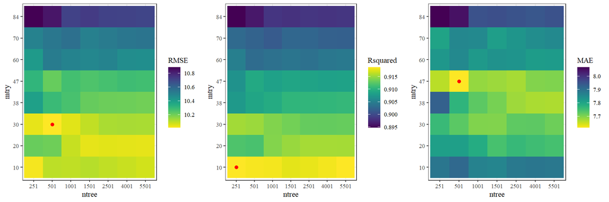

```r
p
```

Selected hyperparameters

```r
ntree <- 501
mtry <- as.integer(length(iVars)/3.5)
```

#### Run model

Train preliminary model

```r
nperm <- 10

resultsOutAbsDiffs <- crfReg(dataIn=stimNoticeDataANum, iVars=iVars, dVar=dVar, seeds=seeds[1:2], ntree=ntree, mtry=mtry, permImpCondThres=permImpCondThres, nperm=nperm, minsplit=minsplit, minbucket=minbucket)

# print model prediction results
resultsOutAbsDiffs$OOB_RMSE
```

```
[1] 9.931801
```

```r
resultsOutAbsDiffs$OOB_MAE
```

```
[1] 7.642687
```

```r
resultsOutAbsDiffs$Rsquared
```

```
[1] 0.9161515
```

Train multiple seeds model

```r
resultsOutAbsDiffs <- multi_crfReg(dataIn=stimNoticeDataANum, iVars=iVars, dVar=dVar, seeds=seeds, ntree=ntree, mtry=mtry, permImpCondThres=permImpCondThres, nperm=nperm, minsplit=minsplit, minbucket=minbucket)

# print model prediction results
resultsOutAbsDiffs$OOB_RMSE
```

```
[1] 10.03943
```

```r
resultsOutAbsDiffs$OOB_MAE
```

```
[1] 7.687145
```

```r
resultsOutAbsDiffs$Rsquared
```

```
[1] 0.9141022
```

```r
# store results
resNoticeFit['All vars', 'RMSE'] <- resultsOutAbsDiffs$OOB_RMSE
resNoticeFit['All vars', 'MAE'] <- resultsOutAbsDiffs$OOB_MAE
resNoticeFit['All vars', 'Rsquared'] <- resultsOutAbsDiffs$Rsquared
resNoticePermImp$AllVars <- resultsOutAbsDiffs$conditional_permimp
```

#### Plot results

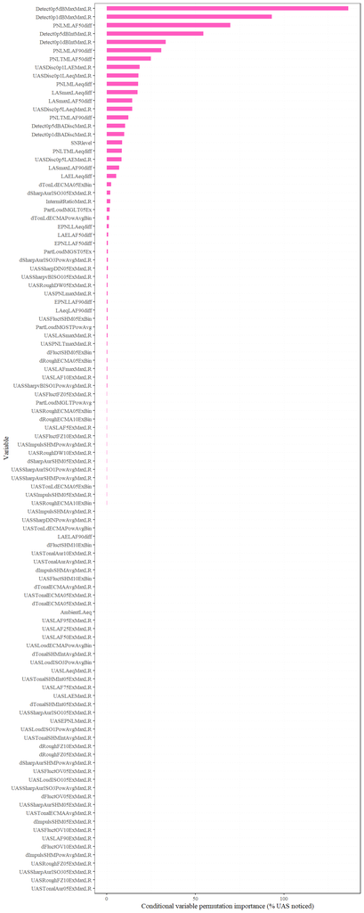

```r
par(mai=c(0,3,0,0))

# plot conditional importance
resultsOutAbsDiffs.conimp <- arrange(resultsOutAbsDiffs$conditional_permimp, desc(row_number()))

pBar <- ggplot(resultsOutAbsDiffs.conimp) + geom_col(aes(x=factor(rownames(resultsOutAbsDiffs.conimp), levels=rownames(resultsOutAbsDiffs.conimp)), y=CondPermImp), fill=mycolours[9], width=0.5) + labs(x="Variable", y="Conditional variable permutation importance (% UAS noticed)") + theme(text = element_text(family = "serif"), panel.grid=element_line(color = rgb(235, 235, 235, 100, maxColorValue = 255), linewidth = 0.25, linetype = 2)) + coord_flip()
pBar
```

```r
if (saveplots){
  ggsave(filename="PtANoticeAllVarsConPermimp.svg", width=8, height=20, path=file.path(outFigPath, "svg"))
  unlink("PtANoticeAllVarsConPermimp.svg")

  ggsave(filename="PtANoticeAllVarsConPermimp.pdf", width=8, height=20, path=file.path(outFigPath, "pdf"))
  unlink("PtANoticeAllVarsConPermimp.pdf")
}
```

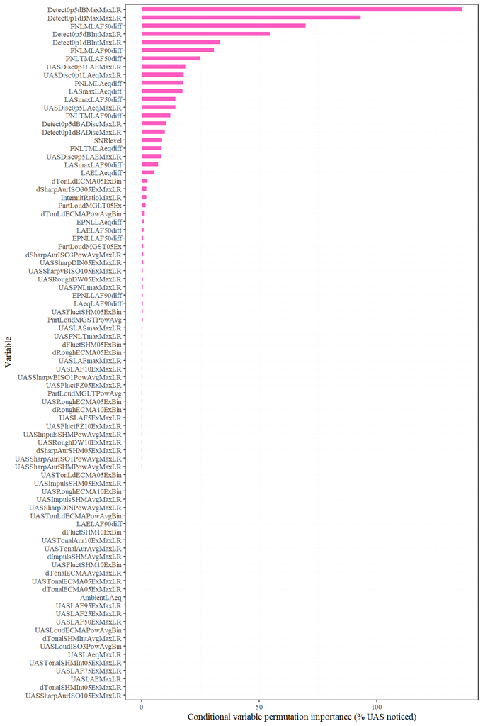

```r
# Plot only positive values

resultsOutAbsDiffs.conimpPtv <- resultsOutAbsDiffs.conimp |>
                                          rownames_to_column('Metric') |>
                                                filter_if(is.numeric, all_vars(. > 0)) |>
                                                      column_to_rownames('Metric')

pBar <- ggplot(resultsOutAbsDiffs.conimpPtv) + geom_col(aes(x=factor(rownames(resultsOutAbsDiffs.conimpPtv), levels=rownames(resultsOutAbsDiffs.conimpPtv)), y=CondPermImp), fill=mycolours[9], width=0.5) + labs(x="Variable", y="Conditional variable permutation importance (% UAS noticed)") + theme(text = element_text(family = "serif"), panel.grid=element_line(color = rgb(235, 235, 235, 100, maxColorValue = 255), linewidth = 0.25, linetype = 2)) + coord_flip()
pBar
```

```r
if (saveplots){
  ggsave(filename="PtANoticeAllVarsConPermimpPtv.svg", width=8, height=12, path=file.path(outFigPath, "svg"))
  unlink("PtANoticeAllVarsConPermimp.svg")

  ggsave(filename="PtANoticeAllVarsConPermimpPtv.pdf", width=8, height=12, path=file.path(outFigPath, "pdf"))
  unlink("PtANoticeAllVarsConPermimp.pdf")
}
```

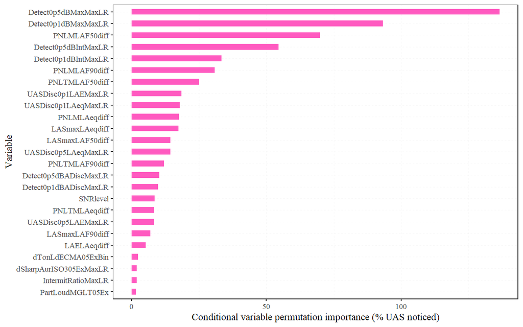

```r
# Plot only values within 1% of the maximum value

resultsOutAbsDiffs.conimp1pc <- resultsOutAbsDiffs.conimp |>
                                          rownames_to_column('Metric') |>
                                                filter_if(is.numeric, all_vars(. > max(resultsOutAbsDiffs.conimp)/100)) |>
                                                      column_to_rownames('Metric')

pBar <- ggplot(resultsOutAbsDiffs.conimp1pc) + geom_col(aes(x=factor(rownames(resultsOutAbsDiffs.conimp1pc), levels=rownames(resultsOutAbsDiffs.conimp1pc)), y=CondPermImp), fill=mycolours[9], width=0.5) + labs(x="Variable", y="Conditional variable permutation importance (% UAS noticed)") + theme(text = element_text(family = "serif"), panel.grid=element_line(color = rgb(235, 235, 235, 100, maxColorValue = 255), linewidth = 0.25, linetype = 2)) + coord_flip()
pBar
```

```r
if (saveplots){
  ggsave(filename="PtANoticeAllVarsConPermimp1pc.svg", width=8, height=5, path=file.path(outFigPath, "svg"))
  unlink("PtANoticeAllVarsConPermimp1pc.svg")

  ggsave(filename="PtANoticeAllVarsConPermimp1pc.pdf", width=8, height=5, path=file.path(outFigPath, "pdf"))
  unlink("PtANoticeAllVarsConPermimp1pc.pdf")
}
```

### Absolute variables

#### Set variables

```r
iVars <- names(stimNoticeDataANum)[which(names(stimNoticeDataANum) == 'AmbientLAeq'):which(names(stimNoticeDataANum) == 'UASImpulsSHM05ExMaxLR')]
iVars <- iVars[! iVars %in% c('SNRlevel')]
dVar <- "NoticedPcFilt"

seeds <- c(578312, 544, 84894, 54654, 153157)
```

#### Hyperparameter tuning

```r
p <- mtryTune(dataIn=stimNoticeDataANum, iVars=iVars, dVar=dVar, seed=seeds[1:2],
             ntrees=ntrees, minsplit=minsplit, minbucket=minbucket)
```

| RMSE | Rsquared | MAE | mtry | iVars_mtry |
| --- | --- | --- | --- | --- |
| 24.42540 | 0.4554855 | 18.43212 | 5 | 10.50 |
| 22.32437 | 0.5512598 | 16.76155 | 10 | 5.25 |
| 22.22984 | 0.5558481 | 16.66094 | 15 | 3.50 |
| 20.07702 | 0.6523038 | 15.10014 | 19 | 2.75 |
| 19.58138 | 0.6739424 | 14.74911 | 24 | 2.25 |
| 18.20448 | 0.7275536 | 13.76394 | 30 | 1.75 |
| 17.00642 | 0.7660008 | 12.77763 | 36 | 1.50 |
| 17.10233 | 0.7676330 | 12.90365 | 43 | 1.25 |

| RMSE | Rsquared | MAE | mtry | iVars_mtry |
| --- | --- | --- | --- | --- |
| 24.35593 | 0.4587877 | 18.41503 | 5 | 10.50 |
| 22.45212 | 0.5449520 | 16.89094 | 10 | 5.25 |
| 21.99315 | 0.5672276 | 16.51783 | 15 | 3.50 |
| 20.24092 | 0.6447936 | 15.23783 | 19 | 2.75 |
| 19.17954 | 0.6909403 | 14.45521 | 24 | 2.25 |
| 18.21578 | 0.7271368 | 13.79334 | 30 | 1.75 |
| 17.17424 | 0.7610358 | 13.00301 | 36 | 1.50 |
| 16.82062 | 0.7760178 | 12.72388 | 43 | 1.25 |

| RMSE | Rsquared | MAE | mtry | iVars_mtry |
| --- | --- | --- | --- | --- |
| 24.20099 | 0.4658540 | 18.30775 | 5 | 10.50 |
| 22.42041 | 0.5466964 | 16.88206 | 10 | 5.25 |
| 21.69809 | 0.5812709 | 16.30819 | 15 | 3.50 |
| 20.25105 | 0.6447143 | 15.23334 | 19 | 2.75 |
| 19.01261 | 0.6978315 | 14.31425 | 24 | 2.25 |
| 17.95732 | 0.7383888 | 13.60048 | 30 | 1.75 |
| 17.17201 | 0.7619303 | 12.96791 | 36 | 1.50 |
| 16.84052 | 0.7755682 | 12.77815 | 43 | 1.25 |

| RMSE | Rsquared | MAE | mtry | iVars_mtry |
| --- | --- | --- | --- | --- |
| 24.21544 | 0.4650655 | 18.32893 | 5 | 10.50 |
| 22.60634 | 0.5383465 | 17.02848 | 10 | 5.25 |
| 21.47792 | 0.5911936 | 16.14187 | 15 | 3.50 |
| 20.19319 | 0.6473509 | 15.19540 | 19 | 2.75 |
| 19.04099 | 0.6968686 | 14.30942 | 24 | 2.25 |
| 17.80706 | 0.7432415 | 13.47274 | 30 | 1.75 |
| 17.05781 | 0.7673081 | 12.91536 | 36 | 1.50 |
| 16.77969 | 0.7766722 | 12.71951 | 43 | 1.25 |

| RMSE | Rsquared | MAE | mtry | iVars_mtry |
| --- | --- | --- | --- | --- |
| 24.19175 | 0.4660742 | 18.30125 | 5 | 10.50 |
| 22.56938 | 0.5404611 | 16.98781 | 10 | 5.25 |
| 21.18109 | 0.6046472 | 15.94105 | 15 | 3.50 |
| 20.25173 | 0.6445392 | 15.23123 | 19 | 2.75 |
| 19.07831 | 0.6947703 | 14.36636 | 24 | 2.25 |
| 17.81985 | 0.7424092 | 13.50523 | 30 | 1.75 |
| 17.07396 | 0.7672305 | 12.95471 | 36 | 1.50 |
| 16.70214 | 0.7797830 | 12.68445 | 43 | 1.25 |

| RMSE | Rsquared | MAE | mtry | iVars_mtry |
| --- | --- | --- | --- | --- |
| 24.23741 | 0.4638574 | 18.34483 | 5 | 10.50 |
| 22.58699 | 0.5398920 | 16.99131 | 10 | 5.25 |
| 21.13403 | 0.6065232 | 15.90077 | 15 | 3.50 |
| 20.27912 | 0.6436134 | 15.23946 | 19 | 2.75 |
| 19.12400 | 0.6935690 | 14.39924 | 24 | 2.25 |
| 17.86849 | 0.7409227 | 13.52993 | 30 | 1.75 |
| 17.11150 | 0.7663629 | 12.98922 | 36 | 1.50 |
| 16.59561 | 0.7831406 | 12.61539 | 43 | 1.25 |

| RMSE | Rsquared | MAE | mtry | iVars_mtry |
| --- | --- | --- | --- | --- |
| 24.21881 | 0.4647511 | 18.32988 | 5 | 10.50 |
| 22.61337 | 0.5387442 | 16.99616 | 10 | 5.25 |
| 21.16158 | 0.6053610 | 15.91460 | 15 | 3.50 |
| 20.32092 | 0.6418209 | 15.27336 | 19 | 2.75 |
| 19.14497 | 0.6922166 | 14.41221 | 24 | 2.25 |
| 17.92112 | 0.7386704 | 13.56195 | 30 | 1.75 |
| 17.11612 | 0.7663199 | 12.99870 | 36 | 1.50 |
| 16.54480 | 0.7840653 | 12.57512 | 43 | 1.25 |

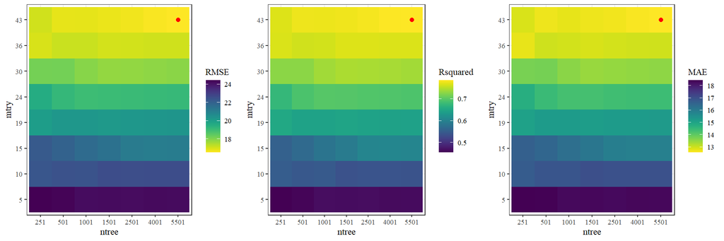

```r
p
```

```r
if (saveplots){
  ggsave(filename="PtANoticeAbsVarsHyperTune.svg", width=12, height=4, path=file.path(outFigPath, "svg"))
  unlink("PtANoticeAbsVarsHyperTune.svg")

  ggsave(filename="PtANoticeAbsVarsHyperTune.pdf", width=12, height=4, path=file.path(outFigPath, "pdf"))
  unlink("PtANoticeAbsVarsHyperTune.pdf")
}
```

Selected hyperparameters

```r
ntree <- 2501
mtry <- as.integer(length(iVars)/1.25)
```

#### Run model

Train preliminary model

```r
nperm <- 10

resultsOutAbs <- crfReg(dataIn=stimNoticeDataANum, iVars=iVars, dVar=dVar, seeds=seeds[1:2], ntree=ntree, mtry=mtry, permImpCondThres=permImpCondThres, nperm=nperm, minsplit=minsplit, minbucket=minbucket)

# print model prediction results
resultsOutAbs$OOB_RMSE
```

```
[1] 17.02334
```

```r
resultsOutAbs$OOB_MAE
```

```
[1] 12.93192
```

```r
resultsOutAbs$Rsquared
```

```
[1] 0.768918
```

Train multiple seeds model

```r
resultsOutAbs <- multi_crfReg(dataIn=stimNoticeDataANum, iVars=iVars, dVar=dVar, seeds=seeds, ntree=ntree, mtry=mtry, permImpCondThres=permImpCondThres, nperm=nperm, minsplit=minsplit, minbucket=minbucket)

# print model prediction results
resultsOutAbs$OOB_RMSE
```

```
[1] 16.60427
```

```r
resultsOutAbs$OOB_MAE
```

```
[1] 12.61885
```

```r
resultsOutAbs$Rsquared
```

```
[1] 0.782387
```

```r
# store results
resNoticeFit['Abs vars', 'RMSE'] <- resultsOutAbs$OOB_RMSE
resNoticeFit['Abs vars', 'MAE'] <- resultsOutAbs$OOB_MAE
resNoticeFit['Abs vars', 'Rsquared'] <- resultsOutAbs$Rsquared
resNoticePermImp$AbsVars <- resultsOutAbs$conditional_permimp
```

#### Plot results

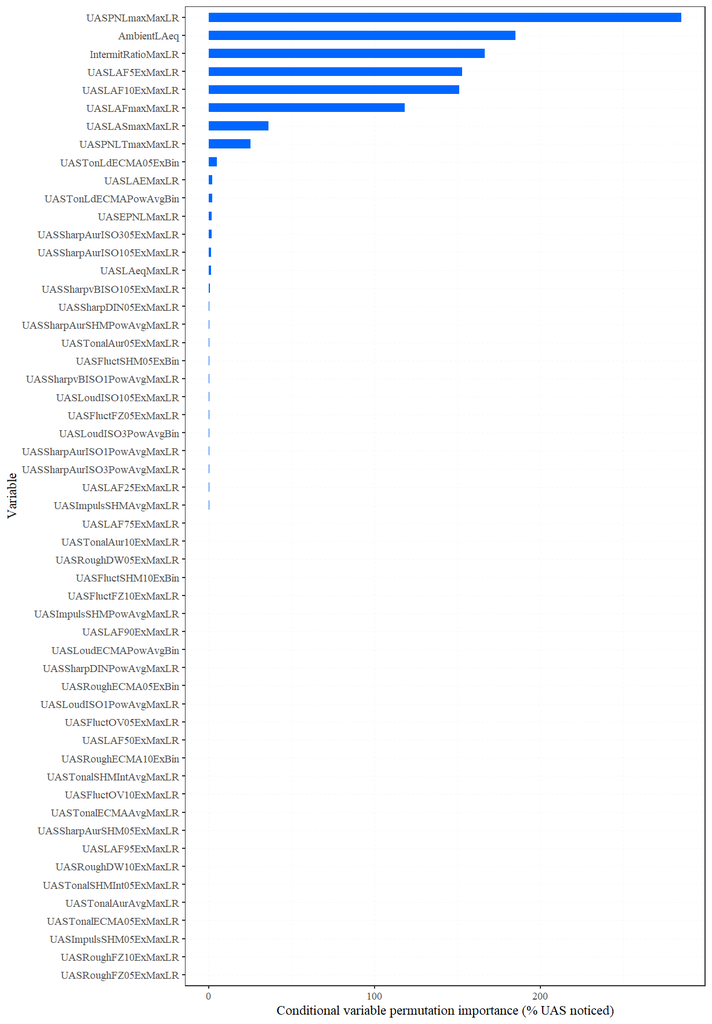

```r
par(mai=c(0,3,0,0))

# plot conditional importance
resultsOutAbs.conimp <- arrange(resultsOutAbs$conditional_permimp, desc(row_number()))

pBar <- ggplot(resultsOutAbs.conimp) + geom_col(aes(x=factor(rownames(resultsOutAbs.conimp), levels=rownames(resultsOutAbs.conimp)), y=CondPermImp), fill=mycolours[1], width=0.5) + labs(x="Variable", y="Conditional variable permutation importance (% UAS noticed)") + theme(text = element_text(family = "serif"), panel.grid=element_line(color = rgb(235, 235, 235, 100, maxColorValue = 255), linewidth = 0.25, linetype = 2)) +
  coord_flip()
pBar
```

```r
if (saveplots){
  ggsave(filename="PtANoticeAbsVarsConPermimp.svg", width=8, height=11.5, path=file.path(outFigPath, "svg"))
  unlink("PtANoticeAbsVarsConPermimp.svg")

  ggsave(filename="PtANoticeAbsVarsConPermimp.pdf", width=8, height=11.5, path=file.path(outFigPath, "pdf"))
  unlink("PtANoticeAbsVarsConPermimp.pdf")
}
```

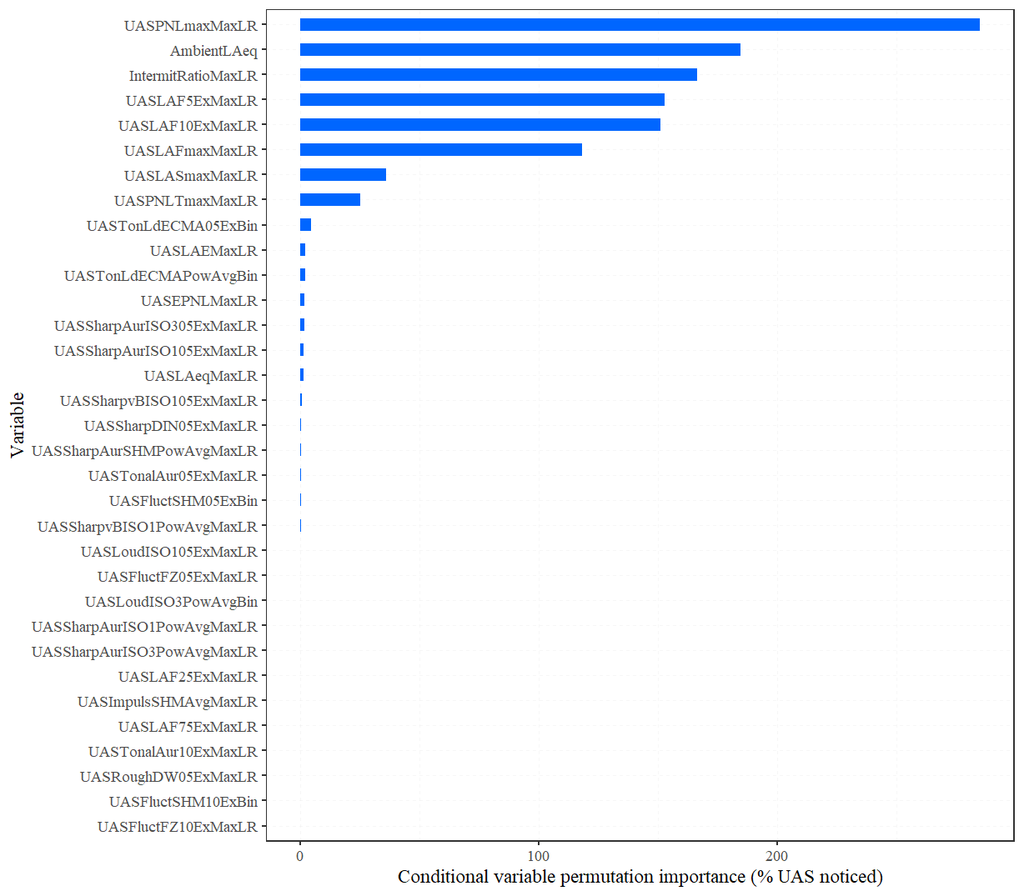

```r
# Plot only positive values
resultsOutAbs.conimpPtv <- resultsOutAbs.conimp |>
                                          rownames_to_column('Metric') |>
                                                filter_if(is.numeric, all_vars(. > 0)) |>
                                                      column_to_rownames('Metric')

pBar <- ggplot(resultsOutAbs.conimpPtv,) + geom_col(aes(x=factor(rownames(resultsOutAbs.conimpPtv), levels=rownames(resultsOutAbs.conimpPtv)), y=CondPermImp), fill=mycolours[1], width=0.5) + labs(x="Variable", y="Conditional variable permutation importance (% UAS noticed)") + theme(text = element_text(family = "serif"), panel.grid=element_line(color = rgb(235, 235, 235, 100, maxColorValue = 255), linewidth = 0.25, linetype = 2)) + coord_flip()
pBar
```

```r
if (saveplots){
  ggsave(filename="PtANoticeAbsVarsConPermimpPtv.svg", width=8, height=7, path=file.path(outFigPath, "svg"))
  unlink("PtANoticeAbsVarsConPermimpPtv.svg")

  ggsave(filename="PtANoticeAbsVarsConPermimpPtv.pdf", width=8, height=7, path=file.path(outFigPath, "pdf"))
  unlink("PtANoticeAbsVarsConPermimpPtv.pdf")
}
```

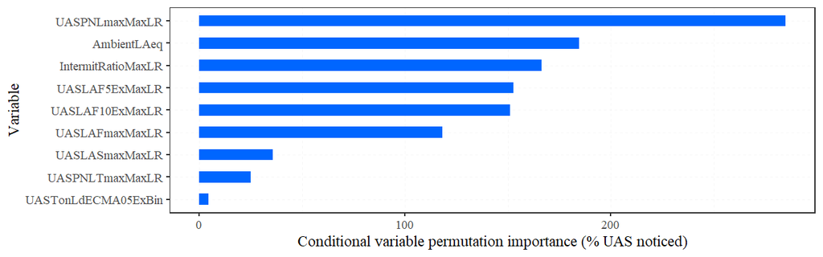

```r
# Plot only values within 1% of the maximum value
resultsOutAbs.conimp1pc <- resultsOutAbs.conimp |>
                                          rownames_to_column('Metric') |>
                                                filter_if(is.numeric, all_vars(. > max(resultsOutAbs.conimp)/100)) |>
                                                      column_to_rownames('Metric')

pBar <- ggplot(resultsOutAbs.conimp1pc,) + geom_col(aes(x=factor(rownames(resultsOutAbs.conimp1pc), levels=rownames(resultsOutAbs.conimp1pc)), y=CondPermImp), fill=mycolours[1], width=0.5) + labs(x="Variable", y="Conditional variable permutation importance (% UAS noticed)") + theme(text = element_text(family = "serif"), panel.grid=element_line(color = rgb(235, 235, 235, 100, maxColorValue = 255), linewidth = 0.25, linetype = 2)) + coord_flip()
pBar
```

```r
if (saveplots){
  ggsave(filename="PtANoticeAbsVarsConPermimp1pc.svg", width=8, height=2.5, path=file.path(outFigPath, "svg"))
  unlink("PtANoticeAbsVarsConPermimp1pc.svg")

  ggsave(filename="PtANoticeAbsVarsConPermimp1pc.pdf", width=8, height=2.5, path=file.path(outFigPath, "pdf"))
  unlink("PtANoticeAbsVarsConPermimp1pc.pdf")
}
```

Selected metric

```r
absVar <- "UASPNLmaxMaxLR"
```

### SQM analysis

#### Individual SQMs

##### Sharpness

###### Set variables

```r
iVars <- c(absVar, ambVar, "UASSharpAurISO3PowAvgMaxLR", "UASSharpAurISO305ExMaxLR", "UASSharpAurSHMPowAvgMaxLR", "UASSharpAurSHM05ExMaxLR", "UASSharpAurISO1PowAvgMaxLR", "UASSharpAurISO105ExMaxLR", "UASSharpvBISO1PowAvgMaxLR", "UASSharpvBISO105ExMaxLR", "UASSharpDINPowAvgMaxLR", "UASSharpDIN05ExMaxLR")
dVar <- "NoticedPcFilt"

seeds <- c(7041, 905, 4984651, 6513213, 120651)
```

###### Hyperparameter tuning

```r
p <- mtryTune(dataIn=stimNoticeDataANum, iVars=iVars, dVar=dVar, seed=seeds[1:2],
             ntrees=ntrees, minsplit=minsplit, minbucket=minbucket)
```

| RMSE | Rsquared | MAE | mtry | iVars_mtry |
| --- | --- | --- | --- | --- |
| 24.98999 | 0.4316765 | 19.15336 | 2 | 5.25 |
| 24.61384 | 0.4493367 | 18.60982 | 3 | 3.50 |
| 23.87027 | 0.4854545 | 18.05089 | 4 | 2.75 |
| 23.15651 | 0.5169904 | 17.53032 | 5 | 2.25 |
| 21.63974 | 0.5898743 | 16.54932 | 6 | 1.75 |
| 19.91545 | 0.6619492 | 15.13129 | 8 | 1.50 |
| 18.95715 | 0.6938389 | 14.49825 | 9 | 1.25 |

| RMSE | Rsquared | MAE | mtry | iVars_mtry |
| --- | --- | --- | --- | --- |
| 25.25314 | 0.4187913 | 19.34260 | 2 | 5.25 |
| 24.64488 | 0.4478951 | 18.65397 | 3 | 3.50 |
| 23.49121 | 0.5036575 | 17.81660 | 4 | 2.75 |
| 23.02472 | 0.5236254 | 17.44698 | 5 | 2.25 |
| 21.93393 | 0.5748727 | 16.65802 | 6 | 1.75 |
| 19.70529 | 0.6711289 | 15.01491 | 8 | 1.50 |
| 18.91878 | 0.6972680 | 14.43673 | 9 | 1.25 |

| RMSE | Rsquared | MAE | mtry | iVars_mtry |
| --- | --- | --- | --- | --- |
| 25.26066 | 0.4187060 | 19.23630 | 2 | 5.25 |
| 24.40081 | 0.4602888 | 18.50186 | 3 | 3.50 |
| 23.69393 | 0.4941070 | 17.92510 | 4 | 2.75 |
| 22.99001 | 0.5251781 | 17.36739 | 5 | 2.25 |
| 21.84624 | 0.5794322 | 16.58276 | 6 | 1.75 |
| 19.75952 | 0.6693857 | 15.06724 | 8 | 1.50 |
| 19.01905 | 0.6952572 | 14.48024 | 9 | 1.25 |

| RMSE | Rsquared | MAE | mtry | iVars_mtry |
| --- | --- | --- | --- | --- |
| 25.33940 | 0.4148594 | 19.25842 | 2 | 5.25 |
| 24.39743 | 0.4602882 | 18.47759 | 3 | 3.50 |
| 23.75313 | 0.4912573 | 17.96577 | 4 | 2.75 |
| 22.97346 | 0.5268732 | 17.36843 | 5 | 2.25 |
| 21.98519 | 0.5740724 | 16.67346 | 6 | 1.75 |
| 19.76609 | 0.6685453 | 15.08146 | 8 | 1.50 |
| 18.92947 | 0.6990691 | 14.41789 | 9 | 1.25 |

| RMSE | Rsquared | MAE | mtry | iVars_mtry |
| --- | --- | --- | --- | --- |
| 25.20849 | 0.4213477 | 19.16310 | 2 | 5.25 |
| 24.59431 | 0.4500892 | 18.61488 | 3 | 3.50 |
| 23.87647 | 0.4847005 | 18.06365 | 4 | 2.75 |
| 22.97970 | 0.5264356 | 17.37391 | 5 | 2.25 |
| 21.96515 | 0.5741578 | 16.65311 | 6 | 1.75 |
| 19.85916 | 0.6651269 | 15.15248 | 8 | 1.50 |
| 18.84536 | 0.7032420 | 14.35381 | 9 | 1.25 |

| RMSE | Rsquared | MAE | mtry | iVars_mtry |
| --- | --- | --- | --- | --- |
| 25.22913 | 0.4202783 | 19.15806 | 2 | 5.25 |
| 24.65892 | 0.4468040 | 18.67628 | 3 | 3.50 |
| 23.80555 | 0.4882864 | 18.00486 | 4 | 2.75 |
| 22.93574 | 0.5285696 | 17.35256 | 5 | 2.25 |
| 21.89974 | 0.5775383 | 16.60686 | 6 | 1.75 |
| 19.90489 | 0.6623892 | 15.18340 | 8 | 1.50 |
| 18.79614 | 0.7054042 | 14.32985 | 9 | 1.25 |

| RMSE | Rsquared | MAE | mtry | iVars_mtry |
| --- | --- | --- | --- | --- |
| 25.29941 | 0.4165672 | 19.20332 | 2 | 5.25 |
| 24.60752 | 0.4494534 | 18.63828 | 3 | 3.50 |
| 23.78134 | 0.4894241 | 17.98984 | 4 | 2.75 |
| 22.93790 | 0.5287481 | 17.34686 | 5 | 2.25 |
| 21.94472 | 0.5754213 | 16.62609 | 6 | 1.75 |
| 19.97281 | 0.6600684 | 15.23514 | 8 | 1.50 |
| 18.77557 | 0.7064683 | 14.32341 | 9 | 1.25 |

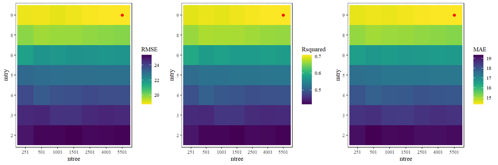

```r
p
```

Selected hyperparameters

```r
ntree <- 2501
mtry <- as.integer(length(iVars)/1.25)
```

###### Run model

Train preliminary model

```r
nperm <- 5

resultsOutSharp <- crfReg(dataIn=stimNoticeDataANum, iVars=iVars, dVar=dVar, seeds=seeds[1:2], ntree=ntree, mtry=mtry, permImpCondThres=permImpCondThres, nperm=nperm, minsplit=minsplit, minbucket=minbucket)

# print model prediction results
resultsOutSharp$OOB_RMSE
```

```
[1] 18.90396
```

```r
resultsOutSharp$OOB_MAE
```

```
[1] 14.44931
```

```r
resultsOutSharp$Rsquared
```

```
[1] 0.7027075
```

Train multiple seeds model

```r
resultsOutSharp <- multi_crfReg(dataIn=stimNoticeDataANum, iVars=iVars, dVar=dVar, seeds=seeds, ntree=ntree, mtry=mtry, permImpCondThres=permImpCondThres, nperm=nperm, minsplit=minsplit, minbucket=minbucket)

# print model prediction results
resultsOutSharp$OOB_RMSE
```

```
[1] 18.96332
```

```r
resultsOutSharp$OOB_MAE
```

```
[1] 14.46537
```

```r
resultsOutSharp$Rsquared
```

```
[1] 0.6996689
```

```r
# store results
resNoticeFit['Abs sharp', 'RMSE'] <- resultsOutSharp$OOB_RMSE
resNoticeFit['Abs sharp', 'MAE'] <- resultsOutSharp$OOB_MAE
resNoticeFit['Abs sharp', 'Rsquared'] <- resultsOutSharp$Rsquared
resNoticePermImp$AbsSharp <- resultsOutSharp$conditional_permimp
```

###### Plot results

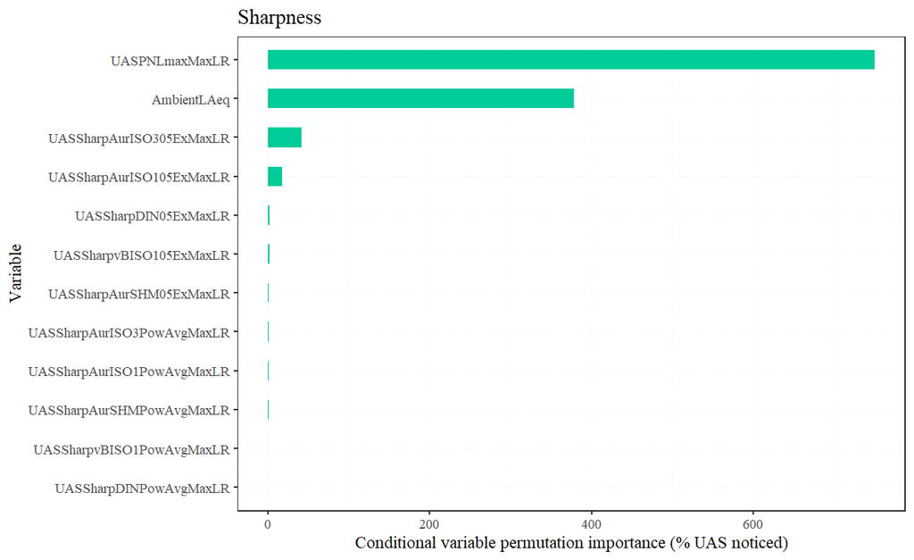

```r
par(mai=c(0,3,0,0))

# plot conditional importance
resultsOutSharp.conimp <- arrange(resultsOutSharp$conditional_permimp, desc(row_number()))

pBar <- ggplot(resultsOutSharp.conimp) + geom_col(aes(x=factor(rownames(resultsOutSharp.conimp), levels=rownames(resultsOutSharp.conimp)), y=CondPermImp), fill=mycolours[2], width=0.5) + labs(x="Variable", y="Conditional variable permutation importance (% UAS noticed)") + ggtitle("Sharpness") + theme(text = element_text(family = "serif"), panel.grid=element_line(color = rgb(235, 235, 235, 100, maxColorValue = 255), linewidth = 0.25, linetype = 2)) + coord_flip()
pBar
```

```r
if (saveplots){
  ggsave(filename="PtANoticeSharpConPermimp.svg", width=8, height=4.9, path=file.path(outFigPath, "svg"))
  unlink("PtANoticeSharpConPermimp.svg")

  ggsave(filename="PtANoticeSharpConPermimp.pdf", width=8, height=4.9, path=file.path(outFigPath, "pdf"))
  unlink("PtANoticeSharpConPermimp.pdf")
}
```

Selected metric

```r
sharpVar <- "UASSharpAurISO305ExMaxLR"
```

##### Tonal loudness and tonality

###### Set variables

```r
iVars <- c(absVar, ambVar, "UASTonalECMAAvgMaxLR", "UASTonalSHMInt05ExMaxLR", "UASTonalSHMIntAvgMaxLR", "UASTonalECMA05ExMaxLR", "UASTonLdECMAPowAvgBin", "UASTonLdECMA05ExBin", "UASTonalAurAvgMaxLR", "UASTonalAur05ExMaxLR", "UASTonalAur10ExMaxLR")
dVar <- "NoticedPcFilt"

seeds <- c(540, 104798, 456464, 87331, 94564)
```

###### Hyperparameter tuning

```r
p <- mtryTune(dataIn=stimNoticeDataANum, iVars=iVars, dVar=dVar, seed=seeds[1:2],
             ntrees=ntrees, minsplit=minsplit, minbucket=minbucket)
```

| RMSE | Rsquared | MAE | mtry | iVars_mtry |
| --- | --- | --- | --- | --- |
| 23.20105 | 0.5297752 | 17.74661 | 2 | 5.25 |
| 22.02489 | 0.5746400 | 16.76227 | 3 | 3.50 |
| 19.20182 | 0.6901529 | 14.75082 | 6 | 1.75 |
| 19.44138 | 0.6800397 | 14.82349 | 7 | 1.50 |
| 18.56617 | 0.7129880 | 14.17511 | 8 | 1.25 |

| RMSE | Rsquared | MAE | mtry | iVars_mtry |
| --- | --- | --- | --- | --- |
| 23.27584 | 0.5254105 | 17.82675 | 2 | 5.25 |
| 22.18274 | 0.5678195 | 16.96344 | 3 | 3.50 |
| 19.35824 | 0.6856967 | 14.86255 | 6 | 1.75 |
| 19.29896 | 0.6851390 | 14.71490 | 7 | 1.50 |
| 18.73499 | 0.7079676 | 14.33100 | 8 | 1.25 |

| RMSE | Rsquared | MAE | mtry | iVars_mtry |
| --- | --- | --- | --- | --- |
| 23.35690 | 0.5222535 | 17.95856 | 2 | 5.25 |
| 22.28605 | 0.5631730 | 17.00565 | 3 | 3.50 |
| 19.48572 | 0.6813538 | 14.93461 | 6 | 1.75 |
| 19.09119 | 0.6937227 | 14.55064 | 7 | 1.50 |
| 18.51395 | 0.7167421 | 14.18477 | 8 | 1.25 |

| RMSE | Rsquared | MAE | mtry | iVars_mtry |
| --- | --- | --- | --- | --- |
| 23.33919 | 0.5241320 | 17.93061 | 2 | 5.25 |
| 22.23683 | 0.5665913 | 16.98589 | 3 | 3.50 |
| 19.82467 | 0.6661935 | 15.16576 | 6 | 1.75 |
| 19.19600 | 0.6897765 | 14.65600 | 7 | 1.50 |
| 18.38600 | 0.7206906 | 14.12301 | 8 | 1.25 |

| RMSE | Rsquared | MAE | mtry | iVars_mtry |
| --- | --- | --- | --- | --- |
| 23.28000 | 0.5283976 | 17.87242 | 2 | 5.25 |
| 22.17396 | 0.5698352 | 16.96717 | 3 | 3.50 |
| 19.78813 | 0.6676861 | 15.13983 | 6 | 1.75 |
| 19.15428 | 0.6921339 | 14.65487 | 7 | 1.50 |
| 18.40760 | 0.7190262 | 14.13690 | 8 | 1.25 |

| RMSE | Rsquared | MAE | mtry | iVars_mtry |
| --- | --- | --- | --- | --- |
| 23.29931 | 0.5281032 | 17.90327 | 2 | 5.25 |
| 22.23579 | 0.5666465 | 17.02620 | 3 | 3.50 |
| 19.82770 | 0.6654219 | 15.17390 | 6 | 1.75 |
| 19.09285 | 0.6940863 | 14.61220 | 7 | 1.50 |
| 18.37535 | 0.7210170 | 14.11740 | 8 | 1.25 |

| RMSE | Rsquared | MAE | mtry | iVars_mtry |
| --- | --- | --- | --- | --- |
| 23.32326 | 0.5266470 | 17.92269 | 2 | 5.25 |
| 22.24271 | 0.5667671 | 17.03418 | 3 | 3.50 |
| 19.85832 | 0.6640853 | 15.19347 | 6 | 1.75 |
| 19.05222 | 0.6957705 | 14.58748 | 7 | 1.50 |
| 18.36875 | 0.7208313 | 14.11027 | 8 | 1.25 |

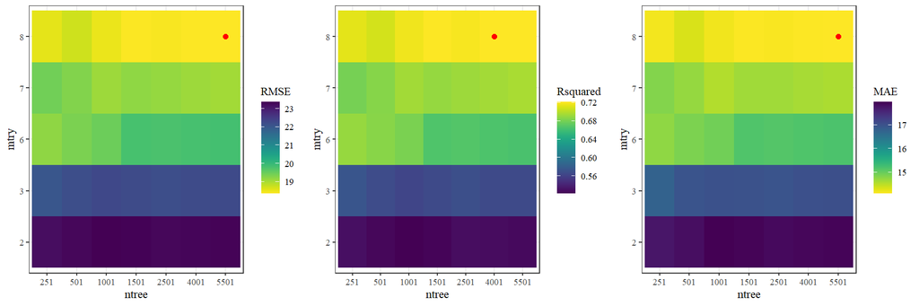

```r
p
```

Selected hyperparameters

```r
ntree <- 4001
mtry <- as.integer(length(iVars)/1.25)
```

###### Run model

Train preliminary model

```r
# Tonality with tonal loudness

nperm <- 5

resultsOutTonal1 <- crfReg(dataIn=stimNoticeDataANum, iVars=iVars, dVar=dVar, seeds=seeds[1:2], ntree=ntree, mtry=mtry, permImpCondThres=permImpCondThres, nperm=nperm, minsplit=minsplit, minbucket=minbucket)

# print model prediction results
resultsOutTonal1$OOB_RMSE
```

```
[1] 18.23844
```

```r
resultsOutTonal1$OOB_MAE
```

```
[1] 14.03167
```

```r
resultsOutTonal1$Rsquared
```

```
[1] 0.7272522
```

Train multiple seeds model

```r
# Tonality with tonal loudness

resultsOutTonal1 <- multi_crfReg(dataIn=stimNoticeDataANum, iVars=iVars, dVar=dVar, seeds=seeds, ntree=ntree, mtry=mtry, permImpCondThres=permImpCondThres, nperm=nperm, minsplit=minsplit, minbucket=minbucket)

# print model prediction results
resultsOutTonal1$OOB_RMSE
```

```
[1] 18.15954
```

```r
resultsOutTonal1$OOB_MAE
```

```
[1] 13.97047
```

```r
resultsOutTonal1$Rsquared
```

```
[1] 0.7291894
```

```r
# store results
resNoticeFit['Abs tonal inc loud', 'RMSE'] <- resultsOutTonal1$OOB_RMSE
resNoticeFit['Abs tonal inc loud', 'MAE'] <- resultsOutTonal1$OOB_MAE
resNoticeFit['Abs tonal inc loud', 'Rsquared'] <- resultsOutTonal1$Rsquared
resNoticePermImp$AbsTonal1 <- resultsOutTonal1$conditional_permimp
```

###### Plot results

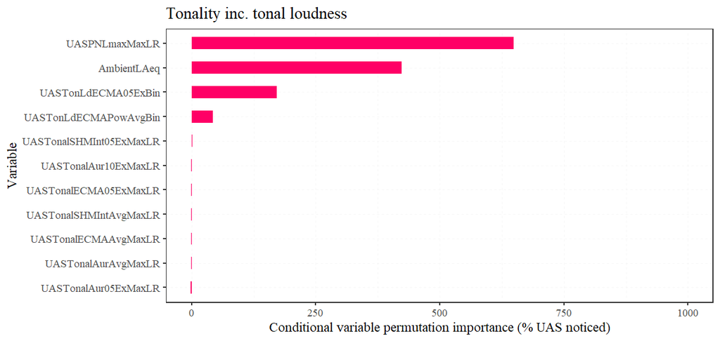

```r
par(mai=c(0,3,0,0))

# plot conditional importance
resultsOutTonal1.conimp <- arrange(resultsOutTonal1$conditional_permimp, desc(row_number()))

pBar <- ggplot(resultsOutTonal1.conimp) + geom_col(aes(x=factor(rownames(resultsOutTonal1.conimp), levels=rownames(resultsOutTonal1.conimp)), y=CondPermImp), fill=mycolours[3], width=0.5) + labs(x="Variable", y="Conditional variable permutation importance (% UAS noticed)") + ggtitle("Tonality inc. tonal loudness") + theme(text = element_text(family = "serif"), panel.grid=element_line(color = rgb(235, 235, 235, 100, maxColorValue = 255), linewidth = 0.25, linetype = 2)) + coord_flip(ylim=c(-1, 1000))
pBar
```

```r
if (saveplots){
  ggsave(filename="PtANoticeTonalLdConPermimp.svg", width=8, height=3.8, path=file.path(outFigPath, "svg"))
  unlink("PtANoticeTonalLdConPermimp.svg")

  ggsave(filename="PtANoticeTonalLdConPermimp.pdf", width=8, height=3.8, path=file.path(outFigPath, "pdf"))
  unlink("PtANoticeTonalLdConPermimp.pdf")
}
```

Selected metric

```r
tonLdVar <- "UASTonLdECMA05ExBin"
```

##### Tonality without tonal loudness

###### Set variables

```r
iVars <- c(absVar, ambVar, "UASTonalECMAAvgMaxLR", "UASTonalSHMInt05ExMaxLR", "UASTonalSHMIntAvgMaxLR", "UASTonalECMA05ExMaxLR", "UASTonalAurAvgMaxLR", "UASTonalAur05ExMaxLR", "UASTonalAur10ExMaxLR")
dVar <- "NoticedPcFilt"

seeds <- c(156089, 5860, 10528, 89541, 4685146)
```

###### Hyperparameter tuning

```r
p <- mtryTune(dataIn=stimNoticeDataANum, iVars=iVars, dVar=dVar, seed=seeds[1:2],
             ntrees=ntrees, minsplit=minsplit, minbucket=minbucket)
```

| RMSE | Rsquared | MAE | mtry | iVars_mtry |
| --- | --- | --- | --- | --- |
| 23.51002 | 0.5567357 | 18.48192 | 2 | 3.50 |
| 21.20570 | 0.6561099 | 16.66034 | 3 | 2.75 |
| 19.76459 | 0.7003237 | 15.36344 | 4 | 2.25 |
| 18.83933 | 0.7249848 | 14.63541 | 5 | 1.75 |
| 17.44977 | 0.7637779 | 13.53611 | 6 | 1.50 |
| 17.40137 | 0.7587074 | 13.50778 | 7 | 1.25 |

| RMSE | Rsquared | MAE | mtry | iVars_mtry |
| --- | --- | --- | --- | --- |
| 22.98516 | 0.5892101 | 18.03207 | 2 | 3.50 |
| 21.27560 | 0.6486432 | 16.69188 | 3 | 2.75 |
| 19.94719 | 0.6902629 | 15.47321 | 4 | 2.25 |
| 18.64644 | 0.7291913 | 14.44555 | 5 | 1.75 |
| 17.54901 | 0.7592003 | 13.61598 | 6 | 1.50 |
| 17.06485 | 0.7705563 | 13.27163 | 7 | 1.25 |

| RMSE | Rsquared | MAE | mtry | iVars_mtry |
| --- | --- | --- | --- | --- |
| 23.05463 | 0.5835565 | 18.14566 | 2 | 3.50 |
| 21.28603 | 0.6499754 | 16.68939 | 3 | 2.75 |
| 19.74441 | 0.6982925 | 15.37187 | 4 | 2.25 |
| 18.42281 | 0.7349903 | 14.29610 | 5 | 1.75 |
| 17.92806 | 0.7469792 | 13.87702 | 6 | 1.50 |
| 17.34339 | 0.7620898 | 13.45143 | 7 | 1.25 |

| RMSE | Rsquared | MAE | mtry | iVars_mtry |
| --- | --- | --- | --- | --- |
| 23.01888 | 0.5859466 | 18.13098 | 2 | 3.50 |
| 21.34079 | 0.6455588 | 16.71411 | 3 | 2.75 |
| 19.80970 | 0.6968758 | 15.43037 | 4 | 2.25 |
| 18.52608 | 0.7322663 | 14.40354 | 5 | 1.75 |
| 17.93200 | 0.7476516 | 13.88548 | 6 | 1.50 |
| 17.39255 | 0.7610357 | 13.49713 | 7 | 1.25 |

| RMSE | Rsquared | MAE | mtry | iVars_mtry |
| --- | --- | --- | --- | --- |
| 22.86751 | 0.5940585 | 17.99233 | 2 | 3.50 |
| 21.48604 | 0.6382469 | 16.79471 | 3 | 2.75 |
| 19.70069 | 0.7009530 | 15.33328 | 4 | 2.25 |
| 18.44403 | 0.7365440 | 14.35581 | 5 | 1.75 |
| 17.76527 | 0.7543520 | 13.78251 | 6 | 1.50 |
| 17.28567 | 0.7649205 | 13.41108 | 7 | 1.25 |

| RMSE | Rsquared | MAE | mtry | iVars_mtry |
| --- | --- | --- | --- | --- |
| 22.97008 | 0.5889400 | 18.08445 | 2 | 3.50 |
| 21.40416 | 0.6418653 | 16.74400 | 3 | 2.75 |
| 19.72585 | 0.6991866 | 15.35316 | 4 | 2.25 |
| 18.37334 | 0.7401274 | 14.32237 | 5 | 1.75 |
| 17.75354 | 0.7548034 | 13.77158 | 6 | 1.50 |
| 17.34532 | 0.7630349 | 13.44394 | 7 | 1.25 |

| RMSE | Rsquared | MAE | mtry | iVars_mtry |
| --- | --- | --- | --- | --- |
| 22.98639 | 0.5871210 | 18.10425 | 2 | 3.50 |
| 21.34571 | 0.6441894 | 16.70027 | 3 | 2.75 |
| 19.68789 | 0.7015940 | 15.33412 | 4 | 2.25 |
| 18.38972 | 0.7396739 | 14.33894 | 5 | 1.75 |
| 17.79139 | 0.7533900 | 13.81149 | 6 | 1.50 |
| 17.27931 | 0.7654534 | 13.39349 | 7 | 1.25 |

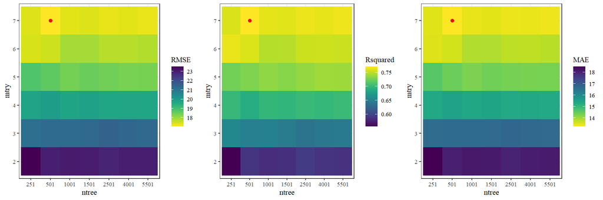

```r
p
```

Selected hyperparameters

```r
ntree <- 501
mtry <- as.integer(length(iVars)/1.25)
```

###### Run model

Train preliminary model

```r
# Tonality

nperm <- 5

resultsOutTonal2 <- crfReg(dataIn=stimNoticeDataANum, iVars=iVars, dVar=dVar, seeds=seeds[1:2], ntree=ntree, mtry=mtry, permImpCondThres=permImpCondThres, nperm=nperm, minsplit=minsplit, minbucket=minbucket)

# print model prediction results
resultsOutTonal2$OOB_RMSE
```

```
[1] 17.67196
```

```r
resultsOutTonal2$OOB_MAE
```

```
[1] 13.73367
```

```r
resultsOutTonal2$Rsquared
```

```
[1] 0.7534847
```

Train multiple seeds model

```r
# Tonality

resultsOutTonal2 <- multi_crfReg(dataIn=stimNoticeDataANum, iVars=iVars, dVar=dVar, seeds=seeds, ntree=ntree, mtry=mtry, permImpCondThres=permImpCondThres, nperm=nperm, minsplit=minsplit, minbucket=minbucket)

# print model prediction results
resultsOutTonal2$OOB_RMSE
```

```
[1] 17.33087
```

```r
resultsOutTonal2$OOB_MAE
```

```
[1] 13.44098
```

```r
resultsOutTonal2$Rsquared
```

```
[1] 0.7624715
```

```r
# store results
resNoticeFit['Abs tonal no loud', 'RMSE'] <- resultsOutTonal2$OOB_RMSE
resNoticeFit['Abs tonal no loud', 'MAE'] <- resultsOutTonal2$OOB_MAE
resNoticeFit['Abs tonal no loud', 'Rsquared'] <- resultsOutTonal2$Rsquared
resNoticePermImp$AbsTonal2 <- resultsOutTonal2$conditional_permimp
```

###### Plot results

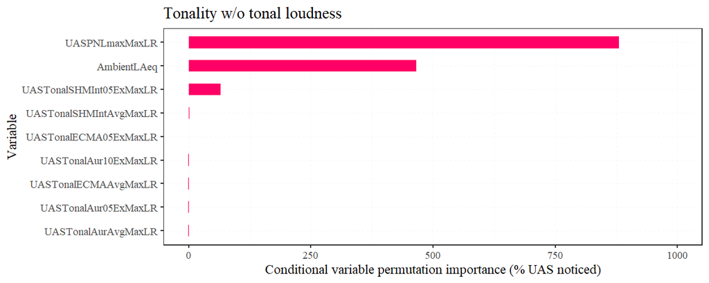

```r
par(mai=c(0,3,0,0))

# plot conditional importance
resultsOutTonal2.conimp <- arrange(resultsOutTonal2$conditional_permimp, desc(row_number()))

pBar <- ggplot(resultsOutTonal2.conimp) + geom_col(aes(x=factor(rownames(resultsOutTonal2.conimp), levels=rownames(resultsOutTonal2.conimp)), y=CondPermImp), fill=mycolours[3], width=0.5) + labs(x="Variable", y="Conditional variable permutation importance (% UAS noticed)") + ggtitle("Tonality w/o tonal loudness") + theme(text = element_text(family = "serif"), panel.grid=element_line(color = rgb(235, 235, 235, 100, maxColorValue = 255), linewidth = 0.25, linetype = 2)) + coord_flip(ylim=c(-1, 1000))
pBar
```

```r
if (saveplots){
  ggsave(filename="PtANoticeTonalConPermimp.svg", width=8, height=3.2, path=file.path(outFigPath, "svg"))
  unlink("PtANoticeTonalConPermimp.svg")

  ggsave(filename="PtANoticeTonalConPermimp.pdf", width=8, height=3.2, path=file.path(outFigPath, "pdf"))
  unlink("PtANoticeTonalConPermimp.pdf")
}
```

Selected metric

```r
tonalVar <- "UASTonalSHMInt05ExMaxLR"
```

##### Fluctuation strength

###### Set variables

```r
# Fluctuation strength
iVars <- c(absVar, ambVar, "UASFluctSHM10ExBin", "UASFluctSHM05ExBin", "UASFluctFZ10ExMaxLR", "UASFluctFZ05ExMaxLR", "UASFluctOV10ExMaxLR", "UASFluctOV05ExMaxLR")
dVar <- "NoticedPcFilt"

seeds <- c(25107, 546098, 195, 5937, 102658)
```

###### Hyperparameter tuning

```r
p <- mtryTune(dataIn=stimNoticeDataANum, iVars=iVars, dVar=dVar, seed=seeds[1:2],
             ntrees=ntrees, minsplit=minsplit, minbucket=minbucket)
```

| RMSE | Rsquared | MAE | mtry | iVars_mtry |
| --- | --- | --- | --- | --- |
| 19.74741 | 0.7106934 | 15.06096 | 3 | 2.25 |
| 18.70359 | 0.7311694 | 14.14192 | 4 | 1.75 |
| 17.05244 | 0.7767819 | 12.92742 | 5 | 1.50 |
| 16.86677 | 0.7809313 | 12.73284 | 6 | 1.25 |

| RMSE | Rsquared | MAE | mtry | iVars_mtry |
| --- | --- | --- | --- | --- |
| 19.78715 | 0.7136516 | 15.12578 | 3 | 2.25 |
| 18.68206 | 0.7350041 | 14.04829 | 4 | 1.75 |
| 17.29053 | 0.7736941 | 13.03670 | 5 | 1.50 |
| 17.03562 | 0.7723064 | 12.87402 | 6 | 1.25 |

| RMSE | Rsquared | MAE | mtry | iVars_mtry |
| --- | --- | --- | --- | --- |
| 19.81294 | 0.7099058 | 15.10429 | 3 | 2.25 |
| 18.73117 | 0.7331452 | 14.12780 | 4 | 1.75 |
| 17.25566 | 0.7737489 | 13.05843 | 5 | 1.50 |
| 16.78064 | 0.7811477 | 12.70463 | 6 | 1.25 |

| RMSE | Rsquared | MAE | mtry | iVars_mtry |
| --- | --- | --- | --- | --- |
| 19.85226 | 0.7103465 | 15.15072 | 3 | 2.25 |
| 18.71346 | 0.7352565 | 14.11908 | 4 | 1.75 |
| 17.40221 | 0.7690643 | 13.16562 | 5 | 1.50 |
| 16.63061 | 0.7850933 | 12.56515 | 6 | 1.25 |

| RMSE | Rsquared | MAE | mtry | iVars_mtry |
| --- | --- | --- | --- | --- |
| 20.00170 | 0.7025937 | 15.26257 | 3 | 2.25 |
| 18.62731 | 0.7397157 | 14.08274 | 4 | 1.75 |
| 17.39434 | 0.7691095 | 13.16301 | 5 | 1.50 |
| 16.56385 | 0.7874141 | 12.53972 | 6 | 1.25 |

| RMSE | Rsquared | MAE | mtry | iVars_mtry |
| --- | --- | --- | --- | --- |
| 20.00618 | 0.7024004 | 15.26036 | 3 | 2.25 |
| 18.66675 | 0.7388084 | 14.13178 | 4 | 1.75 |
| 17.38031 | 0.7705761 | 13.16090 | 5 | 1.50 |
| 16.57950 | 0.7873950 | 12.54967 | 6 | 1.25 |

| RMSE | Rsquared | MAE | mtry | iVars_mtry |
| --- | --- | --- | --- | --- |
| 20.03440 | 0.6998023 | 15.25437 | 3 | 2.25 |
| 18.60532 | 0.7408395 | 14.08333 | 4 | 1.75 |
| 17.42672 | 0.7686266 | 13.18692 | 5 | 1.50 |
| 16.58464 | 0.7868890 | 12.55033 | 6 | 1.25 |

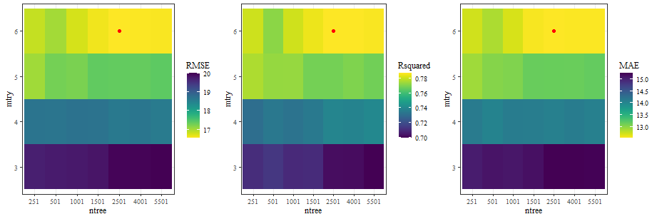

```r
p
```

Selected hyperparameters

```r
ntree <- 2501
mtry <- as.integer(length(iVars)/1.25)
```

###### Run model

Train preliminary model

```r
nperm <- 5

resultsOutFluct <- crfReg(dataIn=stimNoticeDataANum, iVars=iVars, dVar=dVar, seeds=seeds[1:2], ntree=ntree, mtry=mtry, permImpCondThres=permImpCondThres, nperm=nperm, minsplit=minsplit, minbucket=minbucket)

# print model prediction results
resultsOutFluct$OOB_RMSE
```

```
[1] 16.68041
```

```r
resultsOutFluct$OOB_MAE
```

```
[1] 12.58988
```

```r
resultsOutFluct$Rsquared
```

```
[1] 0.7838848
```

Train multiple seeds model

```r
resultsOutFluct <- multi_crfReg(dataIn=stimNoticeDataANum, iVars=iVars, dVar=dVar, seeds=seeds, ntree=ntree, mtry=mtry, permImpCondThres=permImpCondThres, nperm=nperm, minsplit=minsplit, minbucket=minbucket)

# print model prediction results
resultsOutFluct$OOB_RMSE
```

```
[1] 16.68387
```

```r
resultsOutFluct$OOB_MAE
```

```
[1] 12.62054
```

```r
resultsOutFluct$Rsquared
```

```
[1] 0.7824909
```

```r
# store results
resNoticeFit['Abs fluct', 'RMSE'] <- resultsOutFluct$OOB_RMSE
resNoticeFit['Abs fluct', 'MAE'] <- resultsOutFluct$OOB_MAE
resNoticeFit['Abs fluct', 'Rsquared'] <- resultsOutFluct$Rsquared
resNoticePermImp$AbsFluct <- resultsOutFluct$conditional_permimp
```

###### Plot results

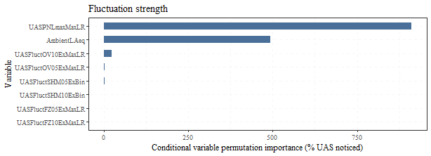

```r
par(mai=c(0,3,0,0))

# plot conditional importance
resultsOutFluct.conimp <- arrange(resultsOutFluct$conditional_permimp, desc(row_number()))

pBar <- ggplot(resultsOutFluct.conimp) + geom_col(aes(x=factor(rownames(resultsOutFluct.conimp), levels=rownames(resultsOutFluct.conimp)), y=CondPermImp), fill=mycolours[4], width=0.5) + labs(x="Variable", y="Conditional variable permutation importance (% UAS noticed)") + ggtitle("Fluctuation strength") + theme(text = element_text(family = "serif"), panel.grid=element_line(color = rgb(235, 235, 235, 100, maxColorValue = 255), linewidth = 0.25, linetype = 2)) + coord_flip()
pBar
```

```r
if (saveplots){
  ggsave(filename="PtANoticeFluctConPermimp.svg", width=8, height=2.9, path=file.path(outFigPath, "svg"))
  unlink("PtANoticeFluctConPermimp.svg")

  ggsave(filename="PtANoticeFluctConPermimp.pdf", width=8, height=2.9, path=file.path(outFigPath, "pdf"))
  unlink("PtANoticeFluctConPermimp.pdf")
}
```

Selected metric

```r
fluctVar <- "UASFluctOV10ExMaxLR"
```

##### Roughness

###### Set variables

```r
# Roughness
iVars <- c(absVar, ambVar, "UASRoughECMA10ExBin", "UASRoughECMA05ExBin", "UASRoughFZ10ExMaxLR", "UASRoughFZ05ExMaxLR", "UASRoughDW10ExMaxLR", "UASRoughDW05ExMaxLR")
dVar <- "NoticedPcFilt"

seeds <- c(4701, 52187, 16589, 65217, 16893)
```

###### Hyperparameter tuning

```r
p <- mtryTune(dataIn=stimNoticeDataANum, iVars=iVars, dVar=dVar, seed=seeds[1:2],
             ntrees=ntrees, minsplit=minsplit, minbucket=minbucket)
```

| RMSE | Rsquared | MAE | mtry | iVars_mtry |
| --- | --- | --- | --- | --- |
| 21.15670 | 0.6934730 | 16.60438 | 3 | 2.25 |
| 19.77556 | 0.7116009 | 15.28556 | 4 | 1.75 |
| 18.10086 | 0.7551300 | 13.92541 | 5 | 1.50 |
| 17.13361 | 0.7711834 | 13.16834 | 6 | 1.25 |

| RMSE | Rsquared | MAE | mtry | iVars_mtry |
| --- | --- | --- | --- | --- |
| 20.86483 | 0.7046889 | 16.36070 | 3 | 2.25 |
| 19.47163 | 0.7259056 | 15.09428 | 4 | 1.75 |
| 18.03179 | 0.7553474 | 13.83038 | 5 | 1.50 |
| 17.18554 | 0.7731281 | 13.16161 | 6 | 1.25 |

| RMSE | Rsquared | MAE | mtry | iVars_mtry |
| --- | --- | --- | --- | --- |
| 20.97429 | 0.7003436 | 16.42236 | 3 | 2.25 |
| 19.22889 | 0.7319870 | 14.89674 | 4 | 1.75 |
| 18.18570 | 0.7526498 | 14.00843 | 5 | 1.50 |
| 17.07917 | 0.7730670 | 13.07395 | 6 | 1.25 |

| RMSE | Rsquared | MAE | mtry | iVars_mtry |
| --- | --- | --- | --- | --- |
| 21.07962 | 0.6958395 | 16.51027 | 3 | 2.25 |
| 19.29291 | 0.7308992 | 14.97791 | 4 | 1.75 |
| 18.22961 | 0.7514034 | 14.03441 | 5 | 1.50 |
| 17.06552 | 0.7744146 | 13.04844 | 6 | 1.25 |

| RMSE | Rsquared | MAE | mtry | iVars_mtry |
| --- | --- | --- | --- | --- |
| 21.04013 | 0.6960274 | 16.48281 | 3 | 2.25 |
| 19.31085 | 0.7304568 | 15.00309 | 4 | 1.75 |
| 18.11422 | 0.7564379 | 13.95505 | 5 | 1.50 |
| 17.01422 | 0.7767914 | 13.04502 | 6 | 1.25 |

| RMSE | Rsquared | MAE | mtry | iVars_mtry |
| --- | --- | --- | --- | --- |
| 21.14494 | 0.6904410 | 16.54713 | 3 | 2.25 |
| 19.29454 | 0.7332795 | 14.99711 | 4 | 1.75 |
| 17.99757 | 0.7608199 | 13.86742 | 5 | 1.50 |
| 16.99386 | 0.7779421 | 13.03559 | 6 | 1.25 |

| RMSE | Rsquared | MAE | mtry | iVars_mtry |
| --- | --- | --- | --- | --- |
| 21.12753 | 0.6895916 | 16.52978 | 3 | 2.25 |
| 19.23332 | 0.7361716 | 14.93226 | 4 | 1.75 |
| 17.97576 | 0.7620098 | 13.86086 | 5 | 1.50 |
| 16.96343 | 0.7791355 | 13.01099 | 6 | 1.25 |

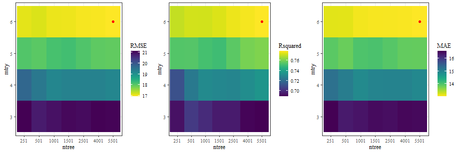

```r
p
```

Selected hyperparameters

```r
ntree <- 5501
mtry <- as.integer(length(iVars)/1.25)
```

###### Run model

Train preliminary model

```r
nperm <- 5

resultsOutRough <- crfReg(dataIn=stimNoticeDataANum, iVars=iVars, dVar=dVar, seeds=seeds[1:2], ntree=ntree, mtry=mtry, permImpCondThres=permImpCondThres, nperm=nperm, minsplit=minsplit, minbucket=minbucket)

# print model prediction results
resultsOutRough$OOB_RMSE
```

```
[1] 17.06155
```

```r
resultsOutRough$OOB_MAE
```

```
[1] 13.05433
```

```r
resultsOutRough$Rsquared
```

```
[1] 0.7754115
```

Train multiple seeds model

```r
resultsOutRough <- multi_crfReg(dataIn=stimNoticeDataANum, iVars=iVars, dVar=dVar, seeds=seeds, ntree=ntree, mtry=mtry, permImpCondThres=permImpCondThres, nperm=nperm, minsplit=minsplit, minbucket=minbucket)

# print model prediction results
resultsOutRough$OOB_RMSE
```

```
[1] 16.90099
```

```r
resultsOutRough$OOB_MAE
```

```
[1] 12.95294
```

```r
resultsOutRough$Rsquared
```

```
[1] 0.7802769
```

```r
# store results
resNoticeFit['Abs rough', 'RMSE'] <- resultsOutRough$OOB_RMSE
resNoticeFit['Abs rough', 'MAE'] <- resultsOutRough$OOB_MAE
resNoticeFit['Abs rough', 'Rsquared'] <- resultsOutRough$Rsquared
resNoticePermImp$AbsRough <- resultsOutRough$conditional_permimp
```

###### Plot results

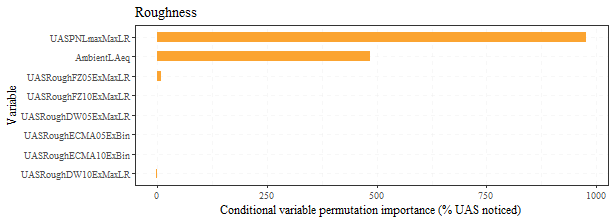

```r
par(mai=c(0,3,0,0))

# plot conditional importance
resultsOutRough.conimp <- arrange(resultsOutRough$conditional_permimp, desc(row_number()))

pBar <- ggplot(resultsOutRough.conimp) + geom_col(aes(x=factor(rownames(resultsOutRough.conimp), levels=rownames(resultsOutRough.conimp)), y=CondPermImp), fill=mycolours[5], width=0.5) + labs(x="Variable", y="Conditional variable permutation importance (% UAS noticed)") + ggtitle("Roughness") + theme(text = element_text(family = "serif"), panel.grid=element_line(color = rgb(235, 235, 235, 100, maxColorValue = 255), linewidth = 0.25, linetype = 2)) + coord_flip()
pBar
```

```r
if (saveplots){
  ggsave(filename="PtANoticeRoughConPermimp.svg", width=8, height=2.9, path=file.path(outFigPath, "svg"))
  unlink("PtANoticeRoughConPermimp.svg")

  ggsave(filename="PtANoticeRoughConPermimp.pdf", width=8, height=2.9, path=file.path(outFigPath, "pdf"))
  unlink("PtANoticeRoughConPermimp.pdf")
}
```

Selected metric

```r
roughVar <- "UASRoughFZ05ExMaxLR"
```

##### Impulsiveness

###### Set variables

```r
# Impulsiveness
iVars <- c(absVar, ambVar, "UASImpulsSHMAvgMaxLR", "UASImpulsSHM05ExMaxLR", "UASImpulsSHMPowAvgMaxLR")
dVar <- "NoticedPcFilt"

seeds <- c(8495, 59867, 5416, 9843, 86)
```

###### Hyperparameter tuning

```r
p <- mtryTune(dataIn=stimNoticeDataANum, iVars=iVars, dVar=dVar, seed=seeds[1:2],
             ntrees=ntrees, minsplit=minsplit, minbucket=minbucket)
```

| RMSE | Rsquared | MAE | mtry | iVars_mtry |
| --- | --- | --- | --- | --- |
| 17.86694 | 0.7778212 | 13.98690 | 3 | 1.50 |
| 16.58504 | 0.7802826 | 12.65989 | 4 | 1.25 |

| RMSE | Rsquared | MAE | mtry | iVars_mtry |
| --- | --- | --- | --- | --- |
| 17.79779 | 0.7842368 | 13.98416 | 3 | 1.50 |
| 16.49470 | 0.7856523 | 12.59283 | 4 | 1.25 |

| RMSE | Rsquared | MAE | mtry | iVars_mtry |
| --- | --- | --- | --- | --- |
| 17.81053 | 0.7889653 | 14.04569 | 3 | 1.50 |
| 16.11750 | 0.7975500 | 12.30574 | 4 | 1.25 |

| RMSE | Rsquared | MAE | mtry | iVars_mtry |
| --- | --- | --- | --- | --- |
| 17.75932 | 0.7914443 | 14.01767 | 3 | 1.50 |
| 16.03331 | 0.8012462 | 12.28486 | 4 | 1.25 |

| RMSE | Rsquared | MAE | mtry | iVars_mtry |
| --- | --- | --- | --- | --- |
| 17.63347 | 0.7952883 | 13.89886 | 3 | 1.50 |
| 16.04526 | 0.8025460 | 12.30003 | 4 | 1.25 |

| RMSE | Rsquared | MAE | mtry | iVars_mtry |
| --- | --- | --- | --- | --- |
| 17.68092 | 0.7934064 | 13.94658 | 3 | 1.50 |
| 16.18624 | 0.7982710 | 12.41483 | 4 | 1.25 |

| RMSE | Rsquared | MAE | mtry | iVars_mtry |
| --- | --- | --- | --- | --- |
| 17.67229 | 0.7920656 | 13.94171 | 3 | 1.50 |
| 16.18147 | 0.7992018 | 12.41758 | 4 | 1.25 |

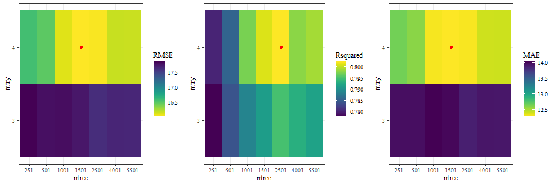

```r
p
```

Selected hyperparameters

```r
ntree <- 1501
mtry <- as.integer(length(iVars)/1.25)
```

###### Run model

Train preliminary model

```r
nperm <- 5

resultsOutImpuls <- crfReg(dataIn=stimNoticeDataANum, iVars=iVars, dVar=dVar, seeds=seeds[1:2], ntree=ntree, mtry=mtry, permImpCondThres=permImpCondThres, nperm=nperm, minsplit=minsplit, minbucket=minbucket)

# print model prediction results
resultsOutImpuls$OOB_RMSE
```

```
[1] 16.43779
```

```r
resultsOutImpuls$OOB_MAE
```

```
[1] 12.67182
```

```r
resultsOutImpuls$Rsquared
```

```
[1] 0.7921064
```

Train multiple seeds model

```r
resultsOutImpuls <- multi_crfReg(dataIn=stimNoticeDataANum, iVars=iVars, dVar=dVar, seeds=seeds, ntree=ntree, mtry=mtry, permImpCondThres=permImpCondThres, nperm=nperm, minsplit=minsplit, minbucket=minbucket)

# print model prediction results
resultsOutImpuls$OOB_RMSE
```

```
[1] 16.25679
```

```r
resultsOutImpuls$OOB_MAE
```

```
[1] 12.47224
```

```r
resultsOutImpuls$Rsquared
```

```
[1] 0.7964975
```

```r
# store results
resNoticeFit['Abs impuls', 'RMSE'] <- resultsOutImpuls$OOB_RMSE
resNoticeFit['Abs impuls', 'MAE'] <- resultsOutImpuls$OOB_MAE
resNoticeFit['Abs impuls', 'Rsquared'] <- resultsOutImpuls$Rsquared
resNoticePermImp$AbsImpuls <- resultsOutImpuls$conditional_permimp
```

###### Plot results

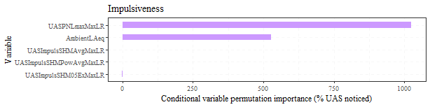

```r
par(mai=c(0,3,0,0))

# plot conditional importance
resultsOutImpuls.conimp <- arrange(resultsOutImpuls$conditional_permimp, desc(row_number()))

pBar <- ggplot(resultsOutImpuls.conimp) + geom_col(aes(x=factor(rownames(resultsOutImpuls.conimp), levels=rownames(resultsOutImpuls.conimp)), y=CondPermImp), fill=mycolours[6], width=0.5) + labs(x="Variable", y="Conditional variable permutation importance (% UAS noticed)") + ggtitle("Impulsiveness") + theme(text = element_text(family = "serif"), panel.grid=element_line(color = rgb(235, 235, 235, 100, maxColorValue = 255), linewidth = 0.25, linetype = 2)) + coord_flip()
pBar
```

```r
if (saveplots){
  ggsave(filename="PtANoticeImpulsConPermimp.svg", width=8, height=2, path=file.path(outFigPath, "svg"))
  unlink("PtANoticeImpulsConPermimp.svg")

  ggsave(filename="PtANoticeImpulsConPermimp.pdf", width=8, height=2, path=file.path(outFigPath, "pdf"))
  unlink("PtANoticeImpulsConPermimp.pdf")
}
```

Selected metric

```r
impulsVar <- "UASImpulsSHMAvgMaxLR"
```

#### SQM and loudness comparison

Now the highest importance SQMs are ranked against each other, controlling for UAS loudness and ambient LAeq.

##### Include tonal loudness

###### Set variables

```r
iVars <- c(absVar, ambVar, sharpVar, tonLdVar, fluctVar, roughVar, impulsVar)
dVar <- "NoticedPcFilt"

seeds <- c(70498, 4, 14986, 453, 864)
```

###### Hyperparameter tuning

```r
p <- mtryTune(dataIn=stimNoticeDataANum, iVars=iVars, dVar=dVar, seed=seeds[1:2],
             ntrees=ntrees, minsplit=minsplit, minbucket=minbucket)
```

| RMSE | Rsquared | MAE | mtry | iVars_mtry |
| --- | --- | --- | --- | --- |
| 20.79020 | 0.6230445 | 16.03632 | 3 | 2.25 |
| 18.01488 | 0.7337493 | 13.86319 | 5 | 1.25 |

| RMSE | Rsquared | MAE | mtry | iVars_mtry |
| --- | --- | --- | --- | --- |
| 20.25250 | 0.6481594 | 15.64407 | 3 | 2.25 |
| 18.04413 | 0.7318158 | 13.89445 | 5 | 1.25 |

| RMSE | Rsquared | MAE | mtry | iVars_mtry |
| --- | --- | --- | --- | --- |
| 20.53014 | 0.6360720 | 15.83615 | 3 | 2.25 |
| 18.33416 | 0.7222804 | 14.09868 | 5 | 1.25 |

| RMSE | Rsquared | MAE | mtry | iVars_mtry |
| --- | --- | --- | --- | --- |
| 20.52477 | 0.6368294 | 15.81765 | 3 | 2.25 |
| 18.30149 | 0.7235799 | 14.08669 | 5 | 1.25 |

| RMSE | Rsquared | MAE | mtry | iVars_mtry |
| --- | --- | --- | --- | --- |
| 20.49379 | 0.6390925 | 15.77475 | 3 | 2.25 |
| 18.55566 | 0.7139233 | 14.27883 | 5 | 1.25 |

| RMSE | Rsquared | MAE | mtry | iVars_mtry |
| --- | --- | --- | --- | --- |
| 20.50444 | 0.6381644 | 15.79203 | 3 | 2.25 |
| 18.47861 | 0.7170046 | 14.22768 | 5 | 1.25 |

| RMSE | Rsquared | MAE | mtry | iVars_mtry |
| --- | --- | --- | --- | --- |
| 20.50895 | 0.6382084 | 15.79165 | 3 | 2.25 |
| 18.47940 | 0.7173969 | 14.22495 | 5 | 1.25 |

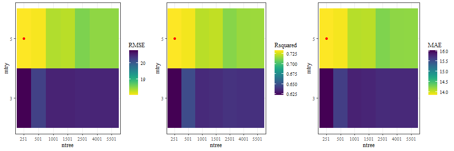

```r
p
```

Selected hyperparameters

```r
ntree <- 251
mtry <- as.integer(length(iVars)/1.25)
```

###### Run model

Train preliminary model

```r
nperm <- 5

resultsOutSQMs1 <- crfReg(dataIn=stimNoticeDataANum, iVars=iVars, dVar=dVar, seeds=seeds[1:2], ntree=ntree, mtry=mtry, permImpCondThres=permImpCondThres, nperm=nperm, minsplit=minsplit, minbucket=minbucket)

# print model prediction results
resultsOutSQMs1$OOB_RMSE
```

```
[1] 18.88386
```

```r
resultsOutSQMs1$OOB_MAE
```

```
[1] 14.50936
```

```r
resultsOutSQMs1$Rsquared
```

```
[1] 0.7014957
```

Train multiple seeds model

```r
resultsOutSQMs1 <- multi_crfReg(dataIn=stimNoticeDataANum, iVars=iVars, dVar=dVar, seeds=seeds, ntree=ntree, mtry=mtry, permImpCondThres=permImpCondThres, nperm=nperm, minsplit=minsplit, minbucket=minbucket)

# print model prediction results
resultsOutSQMs1$OOB_RMSE
```

```
[1] 18.76572
```

```r
resultsOutSQMs1$OOB_MAE
```

```
[1] 14.41058
```

```r
resultsOutSQMs1$Rsquared
```

```
[1] 0.7076868
```

```r
# store results
resNoticeFit['Abs SQMs inc tonal loud', 'RMSE'] <- resultsOutSQMs1$OOB_RMSE
resNoticeFit['Abs SQMs inc tonal loud', 'MAE'] <- resultsOutSQMs1$OOB_MAE
resNoticeFit['Abs SQMs inc tonal loud', 'Rsquared'] <- resultsOutSQMs1$Rsquared
resNoticePermImp$AbsSQMs1 <- resultsOutSQMs1$conditional_permimp
```

###### Plot results

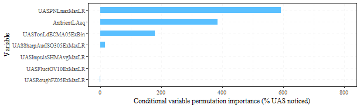

```r
par(mai=c(0,3,0,0))

# plot conditional importance
resultsOutSQMs1.conimp <- arrange(resultsOutSQMs1$conditional_permimp, desc(row_number()))

pBar <- ggplot(resultsOutSQMs1.conimp) + geom_col(aes(x=factor(rownames(resultsOutSQMs1.conimp), levels=rownames(resultsOutSQMs1.conimp)), y=CondPermImp), fill=mycolours[7], width=0.5) + labs(x="Variable", y="Conditional variable permutation importance (% UAS noticed)") + theme(text = element_text(family = "serif"), panel.grid=element_line(color = rgb(235, 235, 235, 100, maxColorValue = 255), linewidth = 0.25, linetype = 2)) + coord_flip(ylim=c(-1, 800))
pBar
```

```r
if (saveplots){
  ggsave(filename="PtANoticeAbsSQMsTonLdConPermimp.svg", width=8, height=2.4, path=file.path(outFigPath, "svg"))
  unlink("PtANoticeAbsSQMsTonLdConPermimp.svg")

  ggsave(filename="PtANoticeAbsSQMsTonLdConPermimp.pdf", width=8, height=2.4, path=file.path(outFigPath, "pdf"))
  unlink("PtANoticeAbsSQMsTonLdConPermimp.pdf")
}
```

##### Exclude tonal loudness

###### Set variables

```r
iVars <- c(absVar, ambVar, sharpVar, tonalVar, fluctVar, roughVar, impulsVar)
dVar <- "NoticedPcFilt"

seeds <- c(546, 57203, 270835, 60592, 8094)
```

###### Hyperparameter tuning

```r
p <- mtryTune(dataIn=stimNoticeDataANum, iVars=iVars, dVar=dVar, seed=seeds[1:2],
             ntrees=ntrees, minsplit=minsplit, minbucket=minbucket)
```

| RMSE | Rsquared | MAE | mtry | iVars_mtry |
| --- | --- | --- | --- | --- |
| 20.60072 | 0.6386702 | 15.62953 | 3 | 2.25 |
| 19.09968 | 0.6914357 | 14.67803 | 5 | 1.25 |

| RMSE | Rsquared | MAE | mtry | iVars_mtry |
| --- | --- | --- | --- | --- |
| 20.28158 | 0.6533047 | 15.45575 | 3 | 2.25 |
| 18.73408 | 0.7087952 | 14.39418 | 5 | 1.25 |

| RMSE | Rsquared | MAE | mtry | iVars_mtry |
| --- | --- | --- | --- | --- |
| 20.27383 | 0.6540617 | 15.51140 | 3 | 2.25 |
| 18.75499 | 0.7085575 | 14.40049 | 5 | 1.25 |

| RMSE | Rsquared | MAE | mtry | iVars_mtry |
| --- | --- | --- | --- | --- |
| 20.44451 | 0.6465294 | 15.64357 | 3 | 2.25 |
| 18.74893 | 0.7093060 | 14.41762 | 5 | 1.25 |

| RMSE | Rsquared | MAE | mtry | iVars_mtry |
| --- | --- | --- | --- | --- |
| 20.51253 | 0.6438595 | 15.69394 | 3 | 2.25 |
| 18.67566 | 0.7119405 | 14.36682 | 5 | 1.25 |

| RMSE | Rsquared | MAE | mtry | iVars_mtry |
| --- | --- | --- | --- | --- |
| 20.58804 | 0.6421026 | 15.75794 | 3 | 2.25 |
| 18.85912 | 0.7046624 | 14.47684 | 5 | 1.25 |

| RMSE | Rsquared | MAE | mtry | iVars_mtry |
| --- | --- | --- | --- | --- |
| 20.60449 | 0.6417073 | 15.77291 | 3 | 2.25 |
| 18.91455 | 0.7024118 | 14.50953 | 5 | 1.25 |

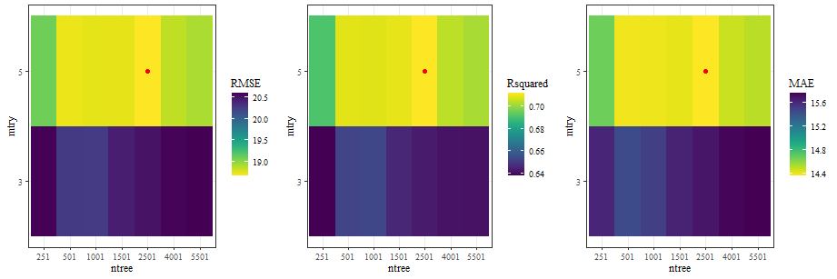

```r
p
```

Selected hyperparameters

```r
ntree <- 2501
mtry <- as.integer(length(iVars)/1.25)
```

###### Run model

Train preliminary model

```r
nperm <- 5

resultsOutSQMs2 <- crfReg(dataIn=stimNoticeDataANum, iVars=iVars, dVar=dVar, seeds=seeds[1:2], ntree=ntree, mtry=mtry, permImpCondThres=permImpCondThres, nperm=nperm, minsplit=minsplit, minbucket=minbucket)

# print model prediction results
resultsOutSQMs2$OOB_RMSE
```

```
[1] 18.88129
```

```r
resultsOutSQMs2$OOB_MAE
```

```
[1] 14.46072
```

```r
resultsOutSQMs2$Rsquared
```

```
[1] 0.7037345
```

Train multiple seeds model

```r
resultsOutSQMs2 <- multi_crfReg(dataIn=stimNoticeDataANum, iVars=iVars, dVar=dVar, seeds=seeds, ntree=ntree, mtry=mtry, permImpCondThres=permImpCondThres, nperm=nperm, minsplit=minsplit, minbucket=minbucket)

# print model prediction results
resultsOutSQMs2$OOB_RMSE
```

```
[1] 18.78148
```

```r
resultsOutSQMs2$OOB_MAE
```

```
[1] 14.40389
```

```r
resultsOutSQMs2$Rsquared
```

```
[1] 0.7078282
```

```r
# store results
resNoticeFit['Abs SQMs no tonal loud', 'RMSE'] <- resultsOutSQMs2$OOB_RMSE
resNoticeFit['Abs SQMs no tonal loud', 'RMSE'] <- resultsOutSQMs2$OOB_MAE
resNoticeFit['Abs SQMs no tonal loud', 'Rsquared'] <- resultsOutSQMs2$Rsquared
resNoticePermImp$AbsSQMs2 <- resultsOutSQMs2$conditional_permimp
```

###### Plot results

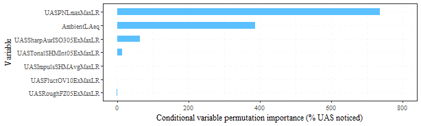

```r
par(mai=c(0,3,0,0))

# plot conditional importance
resultsOutSQMs2.conimp <- arrange(resultsOutSQMs2$conditional_permimp, desc(row_number()))

pBar <- ggplot(resultsOutSQMs2.conimp) + geom_col(aes(x=factor(rownames(resultsOutSQMs2.conimp), levels=rownames(resultsOutSQMs2.conimp)), y=CondPermImp), fill=mycolours[7], width=0.5) + labs(x="Variable", y="Conditional variable permutation importance (% UAS noticed)") + theme(text = element_text(family = "serif"), panel.grid=element_line(color = rgb(235, 235, 235, 100, maxColorValue = 255), linewidth = 0.25, linetype = 2)) + coord_flip(ylim=c(-1, 800))
pBar
```

```r
if (saveplots){
  ggsave(filename="PtANoticeAbsSQMsNoTonLdConPermimp.svg", width=8, height=2.4, path=file.path(outFigPath, "svg"))
  unlink("PtANoticeAbsSQMsNoTonLdConPermimp.svg")

  ggsave(filename="PtANoticeAbsSQMsNoTonLdConPermimp.pdf", width=8, height=2.4, path=file.path(outFigPath, "pdf"))
  unlink("PtANoticeAbsSQMsNoTonLdConPermimp.pdf")
}
```

### Difference variables

Next, the difference metrics are analysed

#### Set variables

```r
iVars <- c(names(stimNoticeDataANum)[which(colnames(stimNoticeDataANum)=="LAeqLAF90diff"):
                               which(colnames(stimNoticeDataANum)=="dImpulsSHM05ExMaxLR")], "SNRlevel")
dVar <- "NoticedPcFilt"

seeds <- c(568392, 498, 4089, 78132, 741809)
```

#### Hyperparameter tuning

```r
p <- mtryTune(dataIn=stimNoticeDataANum, iVars=iVars, dVar=dVar, seed=seeds[1:2],
             ntrees=ntrees, minsplit=minsplit, minbucket=minbucket)
```

| RMSE | Rsquared | MAE | mtry | iVars_mtry |
| --- | --- | --- | --- | --- |
| 10.43830 | 0.9113713 | 8.139813 | 4 | 10.50 |
| 10.07047 | 0.9156118 | 7.860926 | 9 | 5.25 |
| 10.31641 | 0.9093695 | 7.904535 | 14 | 3.50 |
| 10.25166 | 0.9095625 | 7.792184 | 18 | 2.75 |
| 10.44836 | 0.9043833 | 7.788456 | 23 | 2.25 |
| 10.54707 | 0.9025087 | 7.895773 | 29 | 1.75 |
| 10.65468 | 0.8995133 | 7.929826 | 34 | 1.50 |
| 10.74141 | 0.8976129 | 7.938837 | 41 | 1.25 |

| RMSE | Rsquared | MAE | mtry | iVars_mtry |
| --- | --- | --- | --- | --- |
| 10.24763 | 0.9157577 | 7.987113 | 4 | 10.50 |
| 10.10679 | 0.9144347 | 7.913682 | 9 | 5.25 |
| 10.18589 | 0.9114352 | 7.807852 | 14 | 3.50 |
| 10.25486 | 0.9093403 | 7.763168 | 18 | 2.75 |
| 10.44541 | 0.9049591 | 7.798595 | 23 | 2.25 |
| 10.52094 | 0.9030833 | 7.872568 | 29 | 1.75 |
| 10.72926 | 0.8979363 | 7.976406 | 34 | 1.50 |
| 10.71707 | 0.8978786 | 7.957363 | 41 | 1.25 |

| RMSE | Rsquared | MAE | mtry | iVars_mtry |
| --- | --- | --- | --- | --- |
| 10.14879 | 0.9170640 | 8.022363 | 4 | 10.50 |
| 10.06703 | 0.9149896 | 7.875183 | 9 | 5.25 |
| 10.18955 | 0.9114634 | 7.840866 | 14 | 3.50 |
| 10.25948 | 0.9091540 | 7.755396 | 18 | 2.75 |
| 10.46212 | 0.9047218 | 7.860236 | 23 | 2.25 |
| 10.53558 | 0.9027798 | 7.879279 | 29 | 1.75 |
| 10.71774 | 0.8981865 | 7.954754 | 34 | 1.50 |
| 10.73222 | 0.8976264 | 7.994973 | 41 | 1.25 |

| RMSE | Rsquared | MAE | mtry | iVars_mtry |
| --- | --- | --- | --- | --- |
| 10.14375 | 0.9174456 | 8.004243 | 4 | 10.50 |
| 10.09192 | 0.9144157 | 7.881295 | 9 | 5.25 |
| 10.18013 | 0.9114974 | 7.802573 | 14 | 3.50 |
| 10.24229 | 0.9092677 | 7.754695 | 18 | 2.75 |
| 10.47428 | 0.9044071 | 7.857631 | 23 | 2.25 |
| 10.50634 | 0.9034156 | 7.867976 | 29 | 1.75 |
| 10.62684 | 0.8998688 | 7.905435 | 34 | 1.50 |
| 10.70537 | 0.8981446 | 7.964127 | 41 | 1.25 |

| RMSE | Rsquared | MAE | mtry | iVars_mtry |
| --- | --- | --- | --- | --- |
| 10.13836 | 0.9177813 | 8.010855 | 4 | 10.50 |
| 10.09933 | 0.9143086 | 7.888460 | 9 | 5.25 |
| 10.18018 | 0.9114447 | 7.798209 | 14 | 3.50 |
| 10.28911 | 0.9085299 | 7.778374 | 18 | 2.75 |
| 10.40300 | 0.9059180 | 7.821114 | 23 | 2.25 |
| 10.49967 | 0.9034526 | 7.854975 | 29 | 1.75 |
| 10.61374 | 0.9003459 | 7.899135 | 34 | 1.50 |
| 10.70146 | 0.8981623 | 7.959491 | 41 | 1.25 |

| RMSE | Rsquared | MAE | mtry | iVars_mtry |
| --- | --- | --- | --- | --- |
| 10.13145 | 0.9179810 | 8.009167 | 4 | 10.50 |
| 10.10318 | 0.9144553 | 7.876962 | 9 | 5.25 |
| 10.14878 | 0.9120427 | 7.777722 | 14 | 3.50 |
| 10.26667 | 0.9090791 | 7.760059 | 18 | 2.75 |
| 10.40757 | 0.9056900 | 7.814613 | 23 | 2.25 |
| 10.49150 | 0.9035200 | 7.850080 | 29 | 1.75 |
| 10.60884 | 0.9004475 | 7.892993 | 34 | 1.50 |
| 10.71804 | 0.8977566 | 7.971276 | 41 | 1.25 |

| RMSE | Rsquared | MAE | mtry | iVars_mtry |
| --- | --- | --- | --- | --- |
| 10.12094 | 0.9180757 | 8.004675 | 4 | 10.50 |
| 10.09500 | 0.9146179 | 7.881932 | 9 | 5.25 |
| 10.15496 | 0.9119447 | 7.785519 | 14 | 3.50 |
| 10.26418 | 0.9092045 | 7.758170 | 18 | 2.75 |
| 10.40361 | 0.9057084 | 7.803935 | 23 | 2.25 |
| 10.50038 | 0.9032811 | 7.848159 | 29 | 1.75 |
| 10.61681 | 0.9003592 | 7.913501 | 34 | 1.50 |
| 10.73584 | 0.8974579 | 7.980198 | 41 | 1.25 |

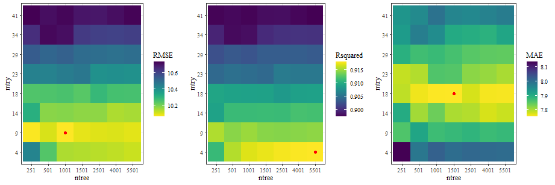

```r
p
```

Selected hyperparameters

```r
ntree <- 1501
mtry <- as.integer(length(iVars)/2.75)
```

#### Run model

Train preliminary model

```r
nperm <- 30

resultsOutDiffs <- crfReg(dataIn=stimNoticeDataANum, iVars=iVars, dVar=dVar, seeds=seeds[1:2], ntree=ntree, mtry=mtry, permImpCondThres=permImpCondThres, nperm=nperm, minsplit=minsplit, minbucket=minbucket)

# print model prediction results
resultsOutDiffs$OOB_RMSE
```

```
[1] 10.3063
```

```r
resultsOutDiffs$OOB_MAE
```

```
[1] 7.800711
```

```r
resultsOutDiffs$Rsquared
```

```
[1] 0.9083321
```

Train multiple seeds model

```r
resultsOutDiffs <- multi_crfReg(dataIn=stimNoticeDataANum, iVars=iVars, dVar=dVar, seeds=seeds, ntree=ntree, mtry=mtry, permImpCondThres=permImpCondThres, nperm=nperm, minsplit=minsplit, minbucket=minbucket)

# print model prediction results
resultsOutDiffs$OOB_RMSE
```

```
[1] 10.28475
```

```r
resultsOutDiffs$OOB_MAE
```

```
[1] 7.789012
```

```r
resultsOutDiffs$Rsquared
```

```
[1] 0.9088519
```

```r
# store results
resNoticeFit['Diff vars', 'RMSE'] <- resultsOutDiffs$OOB_RMSE
resNoticeFit['Diff vars', 'MAE'] <- resultsOutDiffs$OOB_MAE
resNoticeFit['Diff vars', 'Rsquared'] <- resultsOutDiffs$Rsquared
resNoticePermImp$DiffVars <- resultsOutDiffs$conditional_permimp
```

#### Plot results

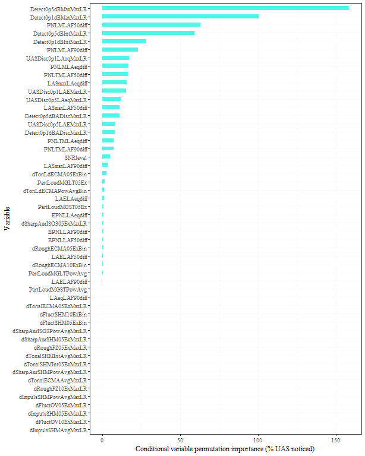

```r
par(mai=c(0,3,0,0))

# plot conditional importance
resultsOutDiffs.conimp <- arrange(resultsOutDiffs$conditional_permimp, desc(row_number()))

pBar <- ggplot(resultsOutDiffs.conimp) + geom_col(aes(x=factor(rownames(resultsOutDiffs.conimp), levels=rownames(resultsOutDiffs.conimp)), y=CondPermImp), fill=mycolours[8], width=0.5) + labs(x="Variable", y="Conditional variable permutation importance (% UAS noticed)") + theme(text = element_text(family = "serif"), panel.grid=element_line(color = rgb(235, 235, 235, 100, maxColorValue = 255), linewidth = 0.25, linetype = 2)) + coord_flip()
pBar
```

```r
if (saveplots){
  ggsave(filename="PtANoticeDiffVarsConPermimp.svg", width=8, height=10, path=file.path(outFigPath, "svg"))
  unlink("PtANoticeDiffVarsConPermimp.svg")

  ggsave(filename="PtANoticeDiffVarsConPermimp.pdf", width=8, height=10, path=file.path(outFigPath, "pdf"))
  unlink("PtANoticeDiffVarsConPermimp.pdf")
}
```

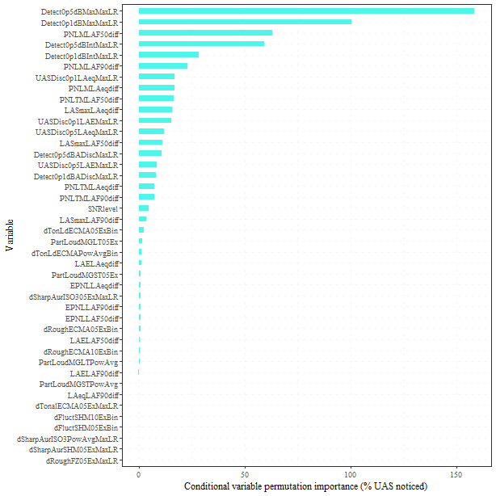

```r
# Plot only positive values
resultsOutDiffs.conimpPtv <- resultsOutDiffs.conimp |>
                                        rownames_to_column('Metric') |>
                                            filter_if(is.numeric, all_vars(. > 0)) |>
                                                  column_to_rownames('Metric')

pBar <- ggplot(resultsOutDiffs.conimpPtv) + geom_col(aes(x=factor(rownames(resultsOutDiffs.conimpPtv), levels=rownames(resultsOutDiffs.conimpPtv)), y=CondPermImp), fill=mycolours[8], width=0.5) + labs(x="Variable", y="Conditional variable permutation importance (% UAS noticed)") + theme(text = element_text(family = "serif"), panel.grid=element_line(color = rgb(235, 235, 235, 100, maxColorValue = 255), linewidth = 0.25, linetype = 2)) + coord_flip()
pBar
```

```r
if (saveplots){
  ggsave(filename="PtANoticeDiffVarsConPermimpPtv.svg", width=8, height=8, path=file.path(outFigPath, "svg"))
  unlink("PtANoticeDiffVarsConPermimpPtv.svg")

  ggsave(filename="PtANoticeDiffVarsConPermimpPtv.pdf", width=8, height=8, path=file.path(outFigPath, "pdf"))
  unlink("PtANoticeDiffVarsConPermimpPtv.pdf")
}
```

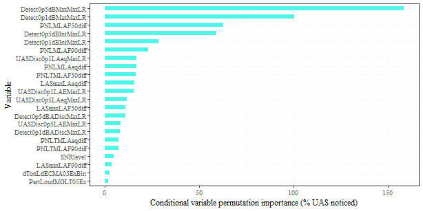

```r
# Plot only value within 1% of the maximum
resultsOutDiffs.conimp1pc <- resultsOutDiffs.conimp |>
                                        rownames_to_column('Metric') |>
                                            filter_if(is.numeric, all_vars(. > max(resultsOutDiffs.conimp)/100)) |>
                                                  column_to_rownames('Metric')

pBar <- ggplot(resultsOutDiffs.conimp1pc) + geom_col(aes(x=factor(rownames(resultsOutDiffs.conimp1pc), levels=rownames(resultsOutDiffs.conimp1pc)), y=CondPermImp), fill=mycolours[8], width=0.5) + labs(x="Variable", y="Conditional variable permutation importance (% UAS noticed)") + theme(text = element_text(family = "serif"), panel.grid=element_line(color = rgb(235, 235, 235, 100, maxColorValue = 255), linewidth = 0.25, linetype = 2)) + coord_flip()
pBar
```

```r
if (saveplots){
  ggsave(filename="PtANoticeDiffVarsConPermimp1pc.svg", width=8, height=4, path=file.path(outFigPath, "svg"))
  unlink("PtANoticeDiffVarsConPermimp1pc.svg")

  ggsave(filename="PtANoticeDiffVarsConPermimp1pc.pdf", width=8, height=4, path=file.path(outFigPath, "pdf"))
  unlink("PtANoticeDiffVarsConPermimp1pc.pdf")
}
```

Selected metric

```r
diffVar <- "Detect0p5dBMaxMaxLR"
```

### dSQM analysis

The ambient-only stimuli are NOT replaced here, as the difference analysis includes dB metrics.

#### Individual SQMs

##### dSharpness

###### Set variables

```r
iVars <- c(diffVar, "dSharpAurISO3PowAvgMaxLR", "dSharpAurISO305ExMaxLR", "dSharpAurSHMPowAvgMaxLR", "dSharpAurSHM05ExMaxLR")
dVar <- "NoticedPcFilt"

seeds <- c(84194, 905, 928054, 625091, 582031)
```

###### Hyperparameter tuning

```r
p <- mtryTune(dataIn=stimNoticeDataANum, iVars=iVars, dVar=dVar, seed=seeds[1:2],
             ntrees=ntrees, minsplit=minsplit, minbucket=minbucket)
```

| RMSE | Rsquared | MAE | mtry | iVars_mtry |
| --- | --- | --- | --- | --- |
| 10.76582 | 0.8981038 | 8.236438 | 3 | 1.50 |
| 10.41302 | 0.9044251 | 8.122566 | 4 | 1.25 |

| RMSE | Rsquared | MAE | mtry | iVars_mtry |
| --- | --- | --- | --- | --- |
| 10.70672 | 0.8996641 | 8.285576 | 3 | 1.50 |
| 10.50941 | 0.9019210 | 8.187866 | 4 | 1.25 |

| RMSE | Rsquared | MAE | mtry | iVars_mtry |
| --- | --- | --- | --- | --- |
| 10.67970 | 0.9001803 | 8.269102 | 3 | 1.50 |
| 10.49302 | 0.9024537 | 8.193670 | 4 | 1.25 |

| RMSE | Rsquared | MAE | mtry | iVars_mtry |
| --- | --- | --- | --- | --- |
| 10.63375 | 0.901449 | 8.260839 | 3 | 1.50 |
| 10.47413 | 0.902876 | 8.194192 | 4 | 1.25 |

| RMSE | Rsquared | MAE | mtry | iVars_mtry |
| --- | --- | --- | --- | --- |
| 10.58909 | 0.9021545 | 8.217720 | 3 | 1.50 |
| 10.46221 | 0.9029483 | 8.168009 | 4 | 1.25 |

| RMSE | Rsquared | MAE | mtry | iVars_mtry |
| --- | --- | --- | --- | --- |
| 10.57260 | 0.9023574 | 8.198951 | 3 | 1.50 |
| 10.44878 | 0.9032325 | 8.158743 | 4 | 1.25 |

| RMSE | Rsquared | MAE | mtry | iVars_mtry |
| --- | --- | --- | --- | --- |
| 10.57670 | 0.9022942 | 8.191387 | 3 | 1.50 |
| 10.45225 | 0.9032596 | 8.161372 | 4 | 1.25 |

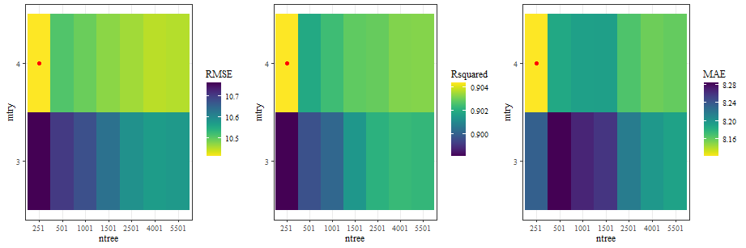

```r
p
```

Selected hyperparameters

```r
ntree <- 251
mtry <- as.integer(length(iVars)/1.25)
```

###### Run model

Train preliminary model

```r
nperm <- 5

resultsOutSharp <- crfReg(dataIn=stimNoticeDataANum, iVars=iVars, dVar=dVar, seeds=seeds[1:2], ntree=ntree, mtry=mtry, permImpCondThres=permImpCondThres, nperm=nperm, minsplit=minsplit, minbucket=minbucket)

# print model prediction results
resultsOutSharp$OOB_RMSE
```

```
[1] 10.48167
```

```r
resultsOutSharp$OOB_MAE
```

```
[1] 8.238206
```

```r
resultsOutSharp$Rsquared
```

```
[1] 0.9036468
```

Train multiple seeds model

```r
resultsOutSharp <- multi_crfReg(dataIn=stimNoticeDataANum, iVars=iVars, dVar=dVar, seeds=seeds, ntree=ntree, mtry=mtry, permImpCondThres=permImpCondThres, nperm=nperm, minsplit=minsplit, minbucket=minbucket)

# print model prediction results
resultsOutSharp$OOB_RMSE
```

```
[1] 10.42312
```

```r
resultsOutSharp$OOB_MAE
```

```
[1] 8.175198
```

```r
resultsOutSharp$Rsquared
```

```
[1] 0.9039029
```

```r
# store results
resNoticeFit['Diff sharp', 'RMSE'] <- resultsOutSharp$OOB_RMSE
resNoticeFit['Diff sharp', 'MAE'] <- resultsOutSharp$OOB_MAE
resNoticeFit['Diff sharp', 'Rsquared'] <- resultsOutSharp$Rsquared
resNoticePermImp$DiffSharp <- resultsOutSharp$conditional_permimp
```

###### Plot results

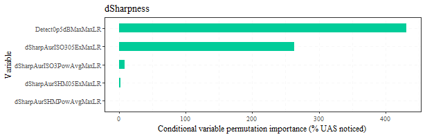

```r
par(mai=c(0,3,0,0))

# plot conditional importance
resultsOutSharp.conimp <- arrange(resultsOutSharp$conditional_permimp, desc(row_number()))

pBar <- ggplot(resultsOutSharp.conimp) + geom_col(aes(x=factor(rownames(resultsOutSharp.conimp), levels=rownames(resultsOutSharp.conimp)), y=CondPermImp), fill=mycolours[2], width=0.5) + labs(x="Variable", y="Conditional variable permutation importance (% UAS noticed)") + ggtitle("dSharpness") + theme(text = element_text(family = "serif"), panel.grid=element_line(color = rgb(235, 235, 235, 100, maxColorValue = 255), linewidth = 0.25, linetype = 2)) + coord_flip()
pBar
```

```r
if (saveplots){
  ggsave(filename="PtANoticedSharpConPermimp.svg", width=8, height=2.6, path=file.path(outFigPath, "svg"))
  unlink("PtANoticedSharpConPermimp.svg")

  ggsave(filename="PtANoticedSharpConPermimp.pdf", width=8, height=2.6, path=file.path(outFigPath, "pdf"))
  unlink("PtANoticedSharpConPermimp.pdf")
}
```

Selected metric

```r
dSharpVar <- "dSharpAurISO305ExMaxLR"
```

##### dTonal loudness and dtonality

###### Set variables

```r
iVars <- c(diffVar, "dTonalECMAAvgMaxLR", "dTonalSHMInt05ExMaxLR", "dTonalSHMIntAvgMaxLR", "dTonalECMA05ExMaxLR", "dTonLdECMAPowAvgBin", "dTonLdECMA05ExBin")
dVar <- "NoticedPcFilt"

seeds <- c(561684, 104798, 1536, 48, 48561)
```

###### Hyperparameter tuning

```r
p <- mtryTune(dataIn=stimNoticeDataANum, iVars=iVars, dVar=dVar, seed=seeds[1:2],
             ntrees=ntrees, minsplit=minsplit, minbucket=minbucket)
```

| RMSE | Rsquared | MAE | mtry | iVars_mtry |
| --- | --- | --- | --- | --- |
| 11.17443 | 0.8902660 | 8.502129 | 3 | 2.25 |
| 10.49671 | 0.9020946 | 7.997447 | 5 | 1.25 |

| RMSE | Rsquared | MAE | mtry | iVars_mtry |
| --- | --- | --- | --- | --- |
| 11.24817 | 0.8887063 | 8.537473 | 3 | 2.25 |
| 10.52019 | 0.9013672 | 8.022772 | 5 | 1.25 |

| RMSE | Rsquared | MAE | mtry | iVars_mtry |
| --- | --- | --- | --- | --- |
| 11.25454 | 0.8889022 | 8.559526 | 3 | 2.25 |
| 10.44008 | 0.9026471 | 7.963577 | 5 | 1.25 |

| RMSE | Rsquared | MAE | mtry | iVars_mtry |
| --- | --- | --- | --- | --- |
| 11.24174 | 0.8895771 | 8.550595 | 3 | 2.25 |
| 10.42837 | 0.9029068 | 7.969944 | 5 | 1.25 |

| RMSE | Rsquared | MAE | mtry | iVars_mtry |
| --- | --- | --- | --- | --- |
| 11.18875 | 0.8904578 | 8.515439 | 3 | 2.25 |
| 10.46994 | 0.9021703 | 8.007881 | 5 | 1.25 |

| RMSE | Rsquared | MAE | mtry | iVars_mtry |
| --- | --- | --- | --- | --- |
| 11.20961 | 0.8899602 | 8.529204 | 3 | 2.25 |
| 10.47291 | 0.9022210 | 8.004817 | 5 | 1.25 |

| RMSE | Rsquared | MAE | mtry | iVars_mtry |
| --- | --- | --- | --- | --- |
| 11.20867 | 0.8898712 | 8.524190 | 3 | 2.25 |
| 10.46392 | 0.9023377 | 8.002585 | 5 | 1.25 |

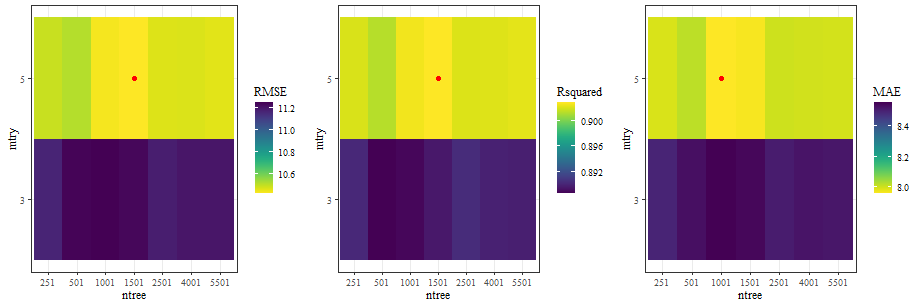

```r
p
```

Selected hyperparameters

```r
ntree <-1501
mtry <- as.integer(length(iVars)/1.25)
```

###### Run model

Train preliminary model

```r
# Tonality with tonal loudness

nperm <- 5

resultsOutTonal1 <- crfReg(dataIn=stimNoticeDataANum, iVars=iVars, dVar=dVar, seeds=seeds[1:2], ntree=ntree, mtry=mtry, permImpCondThres=permImpCondThres, nperm=nperm, minsplit=minsplit, minbucket=minbucket)

# print model prediction results
resultsOutTonal1$OOB_RMSE
```

```
[1] 10.46408
```

```r
resultsOutTonal1$OOB_MAE
```

```
[1] 8.013044
```

```r
resultsOutTonal1$Rsquared
```

```
[1] 0.9021881
```

Train multiple seeds model

```r
# Tonality with tonal loudness

resultsOutTonal1 <- multi_crfReg(dataIn=stimNoticeDataANum, iVars=iVars, dVar=dVar, seeds=seeds, ntree=ntree, mtry=mtry, permImpCondThres=permImpCondThres, nperm=nperm, minsplit=minsplit, minbucket=minbucket)

# print model prediction results
resultsOutTonal1$OOB_RMSE
```

```
[1] 10.45256
```

```r
resultsOutTonal1$OOB_MAE
```

```
[1] 8.001321
```

```r
resultsOutTonal1$Rsquared
```

```
[1] 0.9026108
```

```r
# store results
resNoticeFit['Diff tonal inc loud', 'RMSE'] <- resultsOutTonal1$OOB_RMSE
resNoticeFit['Diff tonal inc loud', 'MAE'] <- resultsOutTonal1$OOB_MAE
resNoticeFit['Diff tonal inc loud', 'Rsquared'] <- resultsOutTonal1$Rsquared
resNoticePermImp$DiffTonal1 <- resultsOutTonal1$conditional_permimp
```

###### Plot results

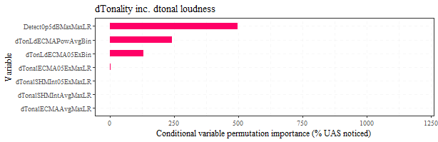

```r
par(mai=c(0,3,0,0))

# plot conditional importance
resultsOutTonal1.conimp <- arrange(resultsOutTonal1$conditional_permimp, desc(row_number()))

pBar <- ggplot(resultsOutTonal1.conimp) + geom_col(aes(x=factor(rownames(resultsOutTonal1.conimp), levels=rownames(resultsOutTonal1.conimp)), y=CondPermImp), fill=mycolours[3], width=0.5) + labs(x="Variable", y="Conditional variable permutation importance (% UAS noticed)") + ggtitle("dTonality inc. dtonal loudness") + theme(text = element_text(family = "serif"), panel.grid=element_line(color = rgb(235, 235, 235, 100, maxColorValue = 255), linewidth = 0.25, linetype = 2)) + coord_flip(ylim=c(0, 1200))
pBar
```

```r
if (saveplots){
  ggsave(filename="PtANoticedTonalLdConPermimp.svg", width=8, height=2.6, path=file.path(outFigPath, "svg"))
  unlink("PtANoticedTonalLdConPermimp.svg")

  ggsave(filename="PtANoticedTonalLdConPermimp.pdf", width=8, height=2.6, path=file.path(outFigPath, "pdf"))
  unlink("PtANoticedTonalLdConPermimp.pdf")
}
```

Selected metric

```r
dTonLdVar <- "dTonLdECMAPowAvgBin"
```

##### dTonality without dtonal loudness

###### Set variables

```r
iVars <- c(diffVar, "dTonalECMAAvgMaxLR", "dTonalSHMInt05ExMaxLR", "dTonalSHMIntAvgMaxLR", "dTonalECMA05ExMaxLR")
dVar <- "NoticedPcFilt"

seeds <- c(410865, 2954, 70812, 203, 7984)
```

###### Hyperparameter tuning

```r
p <- mtryTune(dataIn=stimNoticeDataANum, iVars=iVars, dVar=dVar, seed=seeds[1:2],
             ntrees=ntrees, minsplit=minsplit, minbucket=minbucket)
```

| RMSE | Rsquared | MAE | mtry | iVars_mtry |
| --- | --- | --- | --- | --- |
| 13.79724 | 0.8314529 | 10.738103 | 3 | 1.50 |
| 12.73339 | 0.8574975 | 9.963414 | 4 | 1.25 |

| RMSE | Rsquared | MAE | mtry | iVars_mtry |
| --- | --- | --- | --- | --- |
| 13.83639 | 0.8311177 | 10.789030 | 3 | 1.50 |
| 12.64800 | 0.8596587 | 9.903869 | 4 | 1.25 |

| RMSE | Rsquared | MAE | mtry | iVars_mtry |
| --- | --- | --- | --- | --- |
| 13.93662 | 0.8286167 | 10.86704 | 3 | 1.50 |
| 12.55105 | 0.8606810 | 9.81632 | 4 | 1.25 |

| RMSE | Rsquared | MAE | mtry | iVars_mtry |
| --- | --- | --- | --- | --- |
| 13.95723 | 0.8282971 | 10.895850 | 3 | 1.50 |
| 12.52399 | 0.8613239 | 9.797458 | 4 | 1.25 |

| RMSE | Rsquared | MAE | mtry | iVars_mtry |
| --- | --- | --- | --- | --- |
| 13.92965 | 0.8289796 | 10.874916 | 3 | 1.50 |
| 12.55567 | 0.8603939 | 9.810792 | 4 | 1.25 |

| RMSE | Rsquared | MAE | mtry | iVars_mtry |
| --- | --- | --- | --- | --- |
| 13.90876 | 0.8296225 | 10.852519 | 3 | 1.50 |
| 12.56904 | 0.8600952 | 9.814253 | 4 | 1.25 |

| RMSE | Rsquared | MAE | mtry | iVars_mtry |
| --- | --- | --- | --- | --- |
| 13.95371 | 0.8285669 | 10.889648 | 3 | 1.50 |
| 12.57083 | 0.8599262 | 9.811642 | 4 | 1.25 |

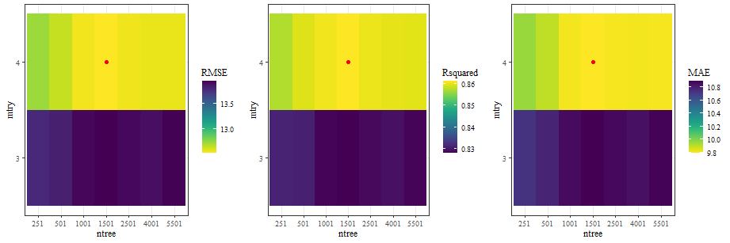

```r
p
```

Selected hyperparameters

```r
ntree <- 1501
mtry <- as.integer(length(iVars)/1.25)
```

###### Run model

Train preliminary model

```r
# Tonality

nperm <- 5

resultsOutTonal2 <- crfReg(dataIn=stimNoticeDataANum, iVars=iVars, dVar=dVar, seeds=seeds[1:2], ntree=ntree, mtry=mtry, permImpCondThres=permImpCondThres, nperm=nperm, minsplit=minsplit, minbucket=minbucket)

# print model prediction results
resultsOutTonal2$OOB_RMSE
```

```
[1] 12.53815
```

```r
resultsOutTonal2$OOB_MAE
```

```
[1] 9.798852
```

```r
resultsOutTonal2$Rsquared
```

```
[1] 0.8608015
```

Train multiple seeds model

```r
# Tonality

resultsOutTonal2 <- multi_crfReg(dataIn=stimNoticeDataANum, iVars=iVars, dVar=dVar, seeds=seeds, ntree=ntree, mtry=mtry, permImpCondThres=permImpCondThres, nperm=nperm, minsplit=minsplit, minbucket=minbucket)

# print model prediction results
resultsOutTonal2$OOB_RMSE
```

```
[1] 12.57501
```

```r
resultsOutTonal2$OOB_MAE
```

```
[1] 9.807799
```

```r
resultsOutTonal2$Rsquared
```

```
[1] 0.8595653
```

```r
# store results
resNoticeFit['Diff tonal no loud', 'RMSE'] <- resultsOutTonal2$OOB_RMSE
resNoticeFit['Diff tonal no loud', 'MAE'] <- resultsOutTonal2$OOB_MAE
resNoticeFit['Diff tonal no loud', 'Rsquared'] <- resultsOutTonal2$Rsquared
resNoticePermImp$DiffTonal2 <- resultsOutTonal2$conditional_permimp
```

###### Plot results

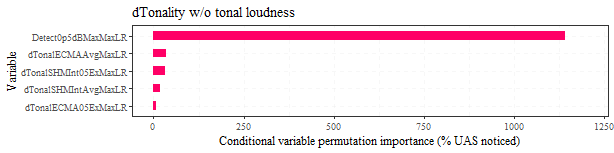

```r
par(mai=c(0,3,0,0))

# plot conditional importance
resultsOutTonal2.conimp <- arrange(resultsOutTonal2$conditional_permimp, desc(row_number()))

pBar <- ggplot(resultsOutTonal2.conimp) + geom_col(aes(x=factor(rownames(resultsOutTonal2.conimp), levels=rownames(resultsOutTonal2.conimp)), y=CondPermImp), fill=mycolours[3], width=0.5) + labs(x="Variable", y="Conditional variable permutation importance (% UAS noticed)") + ggtitle("dTonality w/o tonal loudness") + theme(text = element_text(family = "serif"), panel.grid=element_line(color = rgb(235, 235, 235, 100, maxColorValue = 255), linewidth = 0.25, linetype = 2)) + coord_flip(ylim=c(0, 1200))
pBar
```

```r
if (saveplots){
  ggsave(filename="PtANoticedTonalConPermimp.svg", width=8, height=2, path=file.path(outFigPath, "svg"))
  unlink("PtANoticedTonalConPermimp.svg")

  ggsave(filename="PtANoticedTonalConPermimp.pdf", width=8, height=2, path=file.path(outFigPath, "pdf"))
  unlink("PtANoticedTonalConPermimp.pdf")
}
```

Selected metric

```r
dTonalVar <- "dTonalECMAAvgMaxLR"
```

##### dFluctuation strength

###### Set variables

```r
# Fluctuation strength
iVars <- c(diffVar, "dFluctSHM10ExBin", "dFluctSHM05ExBin", "dFluctOV10ExMaxLR", "dFluctOV05ExMaxLR")
dVar <- "NoticedPcFilt"

seeds <- c(418657, 84, 1630, 18659, 3687)
```

###### Hyperparameter tuning

```r
p <- mtryTune(dataIn=stimNoticeDataANum, iVars=iVars, dVar=dVar, seed=seeds[1:2],
             ntrees=ntrees, minsplit=minsplit, minbucket=minbucket)
```

| RMSE | Rsquared | MAE | mtry | iVars_mtry |
| --- | --- | --- | --- | --- |
| 11.85156 | 0.8767652 | 9.250235 | 3 | 1.50 |
| 11.46461 | 0.8831110 | 8.913091 | 4 | 1.25 |

| RMSE | Rsquared | MAE | mtry | iVars_mtry |
| --- | --- | --- | --- | --- |
| 11.71474 | 0.8798875 | 9.141552 | 3 | 1.50 |
| 11.42416 | 0.8841686 | 8.897586 | 4 | 1.25 |

| RMSE | Rsquared | MAE | mtry | iVars_mtry |
| --- | --- | --- | --- | --- |
| 11.62336 | 0.8814737 | 9.095730 | 3 | 1.50 |
| 11.38894 | 0.8845120 | 8.855331 | 4 | 1.25 |

| RMSE | Rsquared | MAE | mtry | iVars_mtry |
| --- | --- | --- | --- | --- |
| 11.64336 | 0.8809086 | 9.115302 | 3 | 1.50 |
| 11.38312 | 0.8847470 | 8.835064 | 4 | 1.25 |

| RMSE | Rsquared | MAE | mtry | iVars_mtry |
| --- | --- | --- | --- | --- |
| 11.64020 | 0.8813341 | 9.115125 | 3 | 1.50 |
| 11.38853 | 0.8846558 | 8.831799 | 4 | 1.25 |

| RMSE | Rsquared | MAE | mtry | iVars_mtry |
| --- | --- | --- | --- | --- |
| 11.64211 | 0.8815073 | 9.117321 | 3 | 1.50 |
| 11.42329 | 0.8840050 | 8.870163 | 4 | 1.25 |

| RMSE | Rsquared | MAE | mtry | iVars_mtry |
| --- | --- | --- | --- | --- |
| 11.63939 | 0.8815984 | 9.113641 | 3 | 1.50 |
| 11.43611 | 0.8838443 | 8.884033 | 4 | 1.25 |

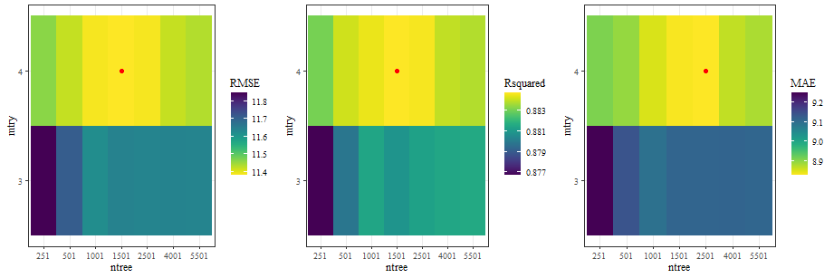

```r
p
```

Selected hyperparameters

```r
ntree <- 1501
mtry <- as.integer(length(iVars)/1.25)
```

###### Run model

Train preliminary model

```r
nperm <- 5

resultsOutFluct <- crfReg(dataIn=stimNoticeDataANum, iVars=iVars, dVar=dVar, seeds=seeds[1:2], ntree=ntree, mtry=mtry, permImpCondThres=permImpCondThres, nperm=nperm, minsplit=minsplit, minbucket=minbucket)

# print model prediction results
resultsOutFluct$OOB_RMSE
```

```
[1] 11.38464
```

```r
resultsOutFluct$OOB_MAE
```

```
[1] 8.885649
```

```r
resultsOutFluct$Rsquared
```

```
[1] 0.8846925
```

Train multiple seeds model

```r
resultsOutFluct <- multi_crfReg(dataIn=stimNoticeDataANum, iVars=iVars, dVar=dVar, seeds=seeds, ntree=ntree, mtry=mtry, permImpCondThres=permImpCondThres, nperm=nperm, minsplit=minsplit, minbucket=minbucket)

# print model prediction results
resultsOutFluct$OOB_RMSE
```

```
[1] 11.39714
```

```r
resultsOutFluct$OOB_MAE
```

```
[1] 8.868102
```

```r
resultsOutFluct$Rsquared
```

```
[1] 0.8843449
```

```r
# store results
resNoticeFit['Diff fluct', 'RMSE'] <- resultsOutFluct$OOB_RMSE
resNoticeFit['Diff fluct', 'MAE'] <- resultsOutFluct$OOB_MAE
resNoticeFit['Diff fluct', 'Rsquared'] <- resultsOutFluct$Rsquared
resNoticePermImp$DiffFluct <- resultsOutFluct$conditional_permimp
```

###### Plot results

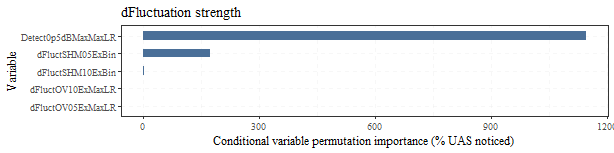

```r
par(mai=c(0,3,0,0))

# plot conditional importance
resultsOutFluct.conimp <- arrange(resultsOutFluct$conditional_permimp, desc(row_number()))

pBar <- ggplot(resultsOutFluct.conimp) + geom_col(aes(x=factor(rownames(resultsOutFluct.conimp), levels=rownames(resultsOutFluct.conimp)), y=CondPermImp), fill=mycolours[4], width=0.5) + labs(x="Variable", y="Conditional variable permutation importance (% UAS noticed)") + ggtitle("dFluctuation strength") + theme(text = element_text(family = "serif"), panel.grid=element_line(color = rgb(235, 235, 235, 100, maxColorValue = 255), linewidth = 0.25, linetype = 2)) + coord_flip()
pBar
```

```r
if (saveplots){
  ggsave(filename="PtANoticedFluctConPermimp.svg", width=8, height=2, path=file.path(outFigPath, "svg"))
  unlink("PtANoticeFluctConPermimp.svg")

  ggsave(filename="PtANoticedFluctConPermimp.pdf", width=8, height=2, path=file.path(outFigPath, "pdf"))
  unlink("PtANoticeFluctConPermimp.pdf")
}
```

Selected metric

```r
dFluctVar <- "dFluctSHM05ExBin"
```

##### dRoughness

###### Set variables

```r
# Roughness
iVars <- c(diffVar, "dRoughECMA10ExBin", "dRoughECMA05ExBin", "dRoughFZ10ExMaxLR", "dRoughFZ05ExMaxLR")
dVar <- "NoticedPcFilt"

seeds <- c(69851, 85109, 410986, 1563, 896)
```

###### Hyperparameter tuning

```r
p <- mtryTune(dataIn=stimNoticeDataANum, iVars=iVars, dVar=dVar, seed=seeds[1:2],
             ntrees=ntrees, minsplit=minsplit, minbucket=minbucket)
```

| RMSE | Rsquared | MAE | mtry | iVars_mtry |
| --- | --- | --- | --- | --- |
| 14.87585 | 0.8333240 | 12.24410 | 3 | 1.50 |
| 12.49287 | 0.8722879 | 10.04548 | 4 | 1.25 |

| RMSE | Rsquared | MAE | mtry | iVars_mtry |
| --- | --- | --- | --- | --- |
| 14.71452 | 0.8386646 | 12.125144 | 3 | 1.50 |
| 12.45301 | 0.8718641 | 9.996656 | 4 | 1.25 |

| RMSE | Rsquared | MAE | mtry | iVars_mtry |
| --- | --- | --- | --- | --- |
| 14.31673 | 0.8459283 | 11.797281 | 3 | 1.50 |
| 12.38230 | 0.8728405 | 9.888166 | 4 | 1.25 |

| RMSE | Rsquared | MAE | mtry | iVars_mtry |
| --- | --- | --- | --- | --- |
| 14.30910 | 0.8466714 | 11.832726 | 3 | 1.50 |
| 12.38018 | 0.8726371 | 9.894103 | 4 | 1.25 |

| RMSE | Rsquared | MAE | mtry | iVars_mtry |
| --- | --- | --- | --- | --- |
| 14.37885 | 0.8444568 | 11.897407 | 3 | 1.50 |
| 12.37963 | 0.8721338 | 9.885585 | 4 | 1.25 |

| RMSE | Rsquared | MAE | mtry | iVars_mtry |
| --- | --- | --- | --- | --- |
| 14.28225 | 0.8459804 | 11.817919 | 3 | 1.50 |
| 12.39218 | 0.8718297 | 9.893619 | 4 | 1.25 |

| RMSE | Rsquared | MAE | mtry | iVars_mtry |
| --- | --- | --- | --- | --- |
| 14.20548 | 0.8473532 | 11.753012 | 3 | 1.50 |
| 12.38858 | 0.8719177 | 9.888889 | 4 | 1.25 |

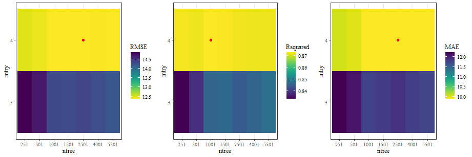

```r
p
```

Selected hyperparameters

```r
ntree <- 2501
mtry <- as.integer(length(iVars)/1.25)
```

###### Run model

Train preliminary model

```r
nperm <- 5

resultsOutRough <- crfReg(dataIn=stimNoticeDataANum, iVars=iVars, dVar=dVar, seeds=seeds[1:2], ntree=ntree, mtry=mtry, permImpCondThres=permImpCondThres, nperm=nperm, minsplit=minsplit, minbucket=minbucket)

# print model prediction results
resultsOutRough$OOB_RMSE
```

```
[1] 12.37658
```

```r
resultsOutRough$OOB_MAE
```

```
[1] 9.87597
```

```r
resultsOutRough$Rsquared
```

```
[1] 0.8723291
```

Train multiple seeds model

```r
resultsOutRough <- multi_crfReg(dataIn=stimNoticeDataANum, iVars=iVars, dVar=dVar, seeds=seeds, ntree=ntree, mtry=mtry, permImpCondThres=permImpCondThres, nperm=nperm, minsplit=minsplit, minbucket=minbucket)

# print model prediction results
resultsOutRough$OOB_RMSE
```

```
[1] 12.37394
```

```r
resultsOutRough$OOB_MAE
```

```
[1] 9.849881
```

```r
resultsOutRough$Rsquared
```

```
[1] 0.8718619
```

```r
# store results
resNoticeFit['Diff rough', 'RMSE'] <- resultsOutRough$OOB_RMSE
resNoticeFit['Diff rough', 'MAE'] <- resultsOutRough$OOB_MAE
resNoticeFit['Diff rough', 'Rsquared'] <- resultsOutRough$Rsquared
resNoticePermImp$DiffRough <- resultsOutRough$conditional_permimp
```

###### Plot results

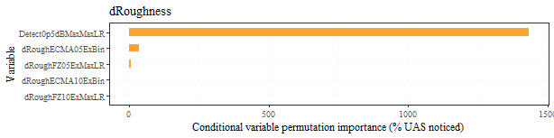

```r
par(mai=c(0,3,0,0))

# plot conditional importance
resultsOutRough.conimp <- arrange(resultsOutRough$conditional_permimp, desc(row_number()))

pBar <- ggplot(resultsOutRough.conimp) + geom_col(aes(x=factor(rownames(resultsOutRough.conimp), levels=rownames(resultsOutRough.conimp)), y=CondPermImp), fill=mycolours[5], width=0.5) + labs(x="Variable", y="Conditional variable permutation importance (% UAS noticed)") + ggtitle("dRoughness") + theme(text = element_text(family = "serif"), panel.grid=element_line(color = rgb(235, 235, 235, 100, maxColorValue = 255), linewidth = 0.25, linetype = 2)) + coord_flip()
pBar
```

```r
if (saveplots){
  ggsave(filename="PtANoticedRoughConPermimp.svg", width=8, height=2, path=file.path(outFigPath, "svg"))
  unlink("PtANoticedRoughConPermimp.svg")

  ggsave(filename="PtANoticedRoughConPermimp.pdf", width=8, height=2, path=file.path(outFigPath, "pdf"))
  unlink("PtANoticedRoughConPermimp.pdf")
}
```

Selected metric

```r
dRoughVar <- "dRoughECMA05ExBin"
```

##### dImpulsiveness

###### Set variables

```r
# Impulsiveness
iVars <- c(diffVar, "dImpulsSHMAvgMaxLR", "dImpulsSHM05ExMaxLR", "dImpulsSHMPowAvgMaxLR")
dVar <- "NoticedPcFilt"

seeds <- c(418659, 7805, 38475, 65834, 1653)
```

###### Hyperparameter tuning

```r
p <- mtryTune(dataIn=stimNoticeDataANum, iVars=iVars, dVar=dVar, seed=seeds[1:2],
             ntrees=ntrees, minsplit=minsplit, minbucket=minbucket)
```

| RMSE | Rsquared | MAE | mtry | iVars_mtry |
| --- | --- | --- | --- | --- |
| 11.84182 | 0.8774843 | 9.241152 | 3 | 1.25 |

| RMSE | Rsquared | MAE | mtry | iVars_mtry |
| --- | --- | --- | --- | --- |
| 11.93208 | 0.8769578 | 9.315466 | 3 | 1.25 |

| RMSE | Rsquared | MAE | mtry | iVars_mtry |
| --- | --- | --- | --- | --- |
| 11.8157 | 0.8788405 | 9.168532 | 3 | 1.25 |

| RMSE | Rsquared | MAE | mtry | iVars_mtry |
| --- | --- | --- | --- | --- |
| 11.81916 | 0.8787598 | 9.166034 | 3 | 1.25 |

| RMSE | Rsquared | MAE | mtry | iVars_mtry |
| --- | --- | --- | --- | --- |
| 11.83767 | 0.8784718 | 9.166931 | 3 | 1.25 |

| RMSE | Rsquared | MAE | mtry | iVars_mtry |
| --- | --- | --- | --- | --- |
| 11.86483 | 0.8775053 | 9.171803 | 3 | 1.25 |

| RMSE | Rsquared | MAE | mtry | iVars_mtry |
| --- | --- | --- | --- | --- |
| 11.85989 | 0.8773831 | 9.167714 | 3 | 1.25 |

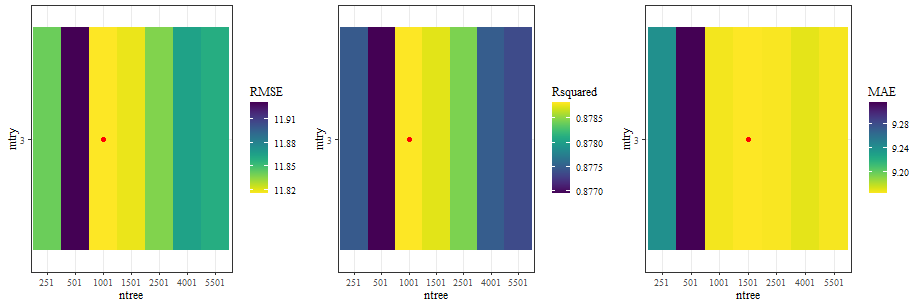

```r
p
```

Selected hyperparameters

```r
ntree <- 1001
mtry <- as.integer(length(iVars)/1.25)
```

###### Run model

Train preliminary model

```r
nperm <- 5

resultsOutImpuls <- crfReg(dataIn=stimNoticeDataANum, iVars=iVars, dVar=dVar, seeds=seeds[1:2], ntree=ntree, mtry=mtry, permImpCondThres=permImpCondThres, nperm=nperm, minsplit=minsplit, minbucket=minbucket)

# print model prediction results
resultsOutImpuls$OOB_RMSE
```

```
[1] 11.84692
```

```r
resultsOutImpuls$OOB_MAE
```

```
[1] 9.155762
```

```r
resultsOutImpuls$Rsquared
```

```
[1] 0.8777162
```

Train multiple seeds model

```r
resultsOutImpuls <- multi_crfReg(dataIn=stimNoticeDataANum, iVars=iVars, dVar=dVar, seeds=seeds, ntree=ntree, mtry=mtry, permImpCondThres=permImpCondThres, nperm=nperm, minsplit=minsplit, minbucket=minbucket)

# print model prediction results
resultsOutImpuls$OOB_RMSE
```

```
[1] 11.90005
```

```r
resultsOutImpuls$OOB_MAE
```

```
[1] 9.201872
```

```r
resultsOutImpuls$Rsquared
```

```
[1] 0.876841
```

```r
# store results
resNoticeFit['Diff impuls', 'RMSE'] <- resultsOutImpuls$OOB_RMSE
resNoticeFit['Diff impuls', 'MAE'] <- resultsOutImpuls$OOB_MAE
resNoticeFit['Diff impuls', 'Rsquared'] <- resultsOutImpuls$Rsquared
resNoticePermImp$DiffImpuls <- resultsOutImpuls$conditional_permimp
```

###### Plot results

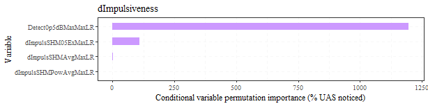

```r
par(mai=c(0,3,0,0))

# plot conditional importance
resultsOutImpuls.conimp <- arrange(resultsOutImpuls$conditional_permimp, desc(row_number()))

pBar <- ggplot(resultsOutImpuls.conimp) + geom_col(aes(x=factor(rownames(resultsOutImpuls.conimp), levels=rownames(resultsOutImpuls.conimp)), y=CondPermImp), fill=mycolours[6], width=0.5) + labs(x="Variable", y="Conditional variable permutation importance (% UAS noticed)") + ggtitle("dImpulsiveness") + theme(text = element_text(family = "serif"), panel.grid=element_line(color = rgb(235, 235, 235, 100, maxColorValue = 255), linewidth = 0.25, linetype = 2)) + coord_flip()
pBar
```

```r
if (saveplots){
  ggsave(filename="PtANoticedImpulsConPermimp.svg", width=8, height=2, path=file.path(outFigPath, "svg"))
  unlink("PtANoticedImpulsConPermimp.svg")

  ggsave(filename="PtANoticedImpulsConPermimp.pdf", width=8, height=2, path=file.path(outFigPath, "pdf"))
  unlink("PtANoticedImpulsConPermimp.pdf")
}
```

Selected metric

```r
dImpulsVar <- "dImpulsSHM05ExMaxLR"
```

#### dSQM and loudness comparison

Now the highest importance dSQMs are ranked against each other, controlling for loudness difference.

##### Include dtonal loudness

###### Set variables

```r
iVars <- c(diffVar, dSharpVar, dTonLdVar, dFluctVar, dRoughVar, dImpulsVar)
dVar <- "NoticedPcFilt"

seeds <- c(98465, 54163, 6541, 36485, 849675)
```

###### Hyperparameter tuning

```r
p <- mtryTune(dataIn=stimNoticeDataANum, iVars=iVars, dVar=dVar, seed=seeds[1:2],
             ntrees=ntrees, minsplit=minsplit, minbucket=minbucket)
```

| RMSE | Rsquared | MAE | mtry | iVars_mtry |
| --- | --- | --- | --- | --- |
| 9.520702 | 0.9253163 | 7.408812 | 3 | 1.75 |

| RMSE | Rsquared | MAE | mtry | iVars_mtry |
| --- | --- | --- | --- | --- |
| 9.441469 | 0.9263662 | 7.366779 | 3 | 1.75 |

| RMSE | Rsquared | MAE | mtry | iVars_mtry |
| --- | --- | --- | --- | --- |
| 9.470542 | 0.9261956 | 7.371422 | 3 | 1.75 |

| RMSE | Rsquared | MAE | mtry | iVars_mtry |
| --- | --- | --- | --- | --- |
| 9.489924 | 0.9261071 | 7.406331 | 3 | 1.75 |

| RMSE | Rsquared | MAE | mtry | iVars_mtry |
| --- | --- | --- | --- | --- |
| 9.479683 | 0.9258875 | 7.39763 | 3 | 1.75 |

| RMSE | Rsquared | MAE | mtry | iVars_mtry |
| --- | --- | --- | --- | --- |
| 9.446121 | 0.9264506 | 7.379534 | 3 | 1.75 |

| RMSE | Rsquared | MAE | mtry | iVars_mtry |
| --- | --- | --- | --- | --- |
| 9.454572 | 0.9262804 | 7.383996 | 3 | 1.75 |

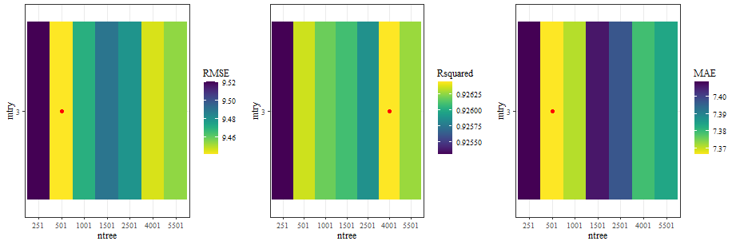

```r
p
```

Selected hyperparameters

```r
ntree <- 501
mtry <- as.integer(length(iVars)/1.75)
```

###### Run model

Train preliminary model

```r
nperm <- 5

resultsOutSQMs1 <- crfReg(dataIn=stimNoticeDataANum, iVars=iVars, dVar=dVar, seeds=seeds[1:2], ntree=ntree, mtry=mtry, permImpCondThres=permImpCondThres, nperm=nperm, minsplit=minsplit, minbucket=minbucket)

# print model prediction results
resultsOutSQMs1$OOB_RMSE
```

```
[1] 9.309124
```

```r
resultsOutSQMs1$OOB_MAE
```

```
[1] 7.313074
```

```r
resultsOutSQMs1$Rsquared
```

```
[1] 0.9293093
```

Train multiple seeds model

```r
resultsOutSQMs1 <- multi_crfReg(dataIn=stimNoticeDataANum, iVars=iVars, dVar=dVar, seeds=seeds, ntree=ntree, mtry=mtry, permImpCondThres=permImpCondThres, nperm=nperm, minsplit=minsplit, minbucket=minbucket)

# print model prediction results
resultsOutSQMs1$OOB_RMSE
```

```
[1] 9.479241
```

```r
resultsOutSQMs1$OOB_MAE
```

```
[1] 7.395973
```

```r
resultsOutSQMs1$Rsquared
```

```
[1] 0.9255489
```

```r
# store results
resNoticeFit['Diff SQMs inc tonal loud', 'RMSE'] <- resultsOutSQMs1$OOB_RMSE
resNoticeFit['Diff SQMs inc tonal loud', 'MAE'] <- resultsOutSQMs1$OOB_MAE
resNoticeFit['Diff SQMs inc tonal loud', 'Rsquared'] <- resultsOutSQMs1$Rsquared
resNoticePermImp$DiffSQMs1 <- resultsOutSQMs1$conditional_permimp
```

###### Plot results

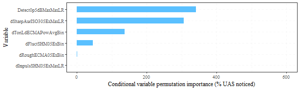

```r
par(mai=c(0,3,0,0))

# plot conditional importance
resultsOutSQMs1.conimp <- arrange(resultsOutSQMs1$conditional_permimp, desc(row_number()))

pBar <- ggplot(resultsOutSQMs1.conimp) + geom_col(aes(x=factor(rownames(resultsOutSQMs1.conimp), levels=rownames(resultsOutSQMs1.conimp)), y=CondPermImp), fill=mycolours[7], width=0.5) + labs(x="Variable", y="Conditional variable permutation importance (% UAS noticed)") + theme(text = element_text(family = "serif"), panel.grid=element_line(color = rgb(235, 235, 235, 100, maxColorValue = 255), linewidth = 0.25, linetype = 2)) + coord_flip(ylim=c(0, 600))
pBar
```

```r
if (saveplots){
  ggsave(filename="PtANoticeDiffSQMsTonLdConPermimp.svg", width=8, height=2.4, path=file.path(outFigPath, "svg"))
  unlink("PtANoticeDiffSQMsTonLdConPermimp.svg")

  ggsave(filename="PtANoticeDiffSQMsTonLdConPermimp.pdf", width=8, height=2.4, path=file.path(outFigPath, "pdf"))
  unlink("PtANoticeDiffSQMsTonLdConPermimp.pdf")
}
```

##### Exclude tonal loudness

###### Set variables

```r
iVars <- c(diffVar, dSharpVar, dTonalVar, dFluctVar, dRoughVar, dImpulsVar)
dVar <- "NoticedPcFilt"

seeds <- c(49865, 7852, 845961, 410583, 36748)
```

###### Hyperparameter tuning

```r
p <- mtryTune(dataIn=stimNoticeDataANum, iVars=iVars, dVar=dVar, seed=seeds[1:2],
             ntrees=ntrees, minsplit=minsplit, minbucket=minbucket)
```

| RMSE | Rsquared | MAE | mtry | iVars_mtry |
| --- | --- | --- | --- | --- |
| 10.23683 | 0.9143479 | 8.087541 | 3 | 1.75 |

| RMSE | Rsquared | MAE | mtry | iVars_mtry |
| --- | --- | --- | --- | --- |
| 10.1768 | 0.9154201 | 8.044603 | 3 | 1.75 |

| RMSE | Rsquared | MAE | mtry | iVars_mtry |
| --- | --- | --- | --- | --- |
| 10.14185 | 0.9160016 | 7.958116 | 3 | 1.75 |

| RMSE | Rsquared | MAE | mtry | iVars_mtry |
| --- | --- | --- | --- | --- |
| 10.16476 | 0.9159772 | 7.966222 | 3 | 1.75 |

| RMSE | Rsquared | MAE | mtry | iVars_mtry |
| --- | --- | --- | --- | --- |
| 10.19615 | 0.915178 | 7.97629 | 3 | 1.75 |

| RMSE | Rsquared | MAE | mtry | iVars_mtry |
| --- | --- | --- | --- | --- |
| 10.20332 | 0.9148321 | 7.957194 | 3 | 1.75 |

| RMSE | Rsquared | MAE | mtry | iVars_mtry |
| --- | --- | --- | --- | --- |
| 10.21228 | 0.914677 | 7.95955 | 3 | 1.75 |

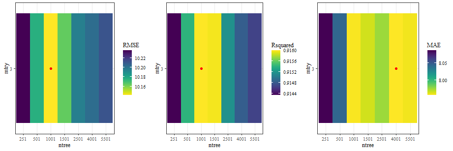

```r
p
```

Selected hyperparameters

```r
ntree <- 1001
mtry <- as.integer(length(iVars)/1.75)
```

###### Run model

Train preliminary model

```r
nperm <- 5

resultsOutSQMs2 <- crfReg(dataIn=stimNoticeDataANum, iVars=iVars, dVar=dVar, seeds=seeds[1:2], ntree=ntree, mtry=mtry, permImpCondThres=permImpCondThres, nperm=nperm, minsplit=minsplit, minbucket=minbucket)

# print model prediction results
resultsOutSQMs2$OOB_RMSE
```

```
[1] 10.30045
```

```r
resultsOutSQMs2$OOB_MAE
```

```
[1] 7.994124
```

```r
resultsOutSQMs2$Rsquared
```

```
[1] 0.9132258
```

Train multiple seeds model

```r
resultsOutSQMs2 <- multi_crfReg(dataIn=stimNoticeDataANum, iVars=iVars, dVar=dVar, seeds=seeds, ntree=ntree, mtry=mtry, permImpCondThres=permImpCondThres, nperm=nperm, minsplit=minsplit, minbucket=minbucket)

# print model prediction results
resultsOutSQMs2$OOB_RMSE
```

```
[1] 10.24627
```

```r
resultsOutSQMs2$OOB_MAE
```

```
[1] 7.939671
```

```r
resultsOutSQMs2$Rsquared
```

```
[1] 0.9139076
```

```r
# store results
resNoticeFit['Diff SQMs no tonal loud', 'RMSE'] <- resultsOutSQMs2$OOB_RMSE
resNoticeFit['Diff SQMs no tonal loud', 'RMSE'] <- resultsOutSQMs2$OOB_MAE
resNoticeFit['Diff SQMs no tonal loud', 'Rsquared'] <- resultsOutSQMs2$Rsquared
resNoticePermImp$DiffSQMs2 <- resultsOutSQMs2$conditional_permimp
```

###### Plot results

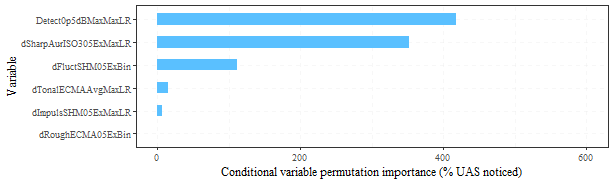

```r
par(mai=c(0,3,0,0))

# plot conditional importance
resultsOutSQMs2.conimp <- arrange(resultsOutSQMs2$conditional_permimp, desc(row_number()))

pBar <- ggplot(resultsOutSQMs2.conimp) + geom_col(aes(x=factor(rownames(resultsOutSQMs2.conimp), levels=rownames(resultsOutSQMs2.conimp)), y=CondPermImp), fill=mycolours[7], width=0.5) + labs(x="Variable", y="Conditional variable permutation importance (% UAS noticed)") + theme(text = element_text(family = "serif"), panel.grid=element_line(color = rgb(235, 235, 235, 100, maxColorValue = 255), linewidth = 0.25, linetype = 2)) + coord_flip(ylim=c(0, 600))
pBar
```

```r
if (saveplots){
  ggsave(filename="PtANoticeDiffSQMsNoTonLdConPermimp.svg", width=8, height=2.4, path=file.path(outFigPath, "svg"))
  unlink("PtANoticeDiffSQMsNoTonLdConPermimp.svg")

  ggsave(filename="PtANoticeDiffSQMsNoTonLdConPermimp.pdf", width=8, height=2.4, path=file.path(outFigPath, "pdf"))
  unlink("PtANoticeDiffSQMsNoTonLdConPermimp.pdf")
}
```

### Save the results outputs to file

```r
if (savedata){
  utils::write.csv(resNoticeFit, paste(outDataPath, "\\ptACRFNoticeOOBFit.csv", sep=""))
  ii <- 0
  temp = list()
  for (res in resNoticePermImp){
    ii <- ii + 1
    temp[[ii]] <- as.data.frame(resNoticePermImp[ii])
    names(temp[[ii]]) <- names(resNoticePermImp[ii])
  }
  openxlsx::write.xlsx(temp, paste(outDataPath, "\\ptACRFNoticeConPermimp.xlsx",
                                   sep=""),
                       rowNames=TRUE)
}
```

## Part A summary

Summary of results for Part A

### With tonal loudness

#### Absolute variables

```r
# combine the annoyance perm importance results

# convert each result to a tibble with rownames added to a column, renaming the data column to 'dAnnoy' etc.
resdAnnoyMnAbsPermImpTbl <- as.data.frame(resdAnnoyMnPermImp$AbsSQMs1/max(resdAnnoyMnPermImp$AbsSQMs1)) |>
  tibble::rownames_to_column(var='Variable')
colnames(resdAnnoyMnAbsPermImpTbl)[2] <- "dAnnoy"

resdHiAnnoyAbsPermImpTbl <- as.data.frame(resdHiAnnoyPermImp$AbsSQMs1/max(resdHiAnnoyPermImp$AbsSQMs1)) |>
  tibble::rownames_to_column(var='Variable')
colnames(resdHiAnnoyAbsPermImpTbl)[2] <- "dHiAnnoy"

resNoticeAbsPermImpTbl <- as.data.frame(resNoticePermImp$AbsSQMs1/max(resNoticePermImp$AbsSQMs1)) |>
  tibble::rownames_to_column(var='Variable')
colnames(resNoticeAbsPermImpTbl)[2] <- "dNotice"

# merge the dataframes
resAbsPermImpTbl <- list(resdAnnoyMnAbsPermImpTbl, resdHiAnnoyAbsPermImpTbl, resNoticeAbsPermImpTbl) |>
  purrr::reduce(merge, by = c('Variable'), all = T)

# rename the columns
colnames(resAbsPermImpTbl)[2:4] <- c("Mean change in annoyance", "%HA [p(HA | 0)]", "% UAS noticed")
resAbsPermImpTbl[is.na(resAbsPermImpTbl)] <- 0

resAbs <- tidyr::pivot_longer(resAbsPermImpTbl, cols=-Variable, names_to="Outcome", values_to="Imp")

# reorder res tibble, descending by the variable Imp grouped sum and create column with new group order as a factor
resAbs <- resAbs |> mutate(Variable_sum = sum(Imp), .by=Variable) |> arrange(desc(Variable_sum)) |> group_by(Variable_sum, Variable) |>
   mutate(Order = cur_group_id()) |> mutate(Order = as.factor(Order)) |> arrange(desc(Order))

# Reorder outcome levels
resAbs$Outcome <- factor(resAbs$Outcome, levels=c("Mean change in annoyance", "%HA [p(HA | 0)]", "% UAS noticed"))

# plot res as horizontal bar chart, with Imp as y axis, Variable as x axis, Outcome as fill, and Variable_sum as order, relabel x axis with Variable names
pBar <- ggplot(resAbs) + geom_col(aes(fill=Outcome, y=Imp, x=Order), colour='grey35', linewidth=0, width=0.75, show.legend=TRUE) + labs(x="Variable", y="Normalised variable permutation importance") + theme(text = element_text(family = "serif"), panel.grid=element_line(color = rgb(235, 235, 235, 100, maxColorValue = 255), linewidth = 0.25, linetype = 2), legend.position = "right") + coord_flip(ylim=c(-0.1, 2)) + scale_fill_manual(values=mycolours) + scale_x_discrete(labels=unique(rev(resAbs$Variable)))
pBar

if (saveplots){
  ggsave(filename="PtAcrfAbsSQMsSummary.svg", width=8, height=4, path=file.path(outFigPath, "svg"))
  unlink("PtAcrfAbsSQMsSummary.svg")

  ggsave(filename="PtAcrfAbsSQMsSummary.pdf", width=8, height=4, path=file.path(outFigPath, "pdf"))
  unlink("PtAcrfAbsSQMsSummary.pdf")
}
```

[output not shown]

#### Difference variables

```r
# combine the annoyance perm importance results

# convert each result to a tibble with rownames added to a column, renaming the data column to 'dAnnoy' etc.
resdAnnoyMnDiffPermImpTbl <- as.data.frame(resdAnnoyMnPermImp$DiffSQMs1/max(resdAnnoyMnPermImp$DiffSQMs1)) |>
  tibble::rownames_to_column(var='Variable')
colnames(resdAnnoyMnDiffPermImpTbl)[2] <- "dAnnoy"

resdHiAnnoyDiffPermImpTbl <- as.data.frame(resdHiAnnoyPermImp$DiffSQMs1/max(resdHiAnnoyPermImp$DiffSQMs1)) |>
  tibble::rownames_to_column(var='Variable')
colnames(resdHiAnnoyDiffPermImpTbl)[2] <- "dHiAnnoy"

resNoticeDiffPermImpTbl <- as.data.frame(resNoticePermImp$DiffSQMs1/max(resNoticePermImp$DiffSQMs1)) |>
  tibble::rownames_to_column(var='Variable')
colnames(resNoticeDiffPermImpTbl)[2] <- "dNotice"

# merge the dataframes
resDiffPermImpTbl <- list(resdAnnoyMnDiffPermImpTbl, resdHiAnnoyDiffPermImpTbl, resNoticeDiffPermImpTbl) |>
  purrr::reduce(merge, by = c('Variable'), all = T)

# rename the columns
colnames(resDiffPermImpTbl)[2:4] <- c("Mean change in annoyance", "%HA [p(HA | 0)]", "% UAS noticed")
resDiffPermImpTbl[is.na(resDiffPermImpTbl)] <- 0

resDiff <- tidyr::pivot_longer(resDiffPermImpTbl, cols=-Variable, names_to="Outcome", values_to="Imp")

# reorder res tibble, descending by the variable Imp grouped sum and create column with new group order as a factor
resDiff <- resDiff |> mutate(Variable_sum = sum(Imp), .by=Variable) |> arrange(desc(Variable_sum)) |> group_by(Variable_sum, Variable) |>
   mutate(Order = cur_group_id()) |> mutate(Order = as.factor(Order)) |> arrange(desc(Order))

# Reorder outcome levels
resDiff$Outcome <- factor(resDiff$Outcome, levels=c("Mean change in annoyance", "%HA [p(HA | 0)]", "% UAS noticed"))

# plot res as horizontal bar chart, with Imp as y axis, Variable as x axis, Outcome as fill, and Variable_sum as order, relabel x axis with Variable names
pBar <- ggplot(resDiff) + geom_col(aes(fill=Outcome, y=Imp, x=Order), colour='grey35', linewidth=0,  width=0.75, show.legend=TRUE) + labs(x="Variable", y="Normalised variable permutation importance") + theme(text = element_text(family = "serif"), panel.grid=element_line(color = rgb(235, 235, 235, 100, maxColorValue = 255), linewidth = 0.25, linetype = 2), legend.position = "right") + coord_flip(ylim=c(-0.1, 2)) + scale_fill_manual(values=mycolours) + scale_x_discrete(labels=unique(rev(resDiff$Variable)))
pBar

if (saveplots){
  ggsave(filename="PtAcrfDiffSQMsSummary.svg", width=8, height=4, path=file.path(outFigPath, "svg"))
  unlink("PtAcrfDiffSQMsSummary.svg")

  ggsave(filename="PtAcrfDiffSQMsSummary.pdf", width=8, height=4, path=file.path(outFigPath, "pdf"))
  unlink("PtAcrfDiffSQMsSummary.pdf")
}
```

[output not shown]

### No tonal loudness

#### Absolute variables

```r
# combine the annoyance perm importance results

# convert each result to a tibble with rownames added to a column, renaming the data column to 'dAnnoy' etc.
resdAnnoyMnAbsPermImpNoTonLdTbl <- as.data.frame(resdAnnoyMnPermImp$AbsSQMs2/max(resdAnnoyMnPermImp$AbsSQMs2)) |>
  tibble::rownames_to_column(var='Variable')
colnames(resdAnnoyMnAbsPermImpNoTonLdTbl)[2] <- "dAnnoy"

resdHiAnnoyAbsPermImpNoTonLdTbl <- as.data.frame(resdHiAnnoyPermImp$AbsSQMs2/max(resdHiAnnoyPermImp$AbsSQMs2)) |>
  tibble::rownames_to_column(var='Variable')
colnames(resdHiAnnoyAbsPermImpNoTonLdTbl)[2] <- "dHiAnnoy"

resNoticeAbsPermImpNoTonLdTbl <- as.data.frame(resNoticePermImp$AbsSQMs2/max(resNoticePermImp$AbsSQMs2)) |>
  tibble::rownames_to_column(var='Variable')
colnames(resNoticeAbsPermImpNoTonLdTbl)[2] <- "dNotice"

# merge the dataframes
resAbsNoTonLdPermImpNoTonLdTbl <- list(resdAnnoyMnAbsPermImpNoTonLdTbl, resdHiAnnoyAbsPermImpNoTonLdTbl, resNoticeAbsPermImpNoTonLdTbl) |>
  purrr::reduce(merge, by = c('Variable'), all = T)

# rename the columns
colnames(resAbsNoTonLdPermImpNoTonLdTbl)[2:4] <- c("Mean change in annoyance", "%HA [p(HA | 0)]", "% UAS noticed")
resAbsNoTonLdPermImpNoTonLdTbl[is.na(resAbsNoTonLdPermImpNoTonLdTbl)] <- 0

resAbsNoTonLd <- tidyr::pivot_longer(resAbsNoTonLdPermImpNoTonLdTbl, cols=-Variable, names_to="Outcome", values_to="Imp")

# reorder res tibble, descending by the variable Imp grouped sum and create column with new group order as a factor
resAbsNoTonLd <- resAbsNoTonLd |> mutate(Variable_sum = sum(Imp), .by=Variable) |> arrange(desc(Variable_sum)) |> group_by(Variable_sum, Variable) |>
   mutate(Order = cur_group_id()) |> mutate(Order = as.factor(Order)) |> arrange(desc(Order))

# Reorder outcome levels
resAbsNoTonLd$Outcome <- factor(resAbsNoTonLd$Outcome, levels=c("Mean change in annoyance", "%HA [p(HA | 0)]", "% UAS noticed"))

# plot res as horizontal bar chart, with Imp as y axis, Variable as x axis, Outcome as fill, and Variable_sum as order, relabel x axis with Variable names
pBar <- ggplot(resAbsNoTonLd) + geom_col(aes(fill=Outcome, y=Imp, x=Order), colour='grey35', linewidth=0,  width=0.75, show.legend=TRUE) + labs(x="Variable", y="Normalised variable permutation importance") + theme(text = element_text(family = "serif"), panel.grid=element_line(color = rgb(235, 235, 235, 100, maxColorValue = 255), linewidth = 0.25, linetype = 2), legend.position = "right") + coord_flip(ylim=c(-0.1, 2)) + scale_fill_manual(values=mycolours) + scale_x_discrete(labels=unique(rev(resAbsNoTonLd$Variable)))
pBar

if (saveplots){
  ggsave(filename="PtAcrfAbsSQMsNoTonLdSummary.svg", width=8, height=3.7, path=file.path(outFigPath, "svg"))
  unlink("PtAcrfAbsSQMsNoTonLdSummary.svg")

  ggsave(filename="PtAcrfAbsSQMsNoTonLdSummary.pdf", width=8, height=3.7, path=file.path(outFigPath, "pdf"))
  unlink("PtAcrfAbsSQMsNoTonLdSummary.pdf")
}
```

[output not shown]

#### Difference variables

```r
# combine the annoyance perm importance results

# convert each result to a tibble with rownames added to a column, renaming the data column to 'dAnnoy' etc.
resdAnnoyMnDiffPermImpNoTonLdTbl <- as.data.frame(resdAnnoyMnPermImp$DiffSQMs2/max(resdAnnoyMnPermImp$DiffSQMs2)) |>
  tibble::rownames_to_column(var='Variable')
colnames(resdAnnoyMnDiffPermImpNoTonLdTbl)[2] <- "dAnnoy"

resdHiAnnoyDiffPermImpNoTonLdTbl <- as.data.frame(resdHiAnnoyPermImp$DiffSQMs2/max(resdHiAnnoyPermImp$DiffSQMs2)) |>
  tibble::rownames_to_column(var='Variable')
colnames(resdHiAnnoyDiffPermImpNoTonLdTbl)[2] <- "dHiAnnoy"

resNoticeDiffPermImpNoTonLdTbl <- as.data.frame(resNoticePermImp$DiffSQMs2/max(resNoticePermImp$DiffSQMs2)) |>
  tibble::rownames_to_column(var='Variable')
colnames(resNoticeDiffPermImpNoTonLdTbl)[2] <- "dNotice"

# merge the dataframes
resDiffNoTonLdPermImpNoTonLdTbl <- list(resdAnnoyMnDiffPermImpNoTonLdTbl, resdHiAnnoyDiffPermImpNoTonLdTbl, resNoticeDiffPermImpNoTonLdTbl) |>
  purrr::reduce(merge, by = c('Variable'), all = T)

# rename the columns
colnames(resDiffNoTonLdPermImpNoTonLdTbl)[2:4] <- c("Mean change in annoyance", "%HA [p(HA | 0)]", "% UAS noticed")
resDiffNoTonLdPermImpNoTonLdTbl[is.na(resDiffNoTonLdPermImpNoTonLdTbl)] <- 0

resDiffNoTonLd <- tidyr::pivot_longer(resDiffNoTonLdPermImpNoTonLdTbl, cols=-Variable, names_to="Outcome", values_to="Imp")

# reorder res tibble, descending by the variable Imp grouped sum and create column with new group order as a factor
resDiffNoTonLd <- resDiffNoTonLd |> mutate(Variable_sum = sum(Imp), .by=Variable) |> arrange(desc(Variable_sum)) |> group_by(Variable_sum, Variable) |>
   mutate(Order = cur_group_id()) |> mutate(Order = as.factor(Order)) |> arrange(desc(Order))

# Reorder outcome levels
resDiffNoTonLd$Outcome <- factor(resDiffNoTonLd$Outcome, levels=c("Mean change in annoyance", "%HA [p(HA | 0)]", "% UAS noticed"))

# plot res as horizontal bar chart, with Imp as y axis, Variable as x axis, Outcome as fill, and Variable_sum as order, relabel x axis with Variable names
pBar <- ggplot(resDiffNoTonLd) + geom_col(aes(fill=Outcome, y=Imp, x=Order), colour='grey35', linewidth=0,  width=0.75, show.legend=TRUE) + labs(x="Variable", y="Normalised variable permutation importance") + theme(text = element_text(family = "serif"), panel.grid=element_line(color = rgb(235, 235, 235, 100, maxColorValue = 255), linewidth = 0.25, linetype = 2), legend.position = "right") + coord_flip(ylim=c(-0.1, 2)) + scale_fill_manual(values=mycolours) + scale_x_discrete(labels=unique(rev(resDiffNoTonLd$Variable)))
pBar

if (saveplots){
  ggsave(filename="PtAcrfDiffSQMsNoTonLdSummary.svg", width=8, height=4, path=file.path(outFigPath, "svg"))
  unlink("PtAcrfDiffSQMsNoTonLdSummary.svg")

  ggsave(filename="PtAcrfDiffSQMsNoTonLdSummary.pdf", width=8, height=4, path=file.path(outFigPath, "pdf"))
  unlink("PtAcrfDiffSQMsNoTonLdSummary.pdf")
}
```

[output not shown]

### Save the results outputs to file

```r
# Make a list of the summary results
resSummary <- list(resAbs, resDiff, resAbsNoTonLd, resDiffNoTonLd)

# Save the results
if (savedata){
  ii <- 0
  temp = list()
  for (res in resSummary){
    ii <- ii + 1
    temp[[ii]] <- data.frame(resSummary[ii])
  }
  openxlsx::write.xlsx(temp, paste(outDataPath, "\\ptACRFSummary.xlsx",
                                   sep=""),
                       rowNames=TRUE)
}
```